# Airline Customer Satisfaction - Group 17

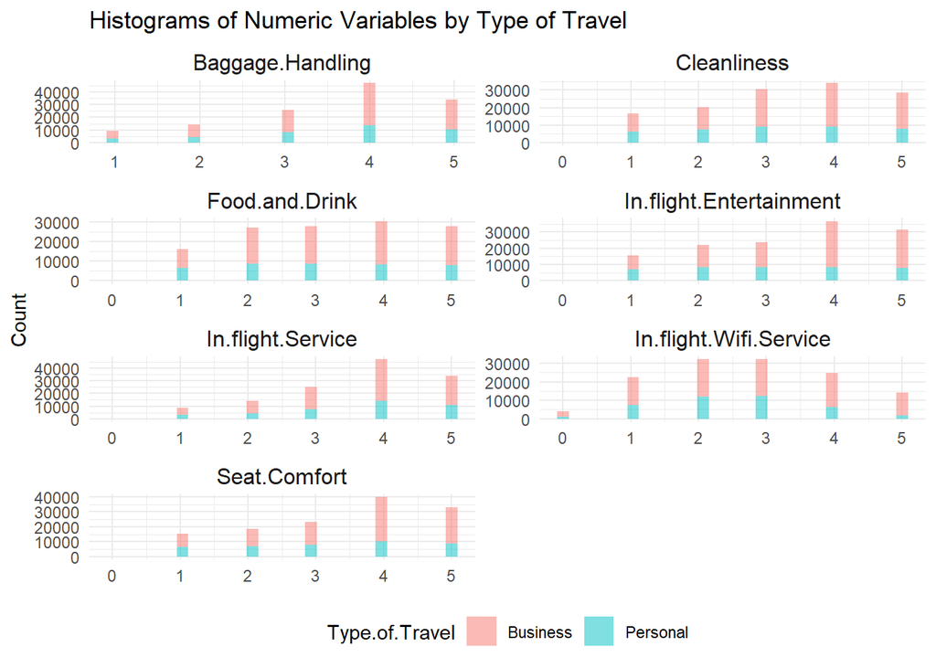

```r
data_subset <- data %>%
  select(Type.of.Travel, Seat.Comfort, In.flight.Service, Baggage.Handling,
         In.flight.Entertainment, In.flight.Wifi.Service, Food.and.Drink, Cleanliness)

# Convert to long format
data_long <- pivot_longer(data_subset, -Type.of.Travel, names_to = "Variable", values_to = "Value")

# Create faceted histogram
ggplot(data_long, aes(x = Value, fill = Type.of.Travel)) +
  geom_histogram(position = "stack", alpha = 0.5, bins = 30) +
  facet_wrap(~ Variable, scales = "free", ncol = 2) +
  theme_minimal() +
  labs(title = "Histograms of Numeric Variables by Type of Travel",
       x = NULL, y = "Count") +
  theme(
    strip.text = element_text(size = 12),
    legend.position = "bottom"
  )
```

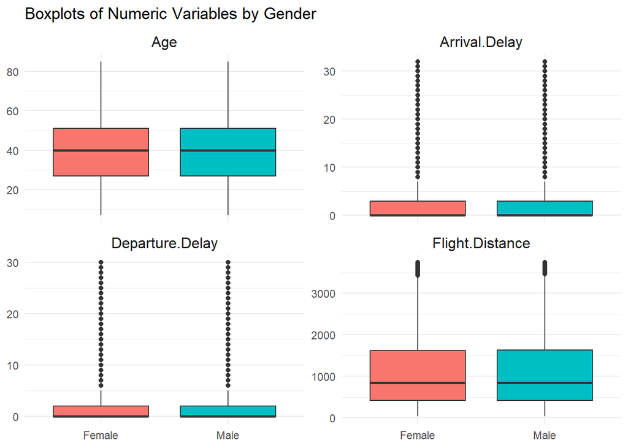

```r
data_subset <- data %>%
  select(Gender, Age, Flight.Distance, Departure.Delay,
         Arrival.Delay)

# Convert to long format for faceting
data_long <- pivot_longer(data_subset, -Gender, names_to = "Variable", values_to = "Value")

# Plot boxplots with facets
ggplot(data_long, aes(x = Gender, y = Value, fill = Gender)) +
  geom_boxplot() +
  facet_wrap(~ Variable, scales = "free_y") +
  theme_minimal() +
  labs(title = "Boxplots of Numeric Variables by Gender",
       x = NULL, y = NULL) +
  theme(
    strip.text = element_text(size = 12),
    legend.position = "none"
  )
```

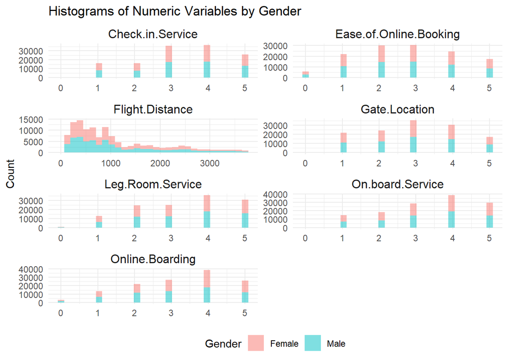

```r
data_subset <- data %>%
  select(Gender, Ease.of.Online.Booking, Check.in.Service, Online.Boarding,
         Gate.Location, On.board.Service, Leg.Room.Service, Flight.Distance)

# Convert to long format
data_long <- pivot_longer(data_subset, -Gender, names_to = "Variable", values_to = "Value")

# Create faceted histogram
ggplot(data_long, aes(x = Value, fill = Gender)) +
  geom_histogram(position = "stack", alpha = 0.5, bins = 30) +
  facet_wrap(~ Variable, scales = "free", ncol = 2) +
  theme_minimal() +
  labs(title = "Histograms of Numeric Variables by Gender",
       x = NULL, y = "Count") +
  theme(
    strip.text = element_text(size = 12),
    legend.position = "bottom"
  )
```

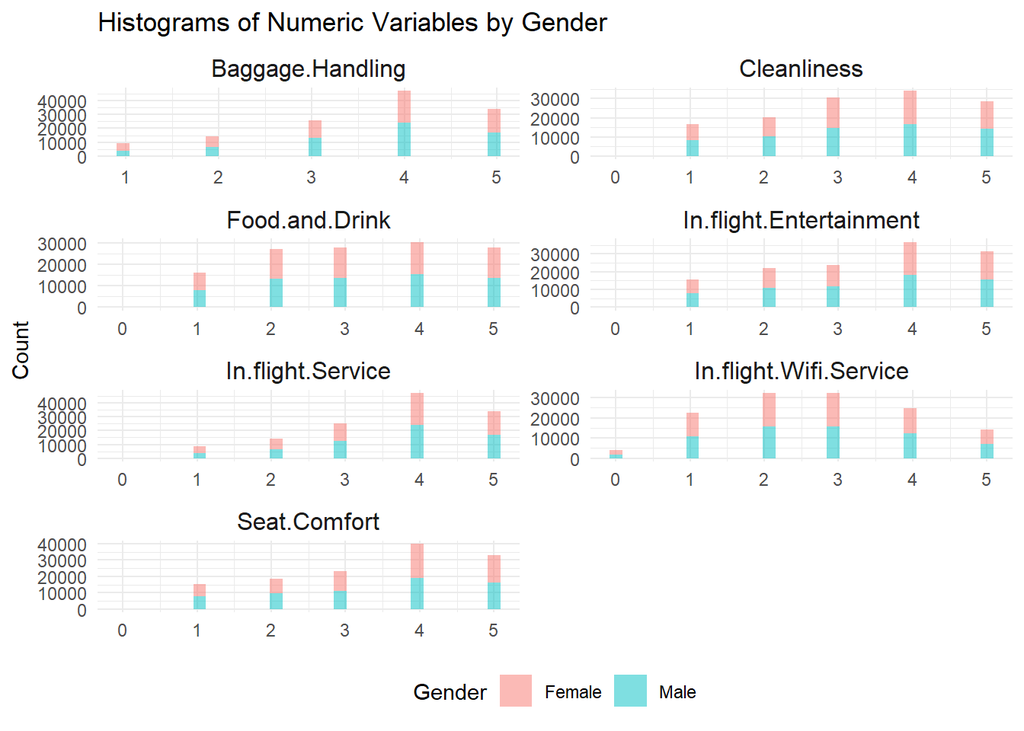

```r
data_subset <- data %>%
  select(Gender, Seat.Comfort, In.flight.Service, Baggage.Handling,
         In.flight.Entertainment, In.flight.Wifi.Service, Food.and.Drink, Cleanliness)

# Convert to long format
data_long <- pivot_longer(data_subset, -Gender, names_to = "Variable", values_to = "Value")

# Create faceted histogram
ggplot(data_long, aes(x = Value, fill = Gender)) +
  geom_histogram(position = "stack", alpha = 0.5, bins = 30) +
  facet_wrap(~ Variable, scales = "free", ncol = 2) +
  theme_minimal() +
  labs(title = "Histograms of Numeric Variables by Gender",
       x = NULL, y = "Count") +
  theme(
    strip.text = element_text(size = 12),
    legend.position = "bottom"
  )
```

The histograms illustrate the distribution of ratings for various airline service attributes (Baggage Handling, Cleanliness, Food and Drink, In-flight Entertainment, In-flight Service, In-flight WiFi Service, and Seat Comfort) segmented by gender (Female and Male). Across most categories, ratings of 4 and 5 are predominant, indicating overall positive feedback. Both genders exhibit similar patterns in their evaluations, with slight variations in proportions. For example, females appear to rate slightly higher in categories like In-flight Entertainment and Cleanliness compared to males. Conversely, males seem to have a marginally higher count in lower ratings (1–3) for some categories like Seat Comfort and In-flight WiFi Service. This suggests gender-based nuances in satisfaction levels but overall consistency in favoring higher ratings across services

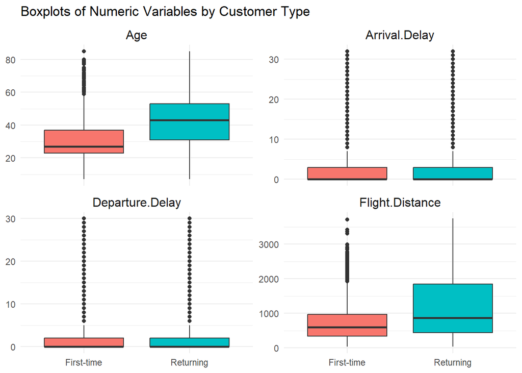

```r
data_subset <- data %>%
  select(Customer.Type, Age, Flight.Distance, Departure.Delay,
         Arrival.Delay)

# Convert to long format for faceting
data_long <- pivot_longer(data_subset, -Customer.Type, names_to = "Variable", values_to = "Value")

# Plot boxplots with facets
ggplot(data_long, aes(x = Customer.Type, y = Value, fill = Customer.Type)) +
  geom_boxplot() +
  facet_wrap(~ Variable, scales = "free_y") +
  theme_minimal() +
  labs(title = "Boxplots of Numeric Variables by Customer Type",
       x = NULL, y = NULL) +
  theme(
    strip.text = element_text(size = 12),
    legend.position = "none"
  )
```

The boxplots compare numeric variables (Age, Arrival Delay, Departure Delay, and Flight Distance) between two customer types: First-time and Returning. For Age, returning customers tend to be older, with a higher median and wider range compared to first-time customers. Arrival Delay and Departure Delay show similar distributions for both groups, with most values concentrated around zero and a significant number of outliers indicating occasional long delays. For Flight Distance, returning customers generally travel longer distances, as evidenced by a higher median and greater variability compared to first-time customers. Overall, returning customers exhibit distinct patterns in age and flight distance, while delays are similarly distributed across both groups.

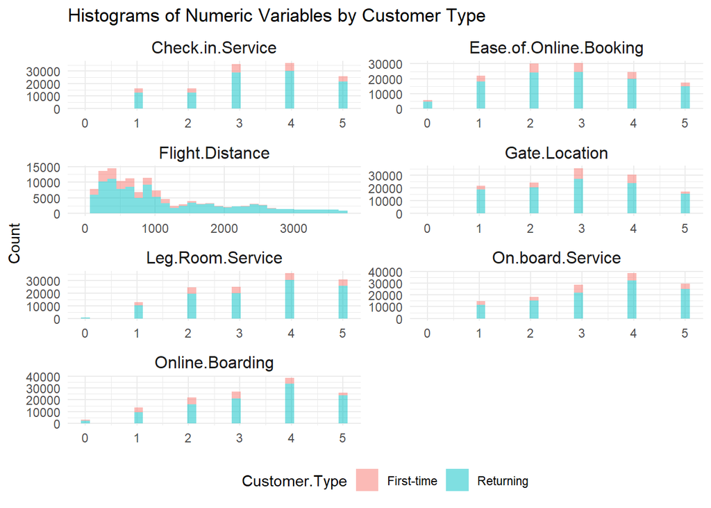

```r
data_subset <- data %>%
  select(Customer.Type, Ease.of.Online.Booking, Check.in.Service, Online.Boarding,
         Gate.Location, On.board.Service, Leg.Room.Service, Flight.Distance)

# Convert to long format
data_long <- pivot_longer(data_subset, -Customer.Type, names_to = "Variable", values_to = "Value")

# Create faceted histogram
ggplot(data_long, aes(x = Value, fill = Customer.Type)) +
  geom_histogram(position = "stack", alpha = 0.5, bins = 30) +
  facet_wrap(~ Variable, scales = "free", ncol = 2) +
  theme_minimal() +
  labs(title = "Histograms of Numeric Variables by Customer Type",
       x = NULL, y = "Count") +
  theme(
    strip.text = element_text(size = 12),
    legend.position = "bottom"
  )
```

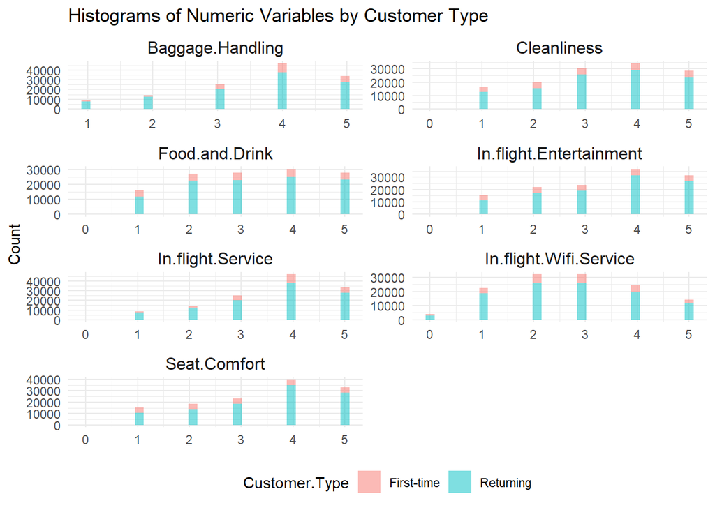

```r
data_subset <- data %>%
  select(Customer.Type, Seat.Comfort, In.flight.Service, Baggage.Handling,
         In.flight.Entertainment, In.flight.Wifi.Service, Food.and.Drink, Cleanliness)

# Convert to long format
data_long <- pivot_longer(data_subset, -Customer.Type, names_to = "Variable", values_to = "Value")

# Create faceted histogram
ggplot(data_long, aes(x = Value, fill = Customer.Type)) +
  geom_histogram(position = "stack", alpha = 0.5, bins = 30) +
  facet_wrap(~ Variable, scales = "free", ncol = 2) +
  theme_minimal() +
  labs(title = "Histograms of Numeric Variables by Customer Type",
       x = NULL, y = "Count") +
  theme(
    strip.text = element_text(size = 12),
    legend.position = "bottom"
  )
```

### 2.2.4 Association Between Two Categorical Variable

Recalling the Univariate Data Analysis, we will use five categories or variables that we deemed important as the base for further analysis, specifically to see the association between two categorical variables. These variables are distribution of gender, customer type, type of travel, class, and the disparity of numbers between satisfacted and unsatisfied passengers.

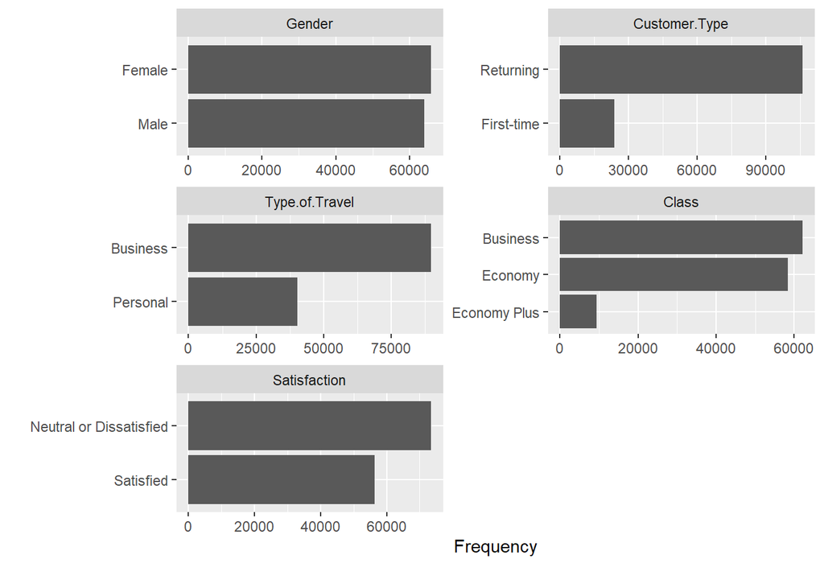

```r
plot_bar(data,ncol=2)
```

We will use the plot_bar function to visualize the association between these variables. For each of the following five sections, we take out one of the category and plot the association between each of the remaining four categories with the missing category. We start with creating the association between customer’s satisfaction with the other four variables.

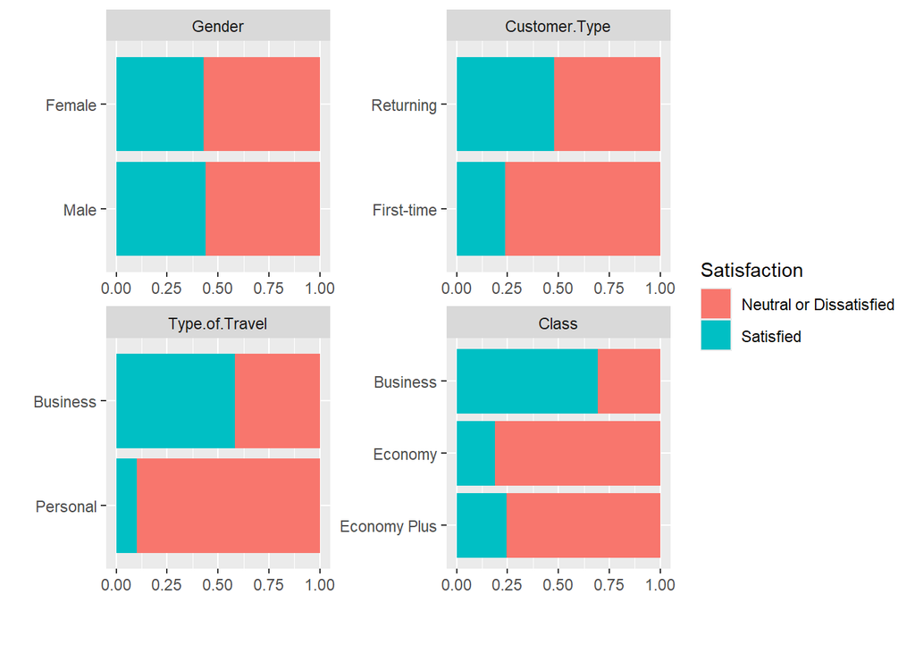

```r
plot_bar(data,by='Satisfaction',ncol=2)
```

From the univariate data distribution, we already know the numbers of satisfied and unsatisfied passengers is not equal with noticeable difference, with the majority of passengers being unsatisfied. So it is not surprising that regardless of the association between passengers’ satisfaction with other categories, most graphs are showing the skew towards the neutral or dissatisfied category.

However, it could be noticed that the distribution of satisfaction level across both genders are relatively equal, while the first time flyers are more likely to be unsatisfied rather than the frequent travelers. Business travelers also tend to be more satisfied than the economy class passengers. This is also the case for the business class passengers. We will see in the other section that passengers with business intention are more likely to fly on business class, so the correlation is consistent in the satisfaction level as well. This is understandable, since airlines with business class are more likely to have extra services and better quality of basic services, which means that it is more likely to satisfy the passengers. Based on this information, the focus on improving the satisfaction rate of passengers should be on the economy class passengers with leisure intention, especially those who are first time flyers.

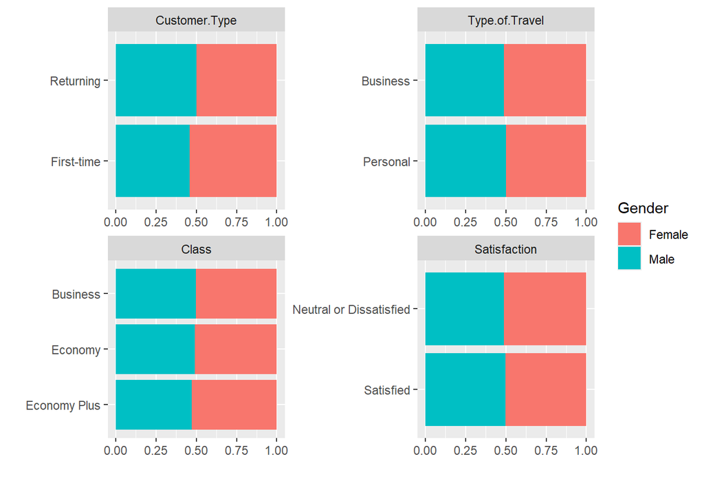

```r
plot_bar(data,by='Gender',ncol=2)
```

In this section, we show the distribution of genders in four other categories, which is relatively balanced across all graphs. Hence, we can conclude that genders are not the deciding factor that we need to analyze further in the data analysis section, meaning that it is not important enough as a consideration point to improve the satisfaction rate.

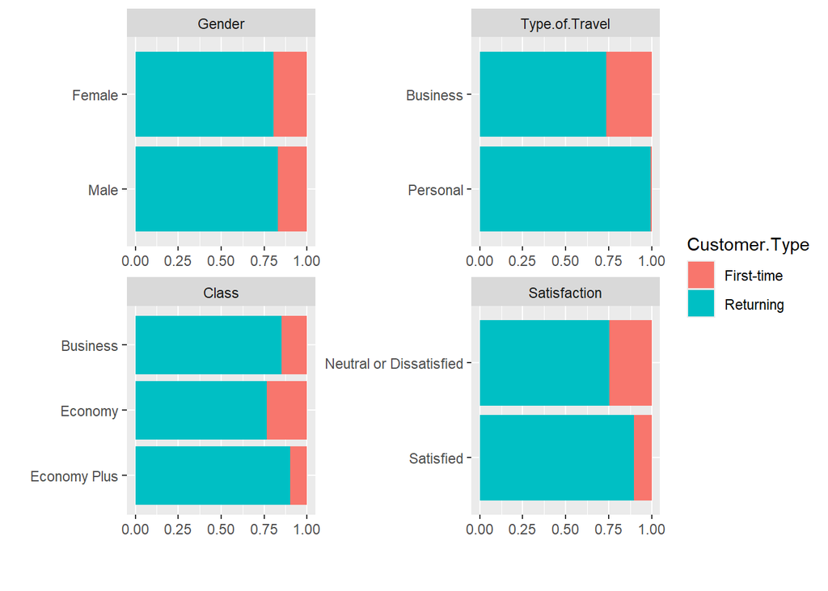

```r
plot_bar(data,by='Customer.Type',ncol=2)
```

From the customer type distribution and association graphs, it can be noticed that the majority of first time passengers are flying economy class, and also more likely to have the less-favorable first imnpression towards their flying experience, which can be seen in its relation with satisfaction level.

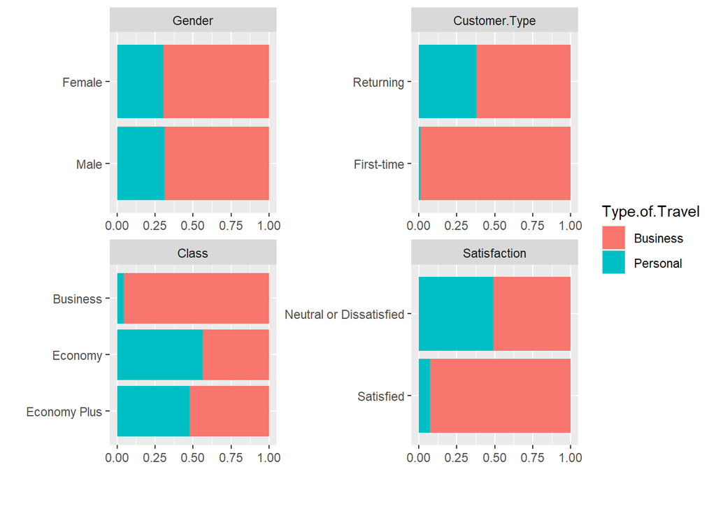

```r
plot_bar(data,by='Type.of.Travel',ncol=2)
```

As we can see above, the majority of business travelers fly on the business class as well, and they are also more likely to be satisfied with their flying experience. This is consistent with our observation and discussion on the previous section. On the opposite, travelers with personal reason, such as leisure, are more likely to fly on both of the economy classes and also less likely to be satisfied with their flying experience.

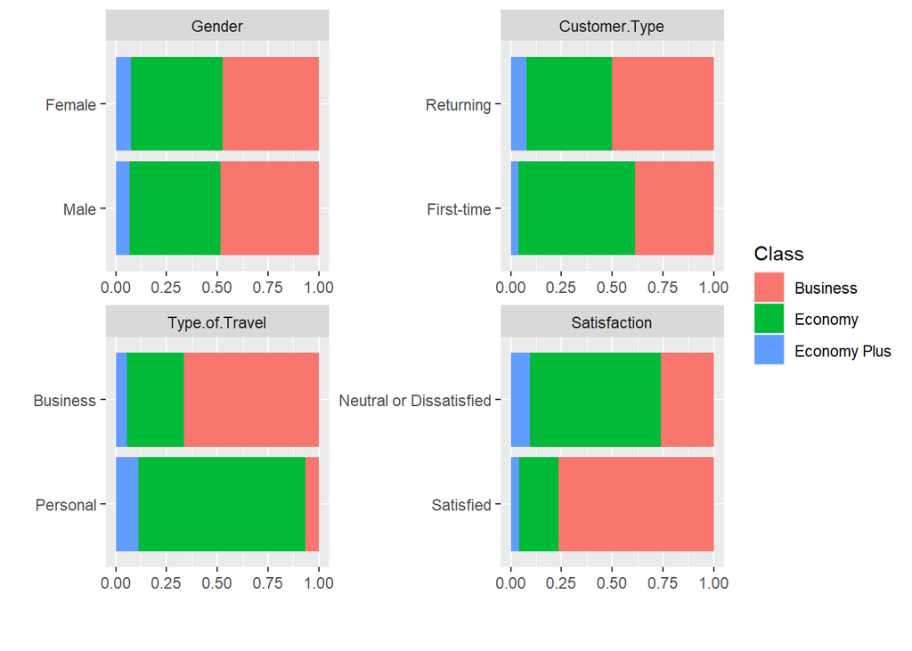

```r
plot_bar(data,by='Class',ncol=2)
```

## 2.3 Feature Engineering

We noticed that the age distribution have high variation, therefore we try to create the age_group column to divide the age group into four categories: children, youth, adult, and senior. This categorization is based on most of the division range used in a lot of transportation services across the world. The age group is defined and plotted in R as follows:

```r
data = data %>% mutate(Age_Range = if_else(Age <= 15,"Children",
if_else(16 <= Age & Age <= 25,"Youth",
if_else(26 < Age & Age <= 60,"Adult","Senior"))))
```

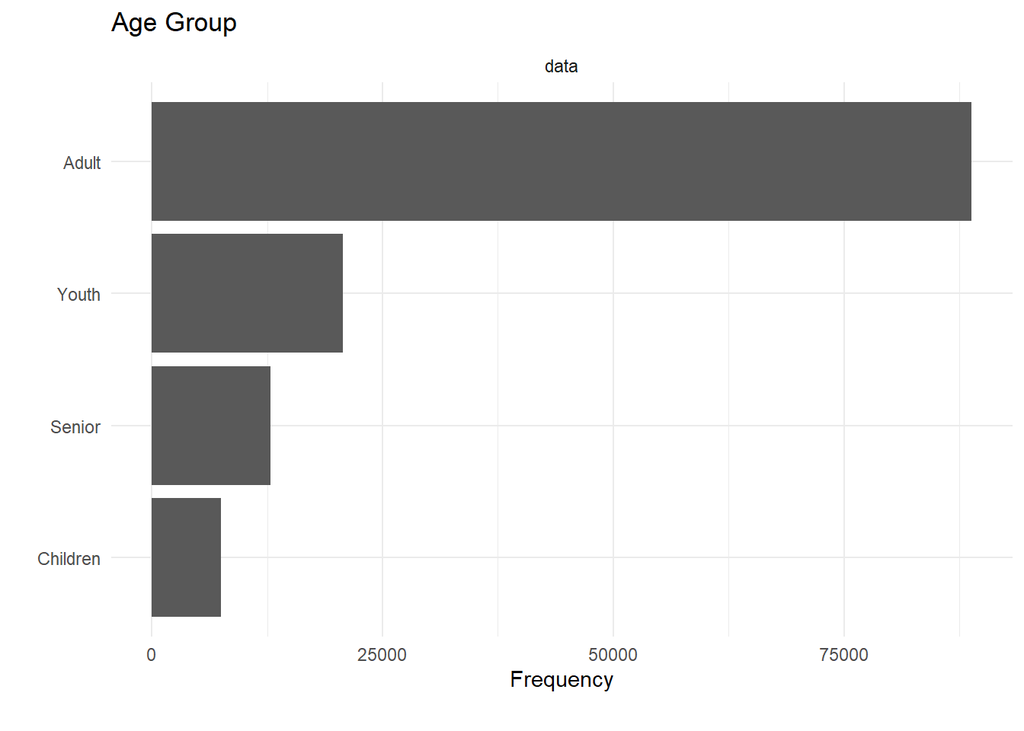

```r
plot_bar(data$Age_Range,ncol=2,order_bar=T,ggtheme = theme_minimal(), title = "Age Group")
```

Now we can interpret from the age group that the largest segment of our customer is belong to adult age group. This is understandable since the adult group has the widest range of age compared to other age groups.

Another data we can group is the flight distance which currently right skewed. We will create new variables of flight distance by grouping them into three categories: short-haul, medium-haul, and long-haul. The division of distance is based on the limit defined by David W. Wragg in his book A Dictionary of Aviation:

**Short-haul Flights**: 0 - 900 miles (0 - 1,450 km)

**Medium-haul Flights**: 900 - 2,200 miles (1,450 - 3,540 km)

**Long-haul Flights**: 2,200 miles (3,540 km) and above

```r
data = data %>% mutate(Distance_Group = if_else(Flight.Distance < 900,"Short-haul",
if_else(900 <= Flight.Distance & Flight.Distance <= 2200,"Medium-haul","Long-haul")))
```

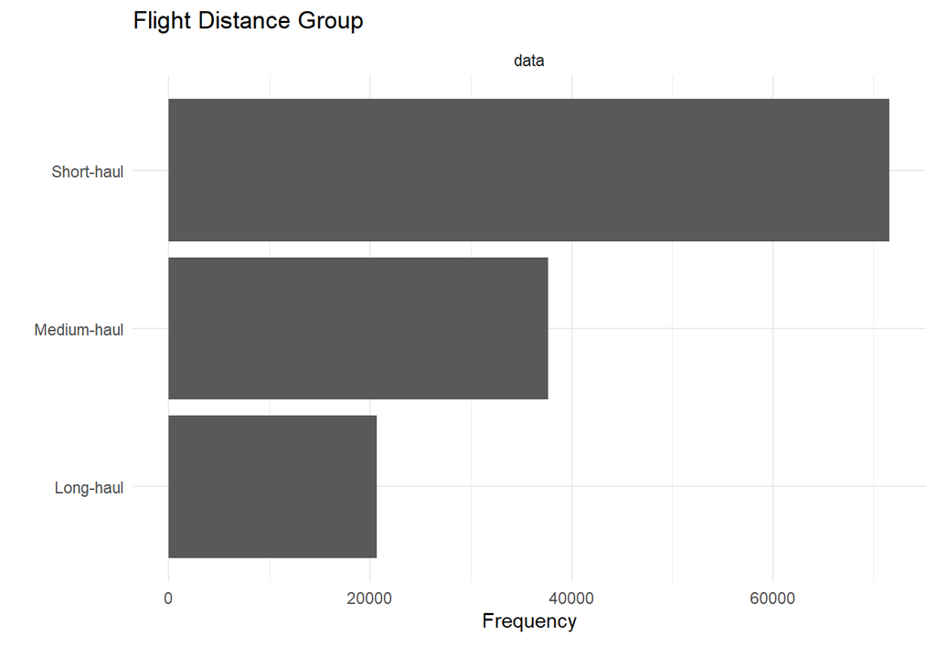

```r
plot_bar(data$Distance_Group, ncol = 2, order_bar = TRUE, ggtheme = theme_minimal(), title = "Flight Distance Group")
```

We can divide which customer experiencing delay or not based on departure delay and arrival delay. United States’ Federal Aviation Administration (FAA) defines a flight as delayed if it is 15 minutes or more behind schedule. We can use the following code to create the new variables to show the comparison of the numbers of flight with departure delay and arrival delay.

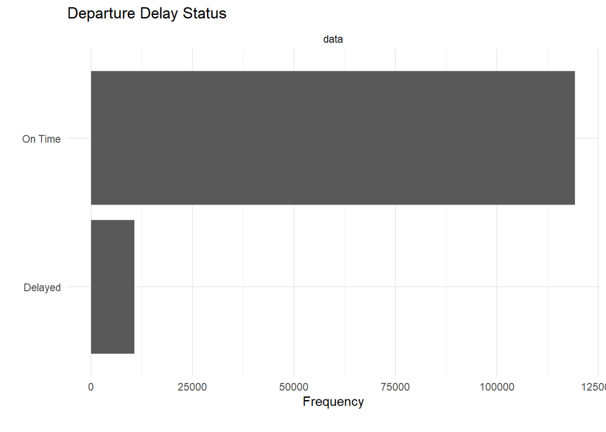

```r
data$departure.delay.status = ifelse(data$Departure.Delay > 15, "Delayed", "On Time")
data$arrival.delay.status = ifelse(data$Arrival.Delay > 15, "Delayed", "On Time")

plot_bar(data$departure.delay.status,ncol=2,order_bar=T,ggtheme = theme_minimal(), title = "Departure Delay Status")
```

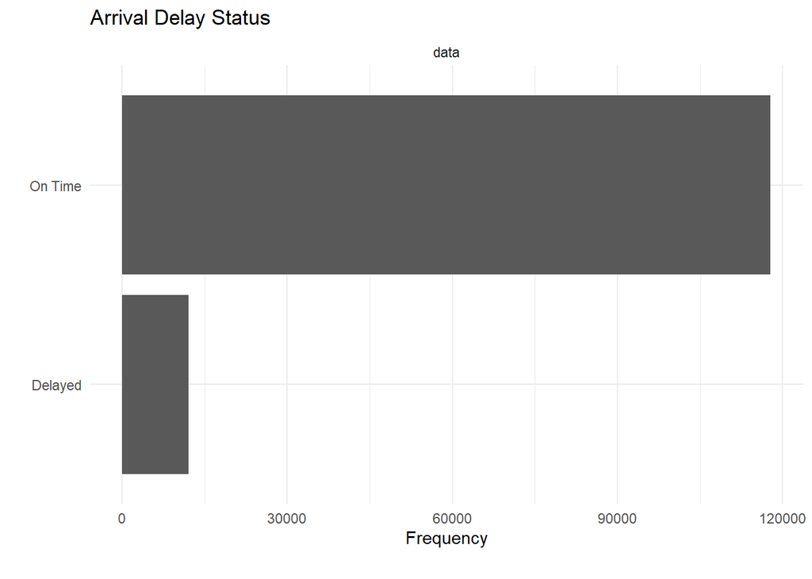

```r
plot_bar(data$arrival.delay.status,ncol=2,order_bar=T,ggtheme = theme_minimal(), title = "Arrival Delay Status")
```

Because both departure and arrival delay status are equally important, we can combine them into one variable called **delay.status** with OR operator is used to display the total number of delayed flights.

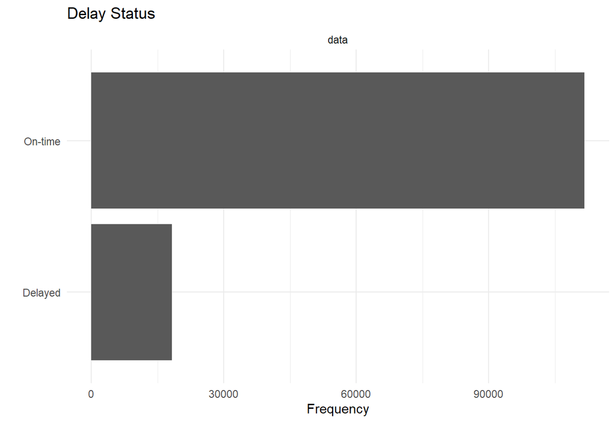

```r
data$delay.status = ifelse(data$Departure.Delay > 15 | data$Arrival.Delay > 15, "Delayed", "On-time")

plot_bar(data$delay.status,ncol=2,order_bar=T,ggtheme = theme_minimal(), title = "Delay Status")
```

Next, We group the features into category of services that could be improved by the airline:

- **Flight General Service:** On-board Service, Food and Drink, In-flight Service
- **Flight Entertainment:** In Flight Wifi Service, In Flight Entertainment
- **Pre-flight Service:** Ease of Online Booking, Check-in Service, Online Boarding
- **Comfortability:** Seat Comfort, Leg Room Service, Cleanliness

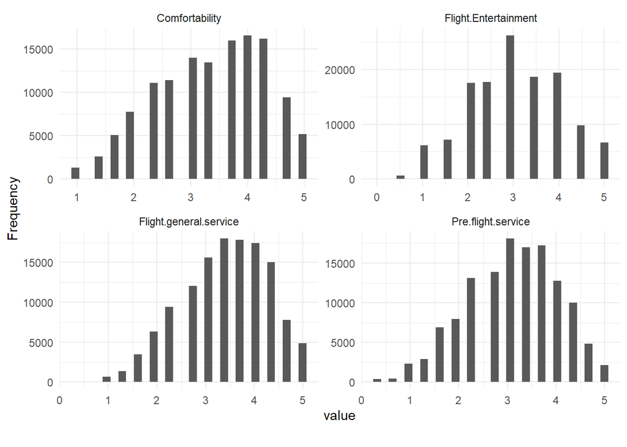

```r
# Create features group with maximum score of 5
data$Flight.general.service = rowSums(data[,c('On.board.Service','Food.and.Drink','In.flight.Service')],na.rm = TRUE)/3
data$Flight.Entertainment = rowSums(data[,c('In.flight.Wifi.Service','In.flight.Entertainment')],na.rm = TRUE)/2
data$Pre.flight.service = rowSums(data[,c('Ease.of.Online.Booking','Check.in.Service','Online.Boarding')],na.rm = TRUE)/3
data$Comfortability = rowSums(data[,c('Seat.Comfort','Leg.Room.Service','Cleanliness')],na.rm = TRUE)/3

plot_histogram(data[ , c("Flight.general.service", "Flight.Entertainment", "Pre.flight.service", "Comfortability")], ncol=2,ggtheme = theme_minimal())
```

Combining several category of services into one variable is useful to see the overall satisfaction of the airline services in numerous area of improvement. For example, as we can see above that in general the passengers found that the flights they are taking are relatively comfortable. However, the pre-flight service and flight entertainment category received mixed reviews and can be considered as an improvement area for the airline, where further analysis could be done to see which of the element of those services are the most dissatisfying for the passengers.

## 2.4 Data Transformation

Data transformation plays a key role to make sure all data is in the same scale and distribution. We will start to take a look on our data distribution.

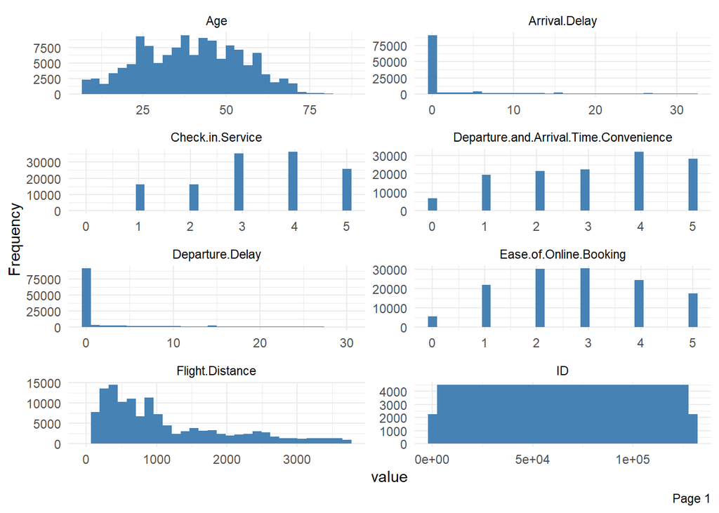

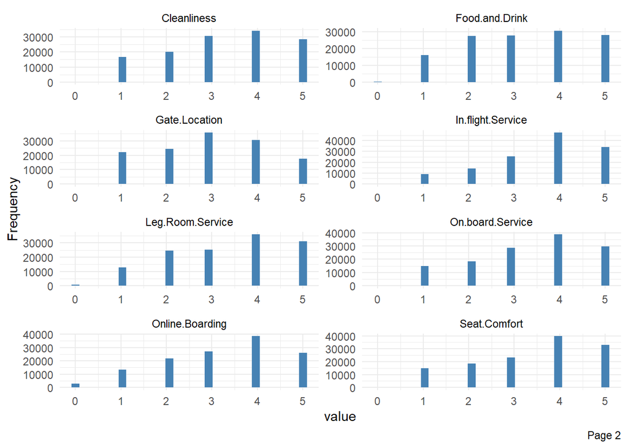

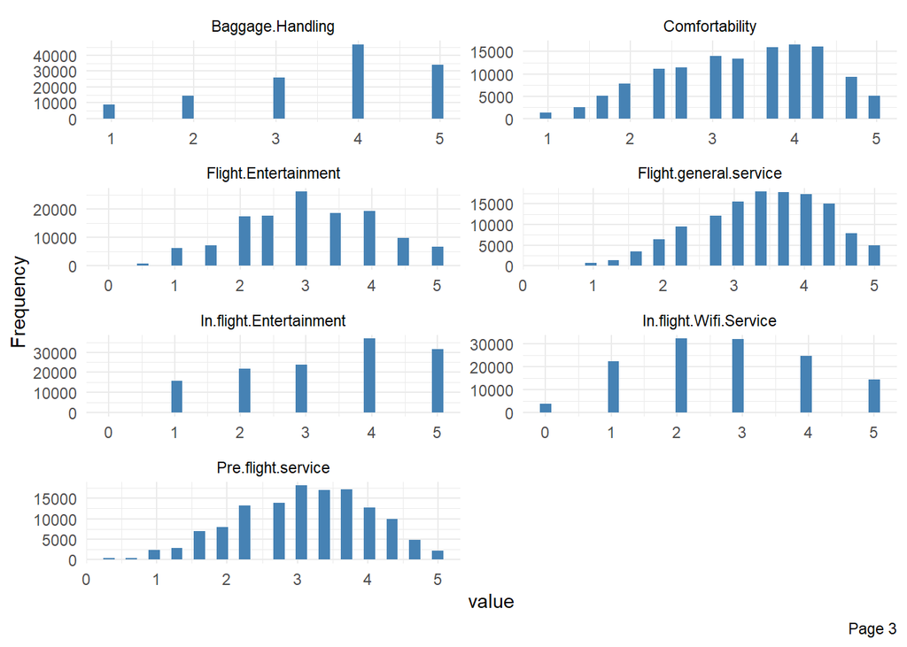

```r
# Set default colors for histogram bars
update_geom_defaults("bar", list(fill = "steelblue", color = NA))

# Generate histogram with updated colors
plot_histogram(data,
               ncol = 2,
               ggtheme = theme_minimal() + theme(strip.background = element_blank(),
                                                 strip.text = element_text(color = "black")))
```

This part is to undertand the distribution of data before it is used. As we can see in the histogram, the data is not normally distributed. Therefore, we need to normalize the data. There are several concerning variables in the dataset that are part of main focus in the data transformation process.

In the following step we will normalize the data by applying log transformation to the concerning variables.

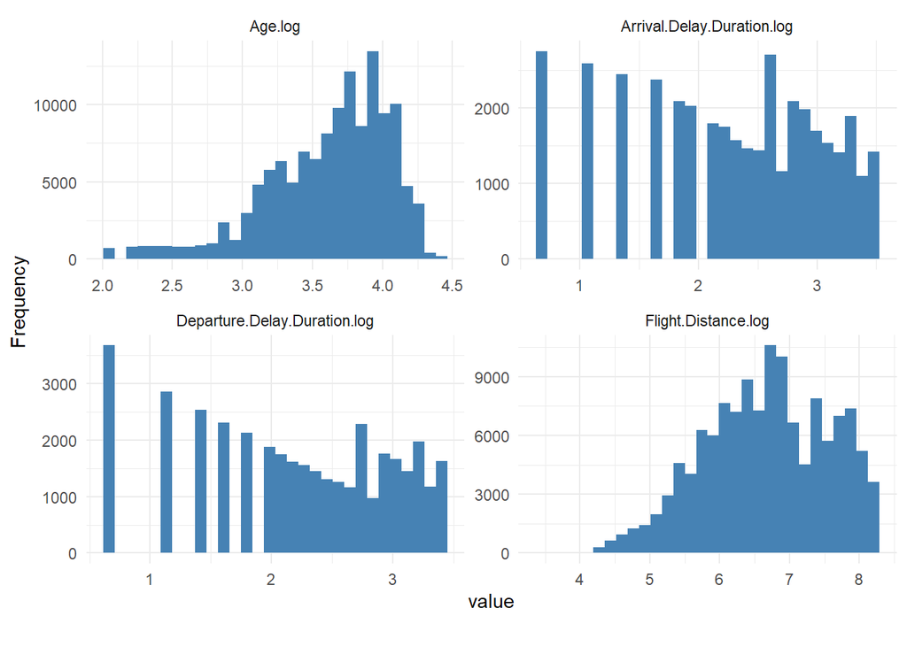

```r
# Create new variables for departure and arrival delay duration
data$Departure.Delay.Duration = ifelse(data$Departure.Delay > 0, data$Departure.Delay, NA)
data$Arrival.Delay.Duration = ifelse(data$Arrival.Delay > 0, data$Arrival.Delay, NA)

# Apply log transformation to the variables
data$Flight.Distance.log = log(1 + data$Flight.Distance)
data$Age.log = log(1 + data$Age)
data$Departure.Delay.Duration.log = log(1 + data$Departure.Delay.Duration)
data$Arrival.Delay.Duration.log = log(1 + data$Arrival.Delay.Duration)

# Plot histograms of the log-transformed variables
plot_histogram(data[, c("Flight.Distance.log", "Age.log", "Departure.Delay.Duration.log", "Arrival.Delay.Duration.log")], ncol=2,ggtheme = theme_minimal())
```

Data transformation is performed with visualization task to see the distribution of the data after the transformation. This aims to normalize skewed distribution.

- **arrival.delays** and **departure.delays** are transformed into log scale to address the skewed issues.
- **flight.distance** and **age** are also transformed into log scale to address the skewed issues.

After log-transormation, normalize the distribution is then performed as follow.

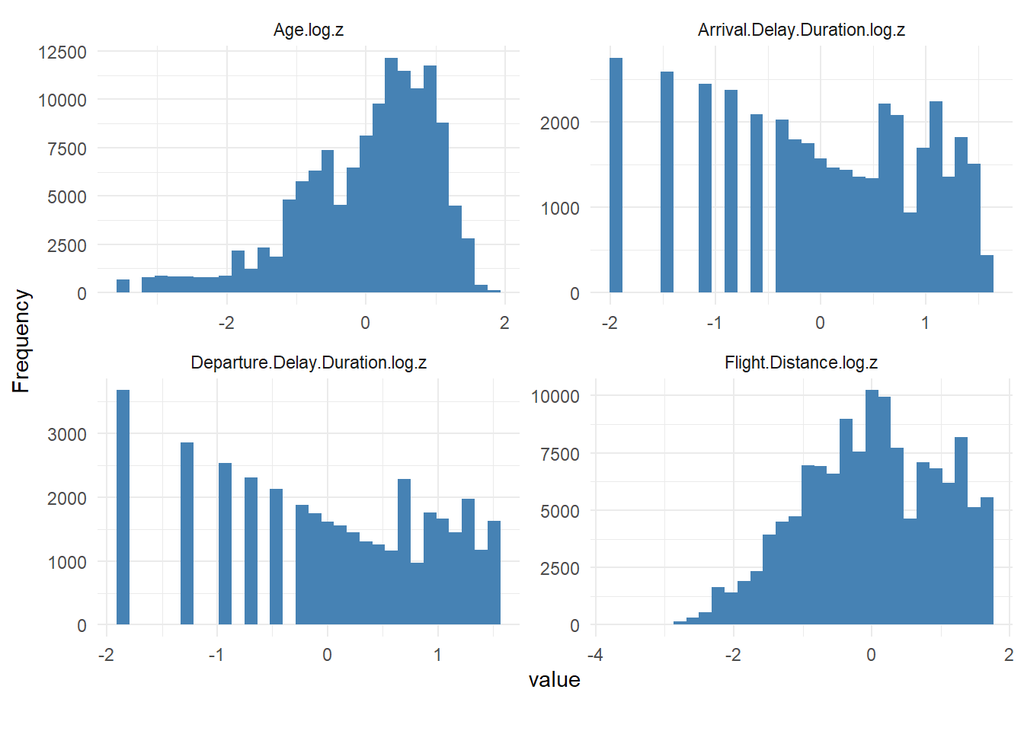

```r
# Normalize the log-transformed variables
data$Flight.Distance.log.z = scale(data$Flight.Distance.log)
data$Age.log.z = scale(data$Age.log)
data$Departure.Delay.Duration.log.z = scale(data$Departure.Delay.Duration.log)
data$Arrival.Delay.Duration.log.z = scale(data$Arrival.Delay.Duration.log)

# Plot histograms of the normalized variables
plot_histogram(data[, c("Flight.Distance.log.z", "Age.log.z", "Departure.Delay.Duration.log.z", "Arrival.Delay.Duration.log.z")], ncol=2,ggtheme = theme_minimal())
```

As we can see in the histogram, the data is now normalized with 0 as the center. This is important to ensure that the data is on the same scale and distribution. This helps the model learn the data better and make better predictions.

Here are the reasons why performing normalization is important before using the data:

1. **Comparison Across Variables**  
   Normalization ensures the data is on the same scale. This helps in making the model comparable and supports easier further analysis.
2. **Improved Model Performance**  
   Many algorithms perform better when input variables are standardized, as it prevents variables with larger ranges from dominating the analysis.
3. **Normalization Beyond Log Transformation**  
   While log transformation reduces skewness and normalizes distributions, scaling ensures uniformity across variables, enabling fair use in statistical techniques.

## 2.5 Initial Plotting

Our target is the satisfaction rate of the airlines services, therefore we need to identify how each variable are correlated to the satisfaction. This is important to understand how each variable’s behavior toward main objective of the analysis. Following is the behavior of each variables towards satisfaction rate.

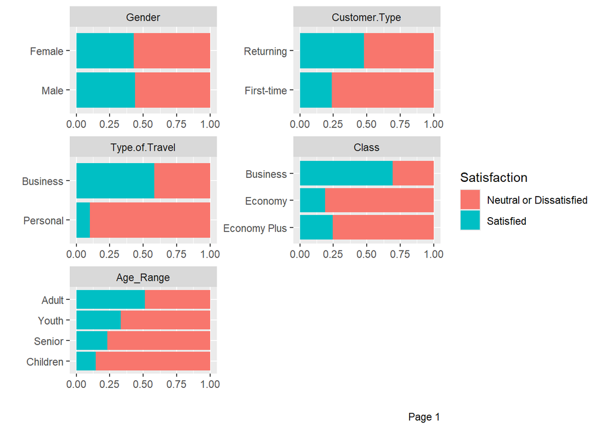

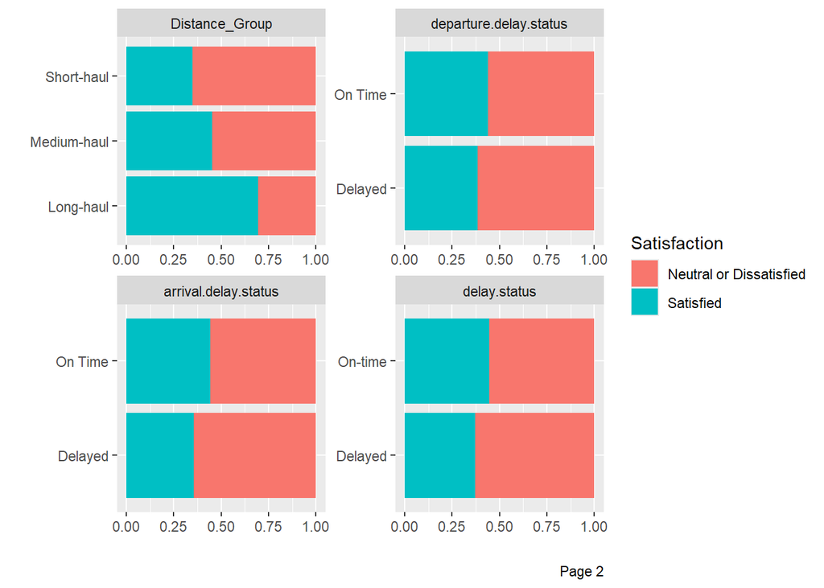

```r
plot_bar(data,by='Satisfaction',ncol=2)
```

According to the graphic above, we can see that:

- **Gender**: Both male and female customers have a higher proportion of “Neutral or Dissatisfied” responses compared to “Satisfied” ones. This indicates there is a room of improvement to increase satisfied number
- **Customer Type**: Returning customers exhibit a higher proportion of “Satisfied” responses than first-time customers, who seem mostly “Neutral or Dissatisfied”. This might indicate that familiarity with the company positively influences satisfaction.
- **Type of Travel**: Business travelers show a higher proportion of “Satisfied” responses compared to personal travelers.
- **Class**: Business class has the highest proportion of “Satisfied” responses, whereas Economy and Economy Plus lean more towards “Neutral or Dissatisfied.” This indicates higher satisfaction among premium customers.
- **Age Range**: Adult and youth customers show higher satisfaction levels compared to senior and children, who lean towards dissatisfaction.
- **Distance Group**: Long Haul seem to lead to higher satisfaction levels compared to short haul and medium haul, which could indicate that services during these trips meet or exceed customer expectations.
- **Delay Status**: The behavior of satisfaction between on-time and delayed status is not significantly different

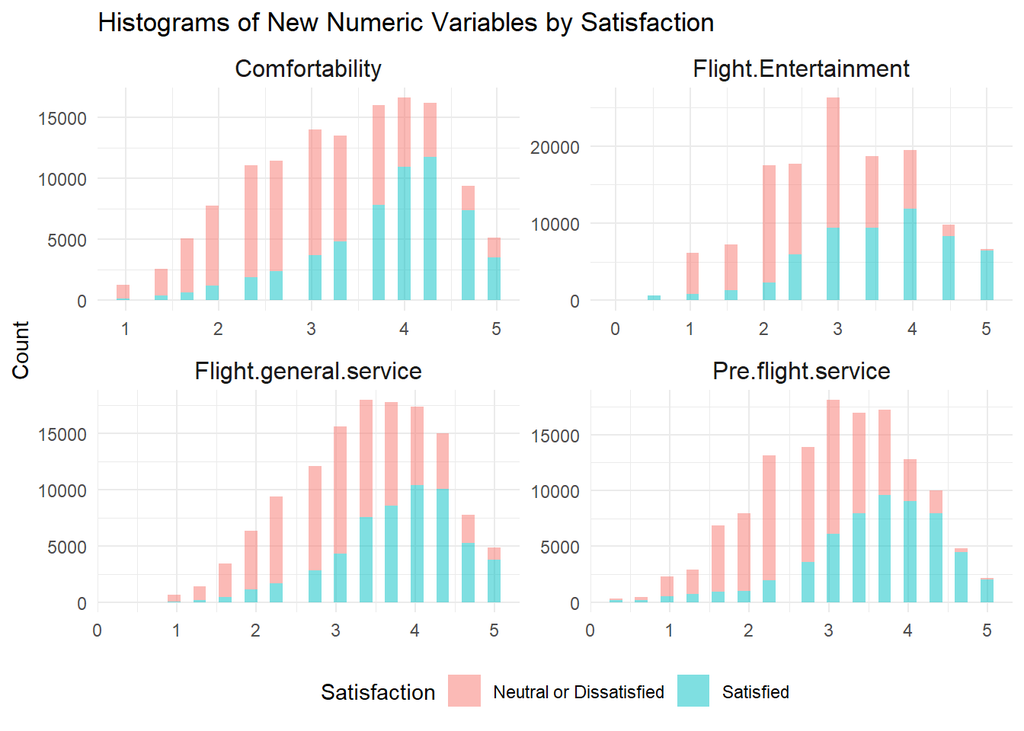

```r
# Create a subset of the data with grouped airline services
data_subset <- data %>%
  select(Satisfaction, Flight.general.service, Flight.Entertainment, Pre.flight.service, Comfortability)

# Convert to long format
data_long <- pivot_longer(data_subset, -Satisfaction, names_to = "Variable", values_to = "Value")

# Create faceted histogram
ggplot(data_long, aes(x = Value, fill = Satisfaction)) +
  geom_histogram(position = "stack", alpha = 0.5, bins = 30) +
  facet_wrap(~ Variable, scales = "free", ncol = 2) +
  theme_minimal() +
  labs(title = "Histograms of New Numeric Variables by Satisfaction",
       x = NULL, y = "Count") +
  theme(
    strip.text = element_text(size = 12),
    legend.position = "bottom"
  )
```

Graphic above is telling the satisfaction distribution based on services category such as comfortability, flight entertainment, in flight service, and pre flight service. We can see that the distribution of satisfaction is not significantly different between each category.

```r
# Percentage of satisfaction by Class
data %>% group_by(Class, Satisfaction) %>% summarize(num=n()) %>% mutate(percentage=round(num*100/sum(num),2))
```

```
## # A tibble: 6 × 4
## # Groups:   Class [3]
##   Class        Satisfaction              num percentage
##   <chr>        <chr>                   <int>      <dbl>
## 1 Business     Neutral or Dissatisfied 18994       30.6
## 2 Business     Satisfied               43166       69.4
## 3 Economy      Neutral or Dissatisfied 47366       81.2
## 4 Economy      Satisfied               10943       18.8
## 5 Economy Plus Neutral or Dissatisfied  7092       75.4
## 6 Economy Plus Satisfied                2319       24.6
```

Based on the data above, **69.4%** of Business passengers showing satisfaction, while only **18.8%** of Economy passengers showing satisfaction and only **24.6%** of Economy Plus passengers are satisfied. This indicates that the airline services are more satisfying for business class passengers compared to economy class passengers. This data highlights the need for airlines to focus on enhancing the customer experience, particularly in Economy and Economy Plus, to achieve better satisfaction rates.

```r
# Percentage of satisfaction by Type of Travel
data %>% group_by(Type.of.Travel, Satisfaction) %>%
summarize(num=n()) %>%
mutate(percentage=round(num*100/sum(num),2))
```

```
## # A tibble: 4 × 4
## # Groups:   Type.of.Travel [2]
##   Type.of.Travel Satisfaction              num percentage
##   <chr>          <chr>                   <int>      <dbl>
## 1 Business       Neutral or Dissatisfied 37337       41.6
## 2 Business       Satisfied               52356       58.4
## 3 Personal       Neutral or Dissatisfied 36115       89.9
## 4 Personal       Satisfied                4072       10.1
```

Personal type of travel passenger is having a third of airline total customer with the number of satisfied customer is only **10%** from it. This is much lower compared to the business type customers with **58.4%** satisfaction rate. Personal travel satisfaction levels indicate areas for improvement in service offerings or customer experience. To enhance customer satisfaction among various traveler types, it is crucial to refine customer segmentation strategies. This involves identifying and analyzing distinct traveler segments to understand their unique satisfaction triggers. By doing so, strategies to improve satisfaction rate on each segments can be effectively implemented.

```r
# Percentage of satisfaction by Customer Type
data %>% group_by(Customer.Type, Satisfaction) %>%
summarize(num=n()) %>%
mutate(percentage=round(num*100/sum(num),2))
```

```
## # A tibble: 4 × 4
## # Groups:   Customer.Type [2]
##   Customer.Type Satisfaction              num percentage
##   <chr>         <chr>                   <int>      <dbl>
## 1 First-time    Neutral or Dissatisfied 18080       76.0
## 2 First-time    Satisfied                5700       24.0
## 3 Returning     Neutral or Dissatisfied 55372       52.2
## 4 Returning     Satisfied               50728       47.8
```

**Returning Customers**: A majority, around 52%, are satisfied, while around 48% are neutral or dissatisfied. This indicates that returning customers are more satisfied with the airline services compared to first-time customers. This data highlights the need for airlines to focus on enhancing the customer experience, particularly for first-time customers, to achieve better satisfaction rates.

```r
# Percentage of satisfaction by Class for First-time Customers
data %>% filter(Customer.Type == 'First-time') %>% group_by(Class ,Satisfaction) %>%
summarize(num=n()) %>%
mutate(percentage=round(num*100/sum(num),2))
```

```
## # A tibble: 6 × 4
## # Groups:   Class [3]
##   Class        Satisfaction              num percentage
##   <chr>        <chr>                   <int>      <dbl>
## 1 Business     Neutral or Dissatisfied  5569      60.3
## 2 Business     Satisfied                3662      39.7
## 3 Economy      Neutral or Dissatisfied 11669      85.6
## 4 Economy      Satisfied                1965      14.4
## 5 Economy Plus Neutral or Dissatisfied   842      92.0
## 6 Economy Plus Satisfied                  73       7.98
```

The table shows significant differences in first-timer passenger satisfaction across flight classes. Business Class shows the highest satisfaction, with nearly 40% satisfied, though more than half remain neutral or dissatisfied. Economy Class fares worse, with 85% of passengers are not satisfied, and Economy Plus performs the poorest, with 92% dissatisfaction. Enhancing services for Economy and Economy Plus could greatly improve overall customer satisfaction.

In conclusion, mostly first-timer passengers feeling dissatisfied on each classes with notably higher in economy and economy plus class. This is a concern for the airline, as it indicates a need to improve services for first-time customers, to retain them and increase satisfaction rates. Leaving a good impression for first timer consumers is important to ensure they will come back and use the airline services again in the future. This is also important to ensure that the airline can maintain its market share and profitability in the long run.

```r
data %>% group_by(Distance_Group) %>%
summarize(num=n()) %>%
mutate(percentage=round(num*100/sum(num),2))
```

```
## # A tibble: 3 × 3
##   Distance_Group   num percentage
##   <chr>          <int>      <dbl>
## 1 Long-haul      20631       15.9
## 2 Medium-haul    37679       29.0
## 3 Short-haul     71570       55.1
```

Next we will try to analyze the service factors related to the customer satisfaction focusing on low satisfaction profile, starting with customer type :  
**CUSTOMER TYPE: FIRST-TIME**

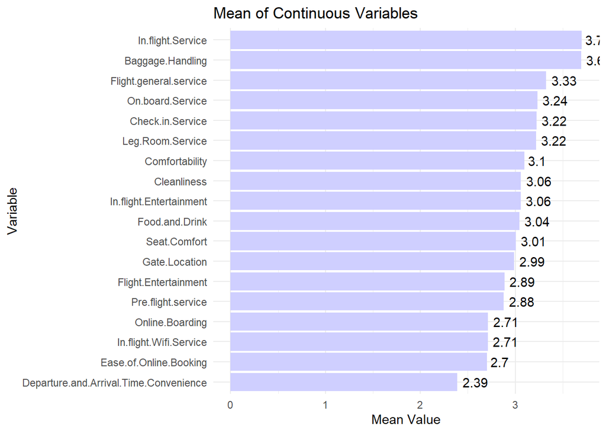

```r
# Compute mean for each continuous column
filtered_data <- data %>% filter(Customer.Type == 'First-time')
filtered_data <- subset(filtered_data, select = -c(ID, Flight.Distance, Age, Arrival.Delay,
                                                   Departure.Delay, Arrival.Delay.Duration,
                                                   Arrival.Delay.Duration.log,
                                                   Arrival.Delay.Duration.log.z,
                                                   Departure.Delay.Duration,
                                                   Departure.Delay.Duration.log,
                                                   Departure.Delay.Duration.log.z,
                                                   Flight.Distance.log, Flight.Distance.log.z,
                                                   Age.log, Age.log.z))

# Remove NA values (non-numeric columns)
mean_values <- sapply(filtered_data, function(x) if(is.numeric(x)) mean(x, na.rm = TRUE) else NA)
mean_values <- na.omit(mean_values)
mean_df <- data.frame(Variable = names(mean_values), Mean = mean_values)

# Sort in descending order
mean_df <- mean_df[order(mean_df$Mean, decreasing = TRUE), ]

# Plot bar chart with highest value on top and number labels
ggplot(mean_df, aes(x = reorder(Variable, Mean), y = Mean)) +
  geom_bar(stat = "identity", fill = "#CFCFFF") +
  geom_text(aes(label = round(Mean, 2)), hjust = -0.2) +
  coord_flip() +
  theme_minimal() +
  labs(title = "Mean of Continuous Variables", x = "Variable", y = "Mean Value")
```

As discussed above, first-timer group showed a significant dissatsifaction rate, thus through this graph, we can analyze which triggers the dissatisfaction. The graph above shows the mean of each service category for first-timer customers. The mean values are sorted in descending order, with the highest mean value on top. The mean values are calculated from the satisfaction rating of each service category.

This data can guide strategic improvements to enhance the first-time customer experience and increase satisfaction rates by focusing the improvement on those concerning satisfaction factors with the low score.  
**TYPE OF TRAVEL: PERSONAL**

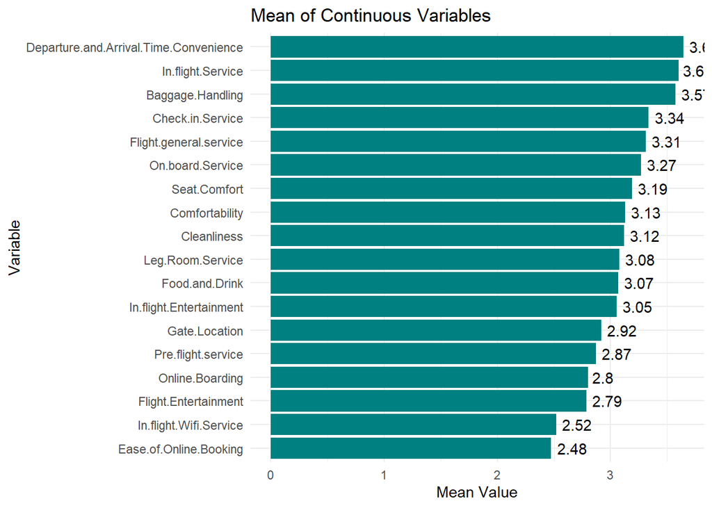

```r
# Compute mean for each continuous column
filtered_data <- data %>% filter(Type.of.Travel == 'Personal')
filtered_data <- subset(filtered_data, select = -c(ID, Flight.Distance, Age, Arrival.Delay,
                                                   Departure.Delay, Arrival.Delay.Duration,
                                                   Arrival.Delay.Duration.log,
                                                   Arrival.Delay.Duration.log.z,
                                                   Departure.Delay.Duration,
                                                   Departure.Delay.Duration.log,
                                                   Departure.Delay.Duration.log.z,
                                                   Flight.Distance.log, Flight.Distance.log.z,
                                                   Age.log, Age.log.z))

# Remove NA values (non-numeric columns)
mean_values <- sapply(filtered_data, function(x) if(is.numeric(x)) mean(x, na.rm = TRUE) else NA)
mean_values <- na.omit(mean_values)
mean_df <- data.frame(Variable = names(mean_values), Mean = mean_values)

# Sort in descending order
mean_df <- mean_df[order(mean_df$Mean, decreasing = TRUE), ]

# Plot bar chart with highest value on top and number labels
ggplot(mean_df, aes(x = reorder(Variable, Mean), y = Mean)) +
  geom_bar(stat = "identity", fill = "#008080") +
  geom_text(aes(label = round(Mean, 2)), hjust = -0.2) +
  coord_flip() +
  theme_minimal() +
  labs(title = "Mean of Continuous Variables", x = "Variable", y = "Mean Value")
```

In the previous section, we can see that personal type of travel passenger is having a third of airline total customer with the number of satisfied customer is only **10%** from it. Thus, the graph above becomes important to understand which factors are contributing to the low satisfaction rate. The graph above shows the mean of each service category for personal type of travel customers. The mean values are sorted in descending order, with the highest mean value on top. The mean values are calculated from the satisfaction rating of each service category.

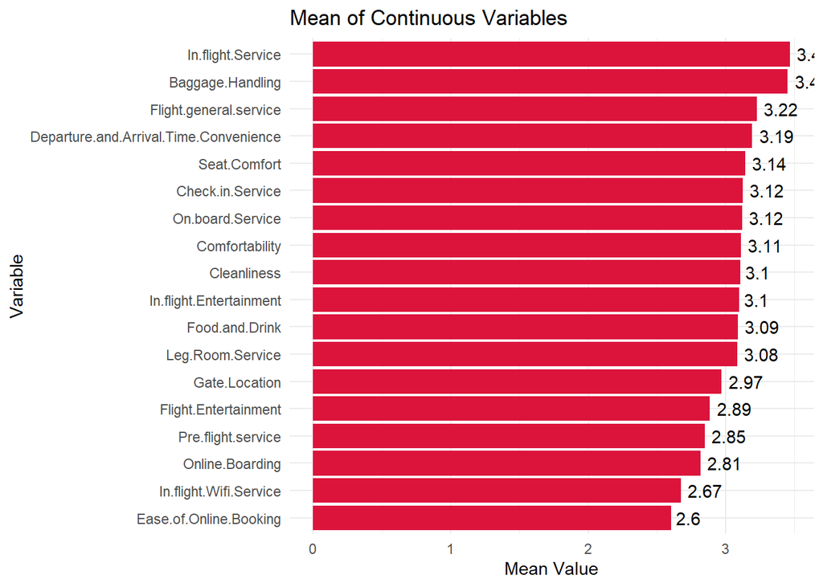

```r
# Compute mean for each continuous column
filtered_data <- data %>% filter(Class == 'Economy')
filtered_data <- subset(filtered_data, select = -c(ID, Flight.Distance, Age, Arrival.Delay,
                                                   Departure.Delay, Arrival.Delay.Duration,
                                                   Arrival.Delay.Duration.log,
                                                   Arrival.Delay.Duration.log.z,
                                                   Departure.Delay.Duration,
                                                   Departure.Delay.Duration.log,
                                                   Departure.Delay.Duration.log.z,
                                                   Flight.Distance.log, Flight.Distance.log.z,
                                                   Age.log, Age.log.z))

# Remove NA values (non-numeric columns)
mean_values <- sapply(filtered_data, function(x) if(is.numeric(x)) mean(x, na.rm = TRUE) else NA)
mean_values <- na.omit(mean_values)
mean_df <- data.frame(Variable = names(mean_values), Mean = mean_values)

# Sort in descending order
mean_df <- mean_df[order(mean_df$Mean, decreasing = TRUE), ]

# Plot bar chart with highest value on top and number labels
ggplot(mean_df, aes(x = reorder(Variable, Mean), y = Mean)) +
  geom_bar(stat = "identity", fill = "#DC143C") +
  geom_text(aes(label = round(Mean, 2)), hjust = -0.2) +
  coord_flip() +
  theme_minimal() +
  labs(title = "Mean of Continuous Variables", x = "Variable", y = "Mean Value")
```

## 2.6 Reflections

After performing the univariate and bivariate analysis, we can conclude that the airline service is not satisfying enough for the customers. The majority of passengers are not satisfied with the airline service, especially those who are first-time flyers and economy class passengers. The airline should focus on improving the services for these two segments to increase customer satisfaction. The analysis also shows that the airline has a strong returning customer base, which is a positive sign. However, the airline should not take this for granted and should continue to improve its services to retain these customers and attract new ones.

# 3 Data Modeling

Now, since the dataset is ready to be modeled, we can assign it a more descriptive name. In this section, we will apply two modeling techniques to achieve the objectives of our analysis:

1. Dimension Reduction
2. Classification Method

   2.1 Classification using Decision Tree Model

   2.2 Classification using Logistic Regression Model

## 3.1 Dimension Reduction

Now, we will perform PCA (Principal Component Analysis) to reduce the dimensionality of the dataset. PCA is a technique used to reduce the number of variables in a dataset while retaining as much information as possible. It does this by transforming the original variables into a new set of variables called principal components, which are linear combinations of the original variables. The first few principal components capture most of the variance in the data, allowing us to simplify the dataset without losing too much information. Furthermore, PCA can be used to reduce the dimensionality of the dataset while ensuring that we dont lose too much information

**PCA with Numeric Variable Only**

First, we will perform PCA on the numeric variables only. We will use the standardized data to perform PCA. The standardized data is created by removing the ID column and the log-transformed columns, and then scaling the remaining numeric variables.

```r
# Use the standardized data
data_standardized <- data %>%
  select(-c(ID, Arrival.Delay.Duration.log, Arrival.Delay.Duration.log.z,
            Departure.Delay.Duration.log, Departure.Delay.Duration.log.z, Flight.Distance.log,
            Flight.Distance.log.z,Departure.Delay.Duration, Arrival.Delay.Duration,
            Age.log, Age.log.z)) %>%
  select(where(is.numeric)) %>%
  scale(center = TRUE, scale = TRUE)

# Perform PCA
results <- prcomp(data_standardized)
summary(results)
```

```
## Importance of components:
##                          PC1    PC2    PC3   PC4     PC5     PC6     PC7
## Standard deviation     2.500 1.7009 1.5378 1.214 1.20323 1.03115 1.00626
## Proportion of Variance 0.284 0.1315 0.1075 0.067 0.06581 0.04833 0.04603
## Cumulative Proportion  0.284 0.4155 0.5230 0.590 0.65581 0.70415 0.75017
##                            PC8     PC9    PC10    PC11    PC12    PC13    PC14
## Standard deviation     0.96207 0.93256 0.73985 0.73395 0.72384 0.70377 0.65400
## Proportion of Variance 0.04207 0.03953 0.02488 0.02449 0.02382 0.02251 0.01944
## Cumulative Proportion  0.79224 0.83177 0.85665 0.88114 0.90496 0.92747 0.94691
##                           PC15    PC16    PC17   PC18      PC19      PC20
## Standard deviation     0.60816 0.54522 0.53207 0.4666 1.468e-14 8.624e-15
## Proportion of Variance 0.01681 0.01351 0.01287 0.0099 0.000e+00 0.000e+00
## Cumulative Proportion  0.96372 0.97723 0.99010 1.0000 1.000e+00 1.000e+00
##                             PC21      PC22
## Standard deviation     7.555e-15 6.479e-15
## Proportion of Variance 0.000e+00 0.000e+00
## Cumulative Proportion  1.000e+00 1.000e+00
```

Then, we will plot the PCA results to visualize the variance explained by each principal component. The scree plot shows the proportion of variance explained by each principal component. The result shows that the cummulative value already achieved 90% using 12 Principal Components as below.

```r
# Plot the PCA results
results$rotation[ , c(1:2) ]
```

```
##                                                 PC1           PC2
## Age                                    -0.047872121  0.0336385640
## Flight.Distance                        -0.078332845 -0.0018773705
## Departure.Delay                         0.006573192 -0.0033750811
## Arrival.Delay                           0.018111380  0.0007851822
## Departure.and.Arrival.Time.Convenience -0.077717374  0.3150621228
## Ease.of.Online.Booking                 -0.145668271  0.4799177326
## Check.in.Service                       -0.140699313  0.0035210646
## Online.Boarding                        -0.230789748  0.2130984022
## Gate.Location                          -0.053614742  0.3229454746
## On.board.Service                       -0.211466635 -0.1400659693
## Seat.Comfort                           -0.266569667 -0.1141431987
## Leg.Room.Service                       -0.177631249 -0.0781383076
## Cleanliness                            -0.272995212 -0.1451299221
## Food.and.Drink                         -0.237436436 -0.1385787618
## In.flight.Service                      -0.197822341 -0.1475750486
## In.flight.Wifi.Service                 -0.202622660  0.4003442397
## In.flight.Entertainment                -0.328215094 -0.1898314416
## Baggage.Handling                       -0.186841650 -0.1266896907
## Flight.general.service                 -0.315027598 -0.2065932259
## Flight.Entertainment                   -0.341688353  0.1347743608
## Pre.flight.service                     -0.250851327  0.3487749068
## Comfortability                         -0.328679031 -0.1546031847
```

Next, To focus on variable with high loadings, we set the threshold of 0.2 and only select the first principal component.

```r
# Loadings for the first principal component
loadings <- data.frame(results$rotation)
threshold <- 0.20
indices <- abs(loadings$PC1) >= threshold
data.frame(variable = rownames(loadings)[indices],
           loading = loadings$PC1[indices])
```

```
##                   variable    loading
## 1          Online.Boarding -0.2307897
## 2         On.board.Service -0.2114666
## 3             Seat.Comfort -0.2665697
## 4              Cleanliness -0.2729952
## 5           Food.and.Drink -0.2374364
## 6   In.flight.Wifi.Service -0.2026227
## 7  In.flight.Entertainment -0.3282151
## 8   Flight.general.service -0.3150276
## 9     Flight.Entertainment -0.3416884
## 10      Pre.flight.service -0.2508513
## 11          Comfortability -0.3286790
```

Furthermore, we will plot the loadings of the first principal component to visualize which variables contribute most to the first principal component.

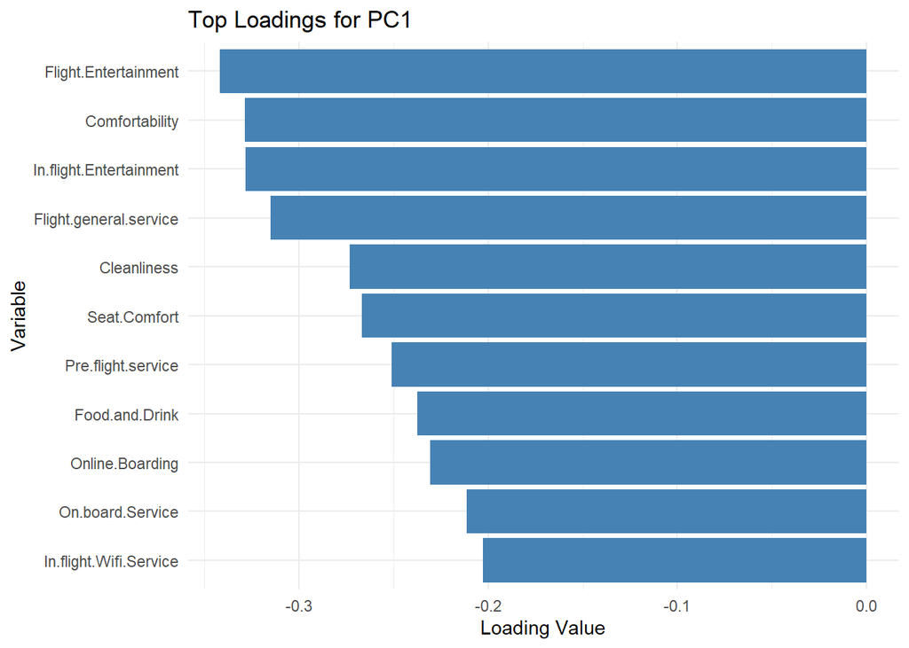

```r
# Get loadings for the first principal component
loadings_df <- data.frame(
  variable = rownames(loadings)[indices],
  loading = loadings$PC1[indices]
)

# Plot the loadings
ggplot(loadings_df, aes(x = reorder(variable, -loading), y = loading, fill = loading > 0)) +
  geom_col(show.legend = FALSE) +
  coord_flip() +
  labs(title = "Top Loadings for PC1",
       x = "Variable",
       y = "Loading Value") +
  scale_fill_manual(values = c("steelblue", "tomato")) +
  theme_minimal()
```

Next, we are analyzing top contributor in PC1-PC12

```r
# Get loadings for all components
loadings <- as.data.frame(results$rotation)
loadings$Variable <- rownames(loadings)

# Top contributors for PC1–PC12
top_vars <- apply(abs(loadings[, 1:12]), 2, function(x) names(sort(x, decreasing = TRUE)[1:5]))
print(top_vars)
```

```
##      PC1                       PC2
## [1,] "Flight.Entertainment"    "Ease.of.Online.Booking"
## [2,] "Comfortability"          "In.flight.Wifi.Service"
## [3,] "In.flight.Entertainment" "Pre.flight.service"
## [4,] "Flight.general.service"  "Gate.Location"
## [5,] "Cleanliness"             "Departure.and.Arrival.Time.Convenience"
##      PC3                 PC4                  PC5
## [1,] "In.flight.Service" "Check.in.Service"   "Departure.Delay"
## [2,] "Baggage.Handling"  "Online.Boarding"    "Arrival.Delay"
## [3,] "On.board.Service"  "Pre.flight.service" "Check.in.Service"
## [4,] "Seat.Comfort"      "Gate.Location"      "Flight.Distance"
## [5,] "Cleanliness"       "Arrival.Delay"      "Pre.flight.service"
##      PC6                  PC7
## [1,] "Check.in.Service"   "Departure.and.Arrival.Time.Convenience"
## [2,] "Flight.Distance"    "Gate.Location"
```

[output cut: 27 more lines]

PC1 – In-Flight Amenities & Comfort Driven by Flight.Entertainment, Comfortability, In.flight.Entertainment, Flight.general.service, and Cleanliness. This component captures the overall in-flight experience focused on comfort and entertainment.

PC2 – Digital & Booking Experience Influenced by Ease.of.Online.Booking, Pre.flight.service, and In.flight.Wifi.Service. It represents passengers’ interaction with digital services before and during the flight.

PC3 – Operational Onboard Service Dominated by In.flight.Service, Baggage.Handling, and Seat.Comfort, this component reflects service reliability and seat-related comfort during the flight.

PC8 – Age-Based Travel Patterns Mainly driven by Age, Flight.Distance, and Check.in.Service, this component shows how age may influence travel experience and expectations.

PC9 – Comfort in Long Trips Includes Leg.Room.Service, Flight.Distance, and Comfortability, highlighting comfort needs for longer or more frequent flights.

PC10 – In-Flight Consumables Composed of On.board.Service, Flight.general.service, and Food.and.Drink, focusing on passengers’ satisfaction with in-flight consumables.

PC11 – Delays & Terminal Logistics Influenced by Arrival.Delay, Departure.Delay, and Gate.Location, this component represents disruptions tied to flight and gate logistics.

PC12 – Check-In & Time Coordination Driven by Departure.and.Arrival.Time.Convenience and Check.in.Service, highlighting the efficiency of early-stage travel processes.

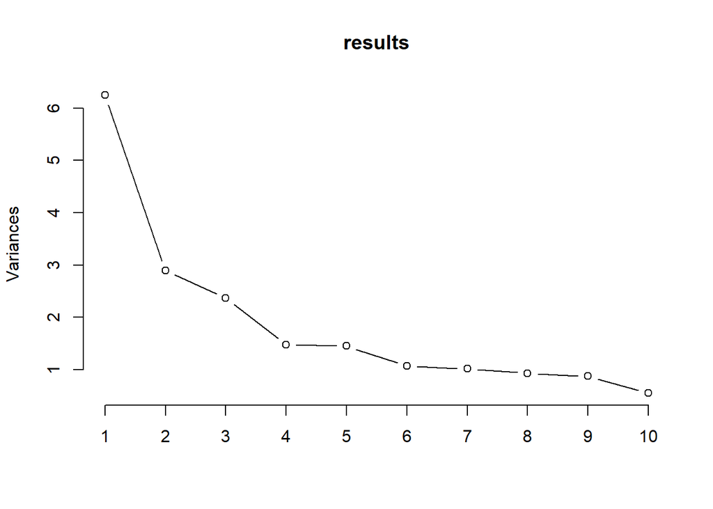

```r
# Plot the scree plot
screeplot(results, type = "lines")
```

From the plot above, we can see that the first 12 components explain over 90% of the variance in the data. This indicates that the data is well-structured and that there are strong correlations between the variables. The first few components capture most of the variance in the data, allowing us to simplify the dataset without losing too much information.

**PCA with One Hot Encoding**

From the previous analysis, we can see that the PCA is performed on the numeric variables only. However, we can also perform PCA on the categorical variables by using one-hot encoding. One-hot encoding is a technique used to convert categorical variables into a format that can be provided to machine learning algorithms to do a better job in prediction.

```r
# Use the standardized data
data_standardized <- data %>%
  select(-c(ID, Arrival.Delay.Duration.log, Arrival.Delay.Duration.log.z,
            Departure.Delay.Duration.log, Departure.Delay.Duration.log.z, Flight.Distance.log,
            Flight.Distance.log.z,Departure.Delay.Duration, Arrival.Delay.Duration,
            Age.log, Age.log.z))

# One-hot encode categorical variables
dummies <- dummyVars(~ ., data = data_standardized)
data_encoded <- predict(dummies, newdata = data_standardized)

# Standardize the data
data_encoded_standardized <- scale(data_encoded, center = TRUE, scale = TRUE)

# Perform PCA
results <- prcomp(data_encoded_standardized)
summary(results)
```

```
## Importance of components:
##                           PC1    PC2     PC3     PC4     PC5     PC6     PC7
## Standard deviation     2.8194 2.3912 1.89722 1.74782 1.69078 1.55506 1.43131
## Proportion of Variance 0.1728 0.1243 0.07825 0.06641 0.06215 0.05257 0.04454
## Cumulative Proportion  0.1728 0.2971 0.37535 0.44176 0.50391 0.55648 0.60101
##                            PC8     PC9    PC10    PC11    PC12    PC13    PC14
## Standard deviation     1.40361 1.31121 1.22660 1.19899 1.17702 1.11575 1.05445
## Proportion of Variance 0.04283 0.03738 0.03271 0.03125 0.03012 0.02706 0.02417
## Cumulative Proportion  0.64384 0.68122 0.71393 0.74518 0.77529 0.80236 0.82653
##                           PC15    PC16    PC17   PC18    PC19    PC20    PC21
## Standard deviation     1.00270 0.98245 0.94601 0.8525 0.72984 0.71330 0.69079
## Proportion of Variance 0.02186 0.02098 0.01946 0.0158 0.01158 0.01106 0.01037
## Cumulative Proportion  0.84839 0.86937 0.88882 0.9046 0.91620 0.92726 0.93764
##                           PC22    PC23   PC24    PC25    PC26    PC27    PC28
## Standard deviation     0.67703 0.64554 0.6067 0.54605 0.51879 0.51573 0.47762
## Proportion of Variance 0.00996 0.00906 0.0080 0.00648 0.00585 0.00578 0.00496
## Cumulative Proportion  0.94760 0.95666 0.9647 0.97114 0.97700 0.98278 0.98774
##                          PC29    PC30    PC31    PC32      PC33      PC34
## Standard deviation     0.4551 0.39657 0.35601 0.27021 7.748e-13 5.826e-14
## Proportion of Variance 0.0045 0.00342 0.00276 0.00159 0.000e+00 0.000e+00
## Cumulative Proportion  0.9922 0.99566 0.99841 1.00000 1.000e+00 1.000e+00
##                             PC35      PC36      PC37      PC38      PC39
## Standard deviation     4.501e-14 2.886e-14 2.161e-14 1.681e-14 1.406e-14
## Proportion of Variance 0.000e+00 0.000e+00 0.000e+00 0.000e+00 0.000e+00
## Cumulative Proportion  1.000e+00 1.000e+00 1.000e+00 1.000e+00 1.000e+00
##                             PC40      PC41      PC42      PC43      PC44
## Standard deviation     1.397e-14 1.167e-14 7.905e-15 6.242e-15 5.776e-15
## Proportion of Variance 0.000e+00 0.000e+00 0.000e+00 0.000e+00 0.000e+00
## Cumulative Proportion  1.000e+00 1.000e+00 1.000e+00 1.000e+00 1.000e+00
##                             PC45    PC46
## Standard deviation     4.919e-15 4.5e-15
## Proportion of Variance 0.000e+00 0.0e+00
## Cumulative Proportion  1.000e+00 1.0e+00
```

## 3.2 Classification Method : Decision Tree Model

Classification is an example of supervised learning where the model is trained to predict label variables based on the features of the dataset. In this case, we will use decision tree as the classification method,as the most popular and widely used classification method. Decision tree is a flowchart-like structure where each internal node represents a test on an attribute, each branch represents the outcome of the test, and each leaf node represents a class label. It works by splitting the data into subsets based on the value of the input features. The splitting process continues until a stopping criterion is met, such as reaching a maximum depth or minimum number of samples in a leaf node.

We use c50 as the package to implement decision tree. C5.0 is an improved version of C4.5, which is a popular algorithm for generating decision trees. It is known for its speed and accuracy, and it can handle large datasets with many features. C5.0 also includes features such as boosting, which can improve the performance of the model by combining multiple weak classifiers into a strong classifier.

### 3.2.1 Model Preparation

```r
# Create copy of dataset for the purpose of classification only, convert to factor
data_clsf <- data %>%
      mutate(across(-c(ID, Age, Flight.Distance, Departure.Delay, Arrival.Delay,
                   Departure.Delay.Duration,
                   Arrival.Delay.Duration, Arrival.Delay.Duration.log, Arrival.Delay.Duration.log.z,
                   Departure.Delay.Duration.log, Departure.Delay.Duration.log.z, Flight.Distance.log,
                   Flight.Distance.log.z, Age.log, Age.log.z), as.factor))

# Encode Target Variable
data_clsf$Satisfaction <- ifelse(data_clsf$Satisfaction=="Satisfied",1,0)
data_clsf$Satisfaction <- factor(data_clsf$Satisfaction, levels = c(0, 1))

# For experiment, create subset of untransformed data, data with log, and data with normalization
data_clsf_ori <- data_clsf %>%
  select(-c(ID, Arrival.Delay.Duration.log, Arrival.Delay.Duration.log.z,
            Departure.Delay.Duration.log, Departure.Delay.Duration.log.z, Flight.Distance.log,
            Flight.Distance.log.z, Age.log, Age.log.z))

data_clsf_log <- data_clsf %>%
  select(-c(ID, Arrival.Delay.Duration.log.z, Departure.Delay.Duration.log.z, Flight.Distance.log.z,
            Departure.Delay.Duration, Arrival.Delay.Duration, Age.log.z, Arrival.Delay.Duration,
            Departure.Delay.Duration, Flight.Distance, Age))

data_clsf_norm <- data_clsf %>%
  select(-c(ID, Arrival.Delay.Duration.log,
            Departure.Delay.Duration.log, Flight.Distance.log,
            Age.log, Arrival.Delay.Duration,
            Departure.Delay.Duration, Flight.Distance, Age))
```

**Split Dataset Training Testing for Untransformed Data**

```r
set.seed(46748717)

# Split the data into 70% training and 30% testing
proportion <-  0.7
split <- initial_split(data_clsf_ori, prop = proportion)
training <- training(split)
testing <- testing(split)
```

### 3.2.2 Training a decision tree model on the data

From the training data, we will train a decision tree model using the C5.0 algorithm.

```r
# Train the model
model <- C50::C5.0(Satisfaction ~.,
                   data = training)

# Print the model summary
summary(model)
```

```
##
## Call:
## C5.0.formula(formula = Satisfaction ~ ., data = training)
##
##
## C5.0 [Release 2.07 GPL Edition]      Thu Apr 17 20:56:07 2025
## -------------------------------
##
## Class specified by attribute `outcome'
##
## Read 90916 cases (34 attributes) from undefined.data
##
## Decision tree:
##
## In.flight.Wifi.Service in {0,5}:
## :...Cleanliness = 0: 0 (4)
## :   Cleanliness in {1,2,3,4,5}:
## :   :...Ease.of.Online.Booking in {0,5}:
## :       :...Flight.Entertainment in {0,0.5,1,1.5,2,2.5,3.5,4,
## :       :   :                        4.5}: 1 (6785)
## :       :   Flight.Entertainment in {3,5}:
## :       :   :...In.flight.Service in {0,1,2,4,5}: 1 (2966/7)
## :       :       In.flight.Service = 3:
## :       :       :...Online.Boarding in {0,1,2,3,5}: 1 (192)
## :       :           Online.Boarding = 4:
## :       :           :...Cleanliness in {1,2,3,4}: 1 (12)
## :       :               Cleanliness = 5: 0 (11/2)
## :       Ease.of.Online.Booking in {1,2,3,4}:
## :       :...Online.Boarding in {0,1,5}: 1 (1821/3)
## :           Online.Boarding in {2,3,4}:
## :           :...In.flight.Entertainment in {0,1,2,3,4}: 1 (448/3)
## :               In.flight.Entertainment = 5:
## :               :...Leg.Room.Service = 0: 1 (0)
## :                   Leg.Room.Service = 5:
## :                   :...On.board.Service in {0,1,3,4,5}: 1 (341)
## :                   :   On.board.Service = 2:
## :                   :   :...Age <= 35: 0 (3)
## :                   :       Age > 35: 1 (3)
## :                   Leg.Room.Service in {1,2,3,4}:
## :                   :...Customer.Type = First-time: 1 (15)
```

[output cut: 1291 more lines]

```
##    3.22% Flight.general.service
##    2.30% Departure.and.Arrival.Time.Convenience
##    1.90% Food.and.Drink
##    0.95% Flight.Distance
##    0.63% Pre.flight.service
##    0.51% Distance_Group
##    0.27% Gender
##    0.25% Departure.Delay
##    0.12% arrival.delay.status
##    0.07% delay.status
##    0.02% Arrival.Delay
##    0.01% Departure.Delay.Duration
##
##
## Time: 1.5 secs
```

Next, we visualize the model to better understand how the decision tree makes predictions.

Plotting top 5 model :

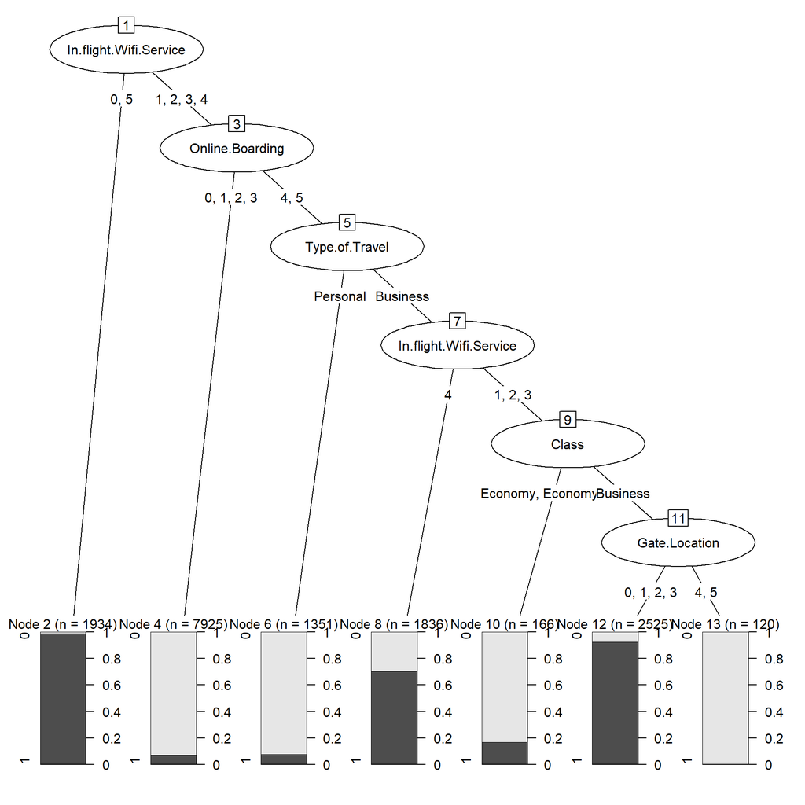

```r
# Visualization-only version, targeting ~5 levels
model_top5 <- C5.0(Satisfaction ~ ., data = training,
                   control = C5.0Control(minCases = 3500, CF = 0.25))
plot(model_top5)
```

```r
print("Confusion matrix based on testing data")
```

```
## [1] "Confusion matrix based on testing data"
```

```r
pred.test <- predict(model, testing)
gmodels::CrossTable(testing$Satisfaction, pred.test,
                    prop.chisq = FALSE,
                    prop.c = FALSE,
                    prop.r = FALSE,
                    prop.t = FALSE,
                    dnn = c("Actual Satisfaction", "Predicted Satisfaction"))
```

```
##
##
##    Cell Contents
## |-------------------------|
## |                       N |
## |-------------------------|
##
##
## Total Observations in Table:  38964
##
##
##                     | Predicted Satisfaction
## Actual Satisfaction |         0 |         1 | Row Total |
## --------------------|-----------|-----------|-----------|
##                   0 |     21509 |       484 |     21993 |
## --------------------|-----------|-----------|-----------|
##                   1 |      1069 |     15902 |     16971 |
## --------------------|-----------|-----------|-----------|
##        Column Total |     22578 |     16386 |     38964 |
## --------------------|-----------|-----------|-----------|
##
##
```

```r
# --- Calculate Metrics ---

# Create the confusion matrix table
conf_matrix <- table(Actual = testing$Satisfaction, Predicted = pred.test)

# Extract True Positives, True Negatives, False Positives, and False Negatives. 0 representing dissatisfaction, 1 represent satisfaction.
tp <- conf_matrix["0", "0"]
tn <- conf_matrix["1", "1"]
fp <- conf_matrix["1", "0"]
fn <- conf_matrix["0", "1"]

# Calculate metrics
accuracy <- (tp + tn) / sum(conf_matrix)
precision <- tp / (tp + fp)
recall <- tp / (tp + fn)
f1_score <- 2 * (precision * recall) / (precision + recall)

# Print metrics
cat("\nMetrics for Model with data testing:\n")
```

```
##
## Metrics for Model with data testing:
```

```r
cat("Accuracy: ", round(accuracy, 2), "\n")
```

```
## Accuracy:  0.96
```

```r
cat("Precision: ", round(precision, 2), "\n")
```

```
## Precision:  0.95
```

```r
cat("Recall: ", round(recall, 2), "\n")
```

```
## Recall:  0.98
```

```r
cat("F1-Score: ", round(f1_score, 2), "\n")
```

```
## F1-Score:  0.97
```

As we can see at the metrics for the model, it shows high accuracy at 96%. The model is able to predict the satisfaction level of the customers with high accuracy. The precision and recall are also high at 95% and 98% respectively, indicating that the model is able to correctly identify the satisfied customers and dissatisfied customers. The F1-score is also high, indicating that the model is able to balance precision and recall well.

**Try with dataset that already log transformed**

```r
set.seed(46748717)

# Split the data into 70% training and 30% testing
proportion <-  0.7
split <- initial_split(data_clsf_log, prop = proportion)
training <- training(split)
testing <- testing(split)

# Train the model
model <- C50::C5.0(Satisfaction ~.,
                   data = training)

# Print the model summary
summary(model)
```

```
##
## Call:
## C5.0.formula(formula = Satisfaction ~ ., data = training)
##
##
## C5.0 [Release 2.07 GPL Edition]      Thu Apr 17 20:56:36 2025
## -------------------------------
##
## Class specified by attribute `outcome'
##
## Read 90916 cases (34 attributes) from undefined.data
##
## Decision tree:
##
## In.flight.Wifi.Service in {0,5}:
## :...Cleanliness = 0: 0 (4)
## :   Cleanliness in {1,2,3,4,5}:
## :   :...Ease.of.Online.Booking in {0,5}:
## :       :...Flight.Entertainment in {0,0.5,1,1.5,2,2.5,3.5,4,
## :       :   :                        4.5}: 1 (6785)
## :       :   Flight.Entertainment in {3,5}:
## :       :   :...In.flight.Service in {0,1,2,4,5}: 1 (2966/7)
## :       :       In.flight.Service = 3:
## :       :       :...Online.Boarding in {0,1,2,3,5}: 1 (192)
## :       :           Online.Boarding = 4:
## :       :           :...Cleanliness in {1,2,3,4}: 1 (12)
## :       :               Cleanliness = 5: 0 (11/2)
## :       Ease.of.Online.Booking in {1,2,3,4}:
## :       :...Online.Boarding in {0,1,5}: 1 (1821/3)
## :           Online.Boarding in {2,3,4}:
## :           :...In.flight.Entertainment in {0,1,2,3,4}: 1 (448/3)
## :               In.flight.Entertainment = 5:
## :               :...Leg.Room.Service = 0: 1 (0)
## :                   Leg.Room.Service = 5:
## :                   :...On.board.Service in {0,1,3,4,5}: 1 (341)
## :                   :   On.board.Service = 2:
## :                   :   :...Age.log <= 3.583519: 0 (3)
## :                   :       Age.log > 3.583519: 1 (3)
## :                   Leg.Room.Service in {1,2,3,4}:
## :                   :...Customer.Type = First-time: 1 (15)
```

[output cut: 1160 more lines]

```
##    3.78% Age_Range
##    3.18% Flight.general.service
##    2.26% Departure.and.Arrival.Time.Convenience
##    1.75% Food.and.Drink
##    0.90% Flight.Distance.log
##    0.57% Pre.flight.service
##    0.47% Distance_Group
##    0.27% Gender
##    0.25% Departure.Delay
##    0.12% arrival.delay.status
##    0.04% delay.status
##    0.02% Arrival.Delay
##
##
## Time: 1.3 secs
```

```r
# Print the confusion matrix
print("Confusion matrix based on testing data")
```

```
## [1] "Confusion matrix based on testing data"
```

```r
pred.test <- predict(model, testing)
gmodels::CrossTable(testing$Satisfaction, pred.test,
                    prop.chisq = FALSE,
                    prop.c = FALSE,
                    prop.r = FALSE,
                    prop.t = FALSE,
                    dnn = c("Actual Satisfaction", "Predicted Satisfaction"))
```

```
##
##
##    Cell Contents
## |-------------------------|
## |                       N |
## |-------------------------|
##
##
## Total Observations in Table:  38964
##
##
##                     | Predicted Satisfaction
## Actual Satisfaction |         0 |         1 | Row Total |
## --------------------|-----------|-----------|-----------|
##                   0 |     21501 |       492 |     21993 |
## --------------------|-----------|-----------|-----------|
##                   1 |      1065 |     15906 |     16971 |
## --------------------|-----------|-----------|-----------|
##        Column Total |     22566 |     16398 |     38964 |
## --------------------|-----------|-----------|-----------|
##
##
```

```r
# --- Calculate Metrics ---

# Create the confusion matrix table
conf_matrix <- table(Actual = testing$Satisfaction, Predicted = pred.test)

# Extract True Positives, True Negatives, False Positives, and False Negatives. 0 representing dissatisfaction, 1 represent satisfaction.
tp <- conf_matrix["0", "0"]
tn <- conf_matrix["1", "1"]
fp <- conf_matrix["1", "0"]
fn <- conf_matrix["0", "1"]

# Calculate metrics
accuracy <- (tp + tn) / sum(conf_matrix)
precision <- tp / (tp + fp)
recall <- tp / (tp + fn)
f1_score <- 2 * (precision * recall) / (precision + recall)

# Print metrics
cat("\nMetrics for Model with data training:\n")
```

```
##
## Metrics for Model with data training:
```

```r
cat("Accuracy: ", round(accuracy, 2), "\n")
```

```
## Accuracy:  0.96
```

```r
cat("Precision: ", round(precision, 2), "\n")
```

```
## Precision:  0.95
```

```r
cat("Recall: ", round(recall, 2), "\n")
```

```
## Recall:  0.98
```

```r
cat("F1-Score: ", round(f1_score, 2), "\n")
```

```
## F1-Score:  0.97
```

The result is almost identical since the algorithm determine the transformed data is not have significant importance. Therefore the improvement will focus on tuning the parameter of the model.

### 3.2.3 Model Improvement

In this section, we tried to explore whether there is a room to improve the model performance. Note that the model performance is considered good with accuracy of 96%, but we will try to improve it by tuning the parameters of the model. The model performance is measured by accuracy, precision, recall, and F1-score. The model performance is evaluated using the testing data.

**1. Boosting**

**Boosting** is one of methods to improve the performance of the model. The idea is to combine multiple weak classifiers to create a strong classifier. In this section, we will use boosting to improve the performance of the decision tree model.Key concept of boosting includes sequential learning where each new model is trained to correct the errors of the previous model (Schwenk,2000). The final model then is a weighted sum of all the models, where the weights are determined by the performance of each model. Finally, loss minimization is used to minimize the error of the final model.

```r
set.seed(46748717)

# Split the data into 70% training and 30% testing
proportion <- 0.7
split <- initial_split(data_clsf_ori, prop = proportion)
training <- training(split)
testing <- testing(split)

# Train the boosting model
model_boost <- C5.0(Satisfaction ~ .,
                    data = training,
                    trials = 10)

# Predict on the testing data
pred.test <- predict(model_boost, testing)

# Generate the confusion matrix
print("Confusion matrix based on testing data (boosting)")
```

```
## [1] "Confusion matrix based on testing data (boosting)"
```

```r
CrossTable(testing$Satisfaction, pred.test,
           prop.chisq = FALSE,
           prop.c = FALSE,
           prop.r = FALSE,
           prop.t = FALSE,
           dnn = c("Actual Satisfaction", "Predicted Satisfaction"))
```

```
##
##
##    Cell Contents
## |-------------------------|
## |                       N |
## |-------------------------|
##
##
## Total Observations in Table:  38964
##
##
##                     | Predicted Satisfaction
## Actual Satisfaction |         0 |         1 | Row Total |
## --------------------|-----------|-----------|-----------|
##                   0 |     21370 |       623 |     21993 |
## --------------------|-----------|-----------|-----------|
##                   1 |       980 |     15991 |     16971 |
## --------------------|-----------|-----------|-----------|
##        Column Total |     22350 |     16614 |     38964 |
## --------------------|-----------|-----------|-----------|
##
##
```

```r
# --- Calculate Metrics ---

# Create the confusion matrix table
conf_matrix <- table(Actual = testing$Satisfaction, Predicted = pred.test)

# Extract True Positives, True Negatives, False Positives, and False Negatives. 0 representing dissatisfaction, 1 represent satisfaction.
tp <- conf_matrix["0", "0"]
tn <- conf_matrix["1", "1"]
fp <- conf_matrix["1", "0"]
fn <- conf_matrix["0", "1"]

# Calculate metrics
accuracy <- (tp + tn) / sum(conf_matrix)
precision <- tp / (tp + fp)
recall <- tp / (tp + fn)
f1_score <- 2 * (precision * recall) / (precision + recall)

# Print metrics
cat("\nMetrics for Boosting Model:\n")
```

```
##
## Metrics for Boosting Model:
```

```r
cat("Accuracy: ", round(accuracy, 2), "\n")
```

```
## Accuracy:  0.96
```

```r
cat("Precision: ", round(precision, 2), "\n")
```

```
## Precision:  0.96
```

```r
cat("Recall: ", round(recall, 2), "\n")
```

```
## Recall:  0.97
```

```r
cat("F1-Score: ", round(f1_score, 2), "\n")
```

```
## F1-Score:  0.96
```

Let’s compare with the previous model performance

| Metric | Previous Model | Boosting Model |
| --- | --- | --- |
| Accuracy | 0.96 | 0.96 |
| Precision | 0.95 | 0.96 |
| Recall | 0.98 | 0.97 |
| F1-Score | 0.97 | 0.96 |

Based on the result above, there is no significant improvement in terms of model performance. This strengthen the idea that the model performance is already good. However, we can see that the precision is slightly improved from 0.95 to 0.96, while the recall is slightly decreased from 0.98 to 0.97. The F1-score is also slightly decreased from 0.97 to 0.96. In conclusion, our model performance is already good and there is no significant improvement after boosting.

**2. Assigning Cost to Mistake**

```r
# Specifying the cost matrix
cost.matrix <- matrix(c(NA, 1,  # FN costs of predicting "Disatisfied" whereas actual value is "Satisfied"
                        2, NA), # FP costs of predicting "Satisfied" whereas actual value is "Disatisfied"
                      nrow = 2,
                      ncol = 2,
                      byrow = FALSE)
rownames(cost.matrix) <- colnames(cost.matrix) <- c(1, 0)

# Estimating the model with the cost matrix
model.cost <- C5.0(Satisfaction ~.,
              data = training,
              costs = cost.matrix)

# Predicting on the testing data
pred.test <- predict(model.cost, testing)

# Generating the confusion matrix
print("Confusion matrix based on testing data (costs")
```

```
## [1] "Confusion matrix based on testing data (costs"
```

```r
CrossTable(testing$Satisfaction, pred.test,
           prop.chisq = FALSE,
           prop.c = FALSE,
           prop.r = FALSE,
           prop.t = FALSE,
           dnn = c("Actual Satisfaction", "Predicted Satisfaction"))
```

```
##
##
##    Cell Contents
## |-------------------------|
## |                       N |
## |-------------------------|
##
##
## Total Observations in Table:  38964
##
##
##                     | Predicted Satisfaction
## Actual Satisfaction |         0 |         1 | Row Total |
## --------------------|-----------|-----------|-----------|
##                   0 |     21726 |       267 |     21993 |
## --------------------|-----------|-----------|-----------|
##                   1 |      1424 |     15547 |     16971 |
## --------------------|-----------|-----------|-----------|
##        Column Total |     23150 |     15814 |     38964 |
## --------------------|-----------|-----------|-----------|
##
##
```

```r
# --- Calculate Metrics ---

# Create the confusion matrix table
conf_matrix <- table(Actual = testing$Satisfaction, Predicted = pred.test)

# Extract True Positives, True Negatives, False Positives, and False Negatives. 0 representing dissatisfaction, 1 represent satisfaction.
tp <- conf_matrix["0", "0"]
tn <- conf_matrix["1", "1"]
fp <- conf_matrix["1", "0"]
fn <- conf_matrix["0", "1"]

# Calculate metrics
accuracy <- (tp + tn) / sum(conf_matrix)
precision <- tp / (tp + fp)
recall <- tp / (tp + fn)
f1_score <- 2 * (precision * recall) / (precision + recall)

# Print metrics
cat("\nMetrics for Cost sensitive learning  Model:\n")
```

```
##
## Metrics for Cost sensitive learning  Model:
```

```r
cat("Accuracy: ", round(accuracy, 2), "\n")
```

```
## Accuracy:  0.96
```

```r
cat("Precision: ", round(precision, 2), "\n")
```

```
## Precision:  0.94
```

```r
cat("Recall: ", round(recall, 2), "\n")
```

```
## Recall:  0.99
```

```r
cat("F1-Score: ", round(f1_score, 2), "\n")
```

```
## F1-Score:  0.96
```

Let’s compare with the previous model performance

| Metric | Previous Model | Cost Sensitive Model |
| --- | --- | --- |
| Accuracy | 0.96 | 0.96 |
| Precision | 0.95 | 0.94 |
| Recall | 0.98 | 0.99 |
| F1-Score | 0.97 | 0.96 |

Based on the performance comparison, cost mistake assignment result is not significantly different with the model. This indicates that our model performance is having a good performance already. However, we can see that the recall is slightly increased from 0.98 to 0.99, while the precision is slightly decreased from 0.95 to 0.94. The F1-score is also slightly decreased from 0.97 to 0.96. In conclusion, our model performance is already good and there is no significant improvement after assigning cost to mistake.

**3. Random Forest**

Another method for model improvement is **Random Forest**. This method is an ensemble learning method that combines multiple decision trees to create a more robust model. The idea is to create multiple decision trees using different subsets of the data and then combine the predictions of each tree to make the final prediction. This method is less prone to overfitting and can handle high-dimensional data better than a single decision tree (Biau, 2010). Key features of random forest include:

1. Diversity: each tree is trained on a random subset of data and features, ensuring diversity
2. Robustness: It reduces the risk of overfitting (common in single decision trees) by averaging the results from many trees.
3. Feature Importance: Random Forest ranks the importance of features, helping you understand which variables contribute most to predictions.

```r
# Generate dataset for random forest
data_randfor <- data_clsf_ori %>% select(-c(Arrival.Delay.Duration, Departure.Delay.Duration, Flight.Distance, Age))

# Split the data into 70% training and 30% testing
proportion <-  0.7
split <- initial_split(data_randfor, prop = proportion)
training <- training(split)
testing <- testing(split)

# Train the random forest model
model.forest <- randomForest::randomForest(Satisfaction ~.,
                                           data = training,
                                           ntree = 500, # how many trees should be grown?
                                           mtry = 2, # how many variables to sample at each split?
                                           replace = TRUE,
                                           importance = TRUE) # sampling of cases with or without replacement?

# Predicting on the testing data
pred.test <- predict(model.forest, testing)

# Print the confusion matrix
print("Confusion matrix based on testing data (costs")
```

```
## [1] "Confusion matrix based on testing data (costs"
```

```r
CrossTable(testing$Satisfaction, pred.test,
           prop.chisq = FALSE,
           prop.c = FALSE,
           prop.r = FALSE,
           prop.t = FALSE,
           dnn = c("Actual Satisfaction", "Predicted Satisfaction"))
```

```
##
##
##    Cell Contents
## |-------------------------|
## |                       N |
## |-------------------------|
##
##
## Total Observations in Table:  38964
##
##
##                     | Predicted Satisfaction
## Actual Satisfaction |         0 |         1 | Row Total |
## --------------------|-----------|-----------|-----------|
##                   0 |     21561 |       677 |     22238 |
## --------------------|-----------|-----------|-----------|
##                   1 |      1083 |     15643 |     16726 |
## --------------------|-----------|-----------|-----------|
##        Column Total |     22644 |     16320 |     38964 |
## --------------------|-----------|-----------|-----------|
##
##
```

```r
# --- Calculate Metrics ---

# Create the confusion matrix table
conf_matrix <- table(Actual = testing$Satisfaction, Predicted = pred.test)

# Extract True Positives, True Negatives, False Positives, and False Negatives. 0 representing dissatisfaction, 1 represent satisfaction.
tp <- conf_matrix["0", "0"]
tn <- conf_matrix["1", "1"]
fp <- conf_matrix["1", "0"]
fn <- conf_matrix["0", "1"]

# Calculate metrics
accuracy <- (tp + tn) / sum(conf_matrix)
precision <- tp / (tp + fp)
recall <- tp / (tp + fn)
f1_score <- 2 * (precision * recall) / (precision + recall)

# Print metrics
cat("\nMetrics for Random Forest  Model:\n")
```

```
##
## Metrics for Random Forest  Model:
```

```r
cat("Accuracy: ", round(accuracy, 2), "\n")
```

```
## Accuracy:  0.95
```

```r
cat("Precision: ", round(precision, 2), "\n")
```

```
## Precision:  0.95
```

```r
cat("Recall: ", round(recall, 2), "\n")
```

```
## Recall:  0.97
```

```r
cat("F1-Score: ", round(f1_score, 2), "\n")
```

```
## F1-Score:  0.96
```

Let’s compare with the previous model performance

| Metric | Previous Model | Random Forest Model |
| --- | --- | --- |
| Accuracy | 0.96 | 0.95 |
| Precision | 0.95 | 0.95 |
| Recall | 0.98 | 0.97 |
| F1-Score | 0.97 | 0.96 |

Based on the performance comparison, random forest result provides not significant differences with the current model. This is because our model performance is already showing a good performance thus the room to improve is small. However, we can see that the accuracy is slightly decreased from 0.96 to 0.95, while the precision is unchanged at 0.95. The recall is slightly decreased from 0.98 to 0.97. The F1-score is also slightly decreased from 0.97 to 0.96. In conclusion, our model performance is already good and there is no significant differences after using random forest.

**Using Ranger to implement random forest to the database with high-cardinality factors**

Last method to improve is using random forest with the consideration of **high cardinality** data using ranger. The data used in this case can be considered having high cardinality since the data is categorical and has many levels. The ranger package is a fast implementation of random forests that can handle high-dimensional data efficiently (Wright, 2015). It is particularly useful for large datasets with many features, as it can quickly build and evaluate random forest models.

Why high cardinality matters?

High cardinality categorical variables can lead to **overfitting** in traditional decision tree algorithms.This is because the model may create many splits based on rare categories, which can reduce the model’s generalization ability. Ranger uses a different approach to handle high cardinality data by using a technique called “feature selection” to reduce the number of features used in the model. This helps to prevent overfitting and improve the model’s performance.

```r
# Split the data into 70% training and 30% testing
proportion <-  0.7
split <- initial_split(data_clsf_ori, prop = proportion)
training <- training(split)
testing <- testing(split)

# Train the ranger model
model.ranger <- ranger(Satisfaction ~.,
                       data = training,
                       num.trees = 500, # how many trees should be grown?
                       mtry = 2, # how many variables to sample at each split?
                       replace = TRUE) # sampling of cases with or without replacement?
# Predicting on the testing data
pred.test <- predict(model.ranger, testing)$predictions

# Print the confusion matrix
print("Confusion matrix based on testing data (costs")
```

```
## [1] "Confusion matrix based on testing data (costs"
```

```r
CrossTable(testing$Satisfaction, pred.test,
           prop.chisq = FALSE,
           prop.c = FALSE,
           prop.r = FALSE,
           prop.t = FALSE,
           dnn = c("Actual Satisfaction", "Predicted Satisfaction"))
```

```
##
##
##    Cell Contents
## |-------------------------|
## |                       N |
## |-------------------------|
##
##
## Total Observations in Table:  38964
##
##
##                     | Predicted Satisfaction
## Actual Satisfaction |         0 |         1 | Row Total |
## --------------------|-----------|-----------|-----------|
##                   0 |     21337 |       642 |     21979 |
## --------------------|-----------|-----------|-----------|
##                   1 |      1231 |     15754 |     16985 |
## --------------------|-----------|-----------|-----------|
##        Column Total |     22568 |     16396 |     38964 |
## --------------------|-----------|-----------|-----------|
##
##
```

```r
# --- Calculate Metrics ---

# Create the confusion matrix table
conf_matrix <- table(Actual = testing$Satisfaction, Predicted = pred.test)

# Extract True Positives, True Negatives, False Positives, and False Negatives. 0 representing dissatisfaction, 1 represent satisfaction.
tp <- conf_matrix["0", "0"]
tn <- conf_matrix["1", "1"]
fp <- conf_matrix["1", "0"]
fn <- conf_matrix["0", "1"]

# Calculate metrics
accuracy <- (tp + tn) / sum(conf_matrix)
precision <- tp / (tp + fp)
recall <- tp / (tp + fn)
f1_score <- 2 * (precision * recall) / (precision + recall)

# Print metrics
cat("\nMetrics for Random Forest with Ranger  Model:\n")
```

```
##
## Metrics for Random Forest with Ranger  Model:
```

```r
cat("Accuracy: ", round(accuracy, 2), "\n")
```

```
## Accuracy:  0.95
```

```r
cat("Precision: ", round(precision, 2), "\n")
```

```
## Precision:  0.95
```

```r
cat("Recall: ", round(recall, 2), "\n")
```

```
## Recall:  0.97
```

```r
cat("F1-Score: ", round(f1_score, 2), "\n")
```

```
## F1-Score:  0.96
```

Let’s compare with the previous model performance

| Metric | Previous Model | Random Forest with Ranger Model |
| --- | --- | --- |
| Accuracy | 0.96 | 0.95 |
| Precision | 0.95 | 0.95 |
| Recall | 0.98 | 0.97 |
| F1-Score | 0.97 | 0.96 |

The result of this method is similar with the previous random forest method. There is no significant changes in the model performance. This is mainly because the model is already showing a good performance leaving a small room to improve. However, accuracy slightly decreased from 0.96 to 0.95, while the precision is unchanged at 0.95. The recall is slightly decreased from 0.98 to 0.97. The F1-score is also slightly decreased from 0.97 to 0.96. In conclusion, our model performance is already good and there is no significant differences after using random forest with ranger.

**To conclude, we can say that the model performance is already good and there is no significant improvement after using boosting, assigning cost to mistake, random forest, and ranger.**

### 3.2.4 Model Evaluation

We have developed the model using classification method. In this section, we will try to evaluate the model using variable importance.

Evaluation of variable importance is crucial in business analytics as it helps to identify the most significant factors influencing customer satisfaction. By understanding which variables have the greatest impact, businesses can prioritize their efforts and resources to improve those areas, ultimately enhancing customer satisfaction. In this case we will analyze the variable importance using the random forest model. Random forests provide a built-in mechanism to assess the importance of each feature in making predictions. This is done by measuring how much each feature contributes to reducing the overall prediction error.

```r
# Print the variable importance
importance <- importance(model.forest)
print(importance)
```

```
##                                                0        1 MeanDecreaseAccuracy
## Gender                                 17.977876 13.32974             22.24641
## Customer.Type                          43.740193 45.61284             52.14515
## Type.of.Travel                         44.432055 54.55586             57.14130
## Class                                  34.941334 37.79850             41.09677
## Departure.Delay                        15.272430 14.28159             21.01826
## Arrival.Delay                          13.848610 24.28030             25.83692
## Departure.and.Arrival.Time.Convenience 33.433667 38.36914             43.36646
## Ease.of.Online.Booking                 41.794805 33.22311             44.11130
## Check.in.Service                       47.839178 29.57097             50.98918
## Online.Boarding                        47.767750 34.34686             48.41888
## Gate.Location                          24.953126 29.18174             30.78328
## On.board.Service                       37.839603 27.45282             38.10920
## Seat.Comfort                           40.442853 31.39346             43.28877
## Leg.Room.Service                       35.291453 29.63813             36.71174
## Cleanliness                            36.140833 29.42201             39.34353
## Food.and.Drink                         27.110184 28.35780             31.05048
## In.flight.Service                      41.071863 30.00064             42.94016
## In.flight.Wifi.Service                 62.300475 37.53590             54.09010
## In.flight.Entertainment                27.756679 31.98421             32.44693
## Baggage.Handling                       45.657587 33.13015             50.29197
## Age_Range                              15.280094 36.38939             37.10216
## Distance_Group                         25.817948 27.50401             31.82476
## departure.delay.status                  9.143532 12.44843             14.56679
## arrival.delay.status                    5.155945 11.96756             12.01033
## delay.status                            9.702037 17.24588             17.13521
## Flight.general.service                 40.483718 17.20067             37.38414
## Flight.Entertainment                   39.524720 25.54681             40.15111
## Pre.flight.service                     44.346532 21.86557             42.70714
## Comfortability                         39.887094 21.00721             37.27586
##                                        MeanDecreaseGini
## Gender                                        162.69720
## Customer.Type                                1201.00100
## Type.of.Travel                               3557.53566
## Class                                        3345.72971
## Departure.Delay                               261.31078
## Arrival.Delay                                 287.50981
## Departure.and.Arrival.Time.Convenience       1128.51367
## Ease.of.Online.Booking                       1561.34330
## Check.in.Service                              773.12598
## Online.Boarding                              4800.12563
## Gate.Location                                 886.67192
## On.board.Service                             1095.61398
## Seat.Comfort                                 1447.12480
## Leg.Room.Service                             1405.00187
## Cleanliness                                   889.95546
## Food.and.Drink                                590.21231
## In.flight.Service                             951.86864
## In.flight.Wifi.Service                       4598.24535
## In.flight.Entertainment                      1796.83643
## Baggage.Handling                              995.76089
## Age_Range                                     734.84088
## Distance_Group                                506.36099
## departure.delay.status                         44.40768
## arrival.delay.status                           49.01447
## delay.status                                   61.85161
## Flight.general.service                       1359.11344
## Flight.Entertainment                         2547.86759
## Pre.flight.service                           2265.58146
## Comfortability                               2107.45147
```

Above is the importance of each variable in the model. The higher the value, the more important the variable is in predicting customer satisfaction. There are two main parameters observed in the importance evaluation, they are:

1. **Mean Decrease Accuracy (MDA)**: This measures the decrease in model accuracy when the variable is permuted. A higher value indicates that the variable is important for making accurate predictions.  
   How to interpret MDA:
   - High MDA: The variable is crucial for the model’s predictive power. If you remove or permute this variable, the model’s accuracy drops significantly.
   - Low MDA: The variable has little impact on the model’s predictions. Removing it won’t significantly affect the model’s performance.
2. **Mean Decrease Gini (MDG)**: This measures the total decrease in node impurity (Gini impurity) brought by the variable across all trees in the forest. A higher value indicates that the variable is important for splitting nodes and reducing uncertainty.  
   How to interpret MDG:
   - High MDG: The variable is effective in splitting the data into homogeneous groups. It plays a significant role in the decision-making process of the model.
   - Low MDG: The variable is less effective in splitting the data. It may not provide much information for the model’s predictions.

Let’s visualize the variable importance using a bar plot. The plot will show the MDA and MDG values for each variable, allowing us to easily identify the most important features in the model.

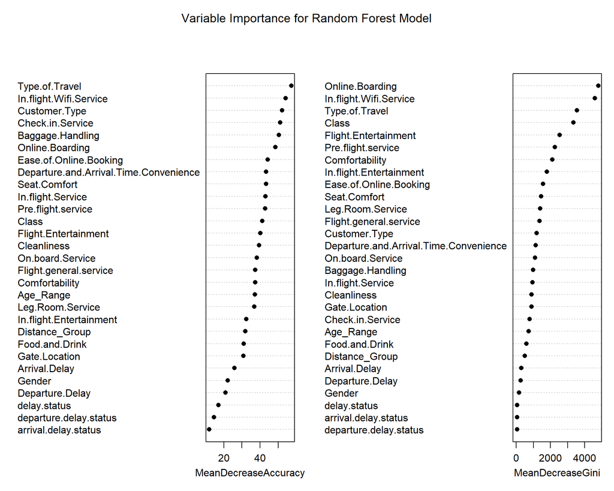

```r
# Print the Variable Importance Plot
varImpPlot(
  model.forest,
  main = "Variable Importance for Random Forest Model",
   pch = 16 # Use filled circles for data points
)
```

Based on the graph, we can see that the most important features are:  
**MDA:**

1. Type of travel
2. Inflight wifi service
3. Customers type

these features have the highest importance. This suggests that these features significantly impact the classification performance.  
Features with low or near-zero values (e.g., arrival delay status, departure delay status, delay status) contribute less and might be candidates for exclusion during model optimization.

**MDG:**

1. Online boarding
2. Inflight wifi service
3. type of travel

These features show the greatest contributions to reducing impurity.  
The features with low or near-zero values (e.g., departure delay status, arrival delay status, delay status) contribute less and considered not significant.

**Importance Evaluation on high satisfaction VS Low satisfaction**  
Next, we will try to take a look on importance in high satisfaction and low satisfaction. We will use the same method as above to evaluate the importance of each variable in high satisfaction and low satisfaction. This phase is to evaluate the importance profile on both high satisfaction and low satisfaction. The goal is to identify the most important features that contribute to high satisfaction and low satisfaction. This will help us to understand the factors that influence customer satisfaction and dissatisfaction.

**Step 1: high satisfaction variable importance evaluation**  
High satisfaction category based on data:

1. Type of travel : Business
2. Class : Business
3. Customer Type : Returning

**Notice** that in the fist plot we see non-satisfaction contributors being plotted. In the following step we will focus on possible contributors to the satisfaction by evaluating variable importance.

**Type of Travel : Business**

```r
# Subset the data on passenger with Business type of travel
data_randfor <- data_clsf_ori[ which(data_clsf_ori$Type.of.Travel == "Business"), ]
data_randfor <- data_randfor %>% select(-c(Type.of.Travel, Gender, Customer.Type, Age_Range, Distance_Group, Arrival.Delay.Duration, Departure.Delay.Duration, Flight.Distance, Age, Class))

# Split the data into 70% training and 30% testing
proportion <-  0.7
split <- initial_split(data_randfor, prop = proportion)
training <- training(split)
testing <- testing(split)

# Train the random forest model
model.forest <- randomForest::randomForest(Satisfaction ~.,
                                           data = training,
                                           ntree = 500, # how many trees should be grown?
                                           mtry = 2, # how many variables to sample at each split?
                                           replace = TRUE,
                                           importance = TRUE) # sampling of cases with or without replacement?

# Predicting on the testing data
pred.test <- predict(model.forest, testing)

# Print the confusion matrix
print("Confusion matrix for Random Forest Type of Travel Business")
```

```
## [1] "Confusion matrix for Random Forest Type of Travel Business"
```

```r
CrossTable(testing$Satisfaction, pred.test,
           prop.chisq = FALSE,
           prop.c = FALSE,
           prop.r = FALSE,
           prop.t = FALSE,
           dnn = c("Actual Satisfaction", "Predicted Satisfaction"))
```

```
##
##
##    Cell Contents
## |-------------------------|
## |                       N |
## |-------------------------|
##
##
## Total Observations in Table:  26908
##
##
##                     | Predicted Satisfaction
## Actual Satisfaction |         0 |         1 | Row Total |
## --------------------|-----------|-----------|-----------|
##                   0 |     10535 |       725 |     11260 |
## --------------------|-----------|-----------|-----------|
##                   1 |       666 |     14982 |     15648 |
## --------------------|-----------|-----------|-----------|
##        Column Total |     11201 |     15707 |     26908 |
## --------------------|-----------|-----------|-----------|
##
##
```

```r
# --- Calculate Metrics ---

# Create the confusion matrix table
conf_matrix <- table(Actual = testing$Satisfaction, Predicted = pred.test)

# Extract True Positives, True Negatives, False Positives, and False Negatives. 0 representing dissatisfaction, 1 represent satisfaction.
tp <- conf_matrix["0", "0"]
tn <- conf_matrix["1", "1"]
fp <- conf_matrix["1", "0"]
fn <- conf_matrix["0", "1"]

# Calculate metrics
accuracy <- (tp + tn) / sum(conf_matrix)
precision <- tp / (tp + fp)
recall <- tp / (tp + fn)
f1_score <- 2 * (precision * recall) / (precision + recall)

# Print metrics
cat("\nMetrics of Model:\n")
```

```
##
## Metrics of Model:
```

```r
cat("Accuracy: ", round(accuracy, 2), "\n")
```

```
## Accuracy:  0.95
```

```r
cat("Precision: ", round(precision, 2), "\n")
```

```
## Precision:  0.94
```

```r
cat("Recall: ", round(recall, 2), "\n")
```

```
## Recall:  0.94
```

```r
cat("F1-Score: ", round(f1_score, 2), "\n")
```

```
## F1-Score:  0.94
```

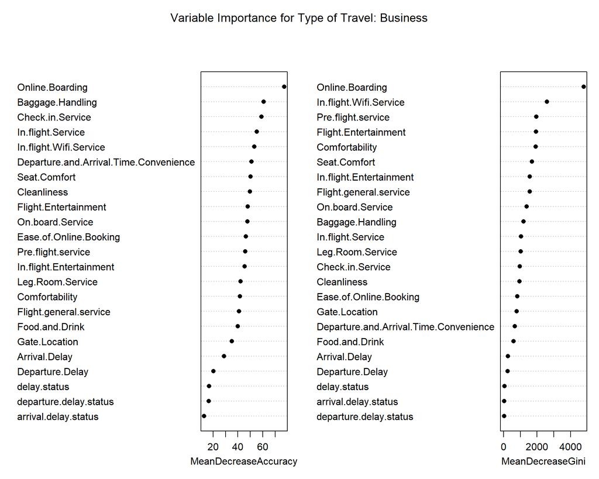

```r
# Plot the variable importance
varImpPlot(
  model.forest,
  main = "Variable Importance for Type of Travel: Business",
   pch = 16 # Use filled circles for data points
)
```

**Class: Business**

```r
# Subset the data on passenger with Business Class flight
data_randfor <- data_clsf_ori[which(data_clsf_ori$Class == "Business"),]
data_randfor <- data_randfor %>% select(-c(Type.of.Travel, Gender, Customer.Type, Age_Range, Distance_Group, Arrival.Delay.Duration, Departure.Delay.Duration, Flight.Distance, Age, Class))

# Split the data into 70% training and 30% testing
proportion <-  0.7
split <- initial_split(data_randfor, prop = proportion)
training <- training(split)
testing <- testing(split)

# Train the random forest model
model.forest <- randomForest::randomForest(Satisfaction ~.,
                                           data = training,
                                           ntree = 500, # how many trees should be grown?
                                           mtry = 2, # how many variables to sample at each split?
                                           replace = TRUE,
                                           importance = TRUE) # sampling of cases with or without replacement?

# Predicting on the testing data
pred.test <- predict(model.forest, testing)

# Print the confusion matrix
print("Confusion matrix for Random Forest Class Business")
```

```
## [1] "Confusion matrix for Random Forest Class Business"
```

```r
CrossTable(testing$Satisfaction, pred.test,
           prop.chisq = FALSE,
           prop.c = FALSE,
           prop.r = FALSE,
           prop.t = FALSE,
           dnn = c("Actual Satisfaction", "Predicted Satisfaction"))
```

```
##
##
##    Cell Contents
## |-------------------------|
## |                       N |
## |-------------------------|
##
##
## Total Observations in Table:  18648
##
##
##                     | Predicted Satisfaction
## Actual Satisfaction |         0 |         1 | Row Total |
## --------------------|-----------|-----------|-----------|
##                   0 |      5266 |       451 |      5717 |
## --------------------|-----------|-----------|-----------|
##                   1 |       275 |     12656 |     12931 |
## --------------------|-----------|-----------|-----------|
##        Column Total |      5541 |     13107 |     18648 |
## --------------------|-----------|-----------|-----------|
##
##
```

```r
# --- Calculate Metrics ---

# Create the confusion matrix table
conf_matrix <- table(Actual = testing$Satisfaction, Predicted = pred.test)

# Extract True Positives, True Negatives, False Positives, and False Negatives. 0 representing dissatisfaction, 1 represent satisfaction.
tp <- conf_matrix["0", "0"]
tn <- conf_matrix["1", "1"]
fp <- conf_matrix["1", "0"]
fn <- conf_matrix["0", "1"]

# Calculate metrics
accuracy <- (tp + tn) / sum(conf_matrix)
precision <- tp / (tp + fp)
recall <- tp / (tp + fn)
f1_score <- 2 * (precision * recall) / (precision + recall)

# Print metrics
cat("\nMetrics of Model:\n")
```

```
##
## Metrics of Model:
```

```r
cat("Accuracy: ", round(accuracy, 2), "\n")
```

```
## Accuracy:  0.96
```

```r
cat("Precision: ", round(precision, 2), "\n")
```

```
## Precision:  0.95
```

```r
cat("Recall: ", round(recall, 2), "\n")
```

```
## Recall:  0.92
```

```r
cat("F1-Score: ", round(f1_score, 2), "\n")
```

```
## F1-Score:  0.94
```

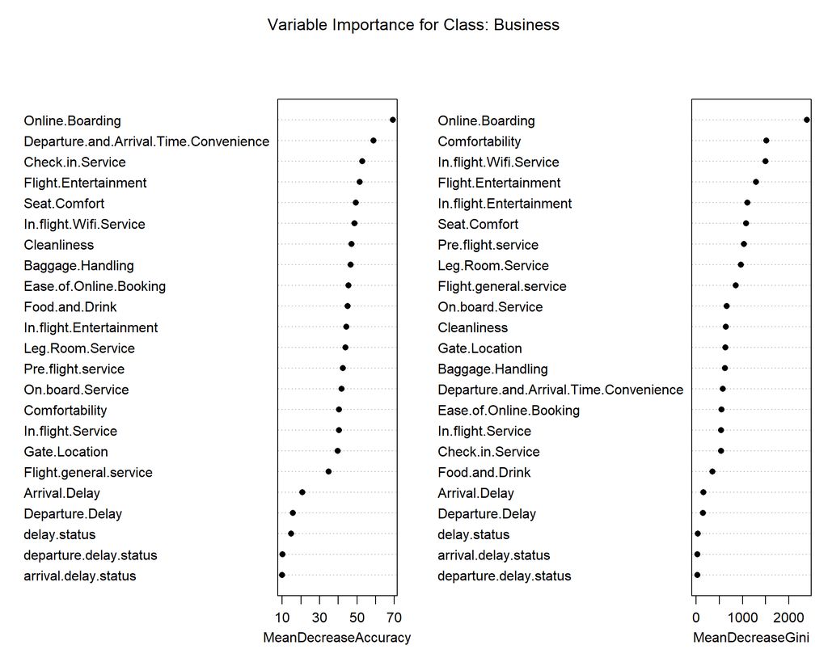

```r
# Plot the variable importance
model.forest.business <- model.forest

varImpPlot(
  model.forest.business,
  main = "Variable Importance for Class: Business",
   pch = 16 # Use filled circles for data points
)
```

**Customers Type : Returning**

```r
# Subset the data on passenger with returning customer type
data_randfor <- data_clsf_ori[ which(data_clsf_ori$Customer.Type == "Returning"), ]
data_randfor <- data_randfor %>% select(-c(Type.of.Travel, Gender, Customer.Type, Age_Range, Distance_Group, Arrival.Delay.Duration, Departure.Delay.Duration, Flight.Distance, Age, Class))

# Split the data into 70% training and 30% testing
proportion <-  0.7
split <- initial_split(data_randfor, prop = proportion)
training <- training(split)
testing <- testing(split)

# Train the random forest model
model.forest <- randomForest::randomForest(Satisfaction ~.,
                                           data = training,
                                           ntree = 500, # how many trees should be grown?
                                           mtry = 2, # how many variables to sample at each split?
                                           replace = TRUE,
                                           importance = TRUE) # sampling of cases with or without replacement?

# Predicting on the testing data
pred.test <- predict(model.forest, testing)

# Print the confusion matrix
print("Confusion matrix for Random Forest Customer Type Returning")
```

```
## [1] "Confusion matrix for Random Forest Customer Type Returning"
```

```r
CrossTable(testing$Satisfaction, pred.test,
           prop.chisq = FALSE,
           prop.c = FALSE,
           prop.r = FALSE,
           prop.t = FALSE,
           dnn = c("Actual Satisfaction", "Predicted Satisfaction"))
```

```
##
##
##    Cell Contents
## |-------------------------|
## |                       N |
## |-------------------------|
##
##
## Total Observations in Table:  31830
##
##
##                     | Predicted Satisfaction
## Actual Satisfaction |         0 |         1 | Row Total |
## --------------------|-----------|-----------|-----------|
##                   0 |     15869 |       649 |     16518 |
## --------------------|-----------|-----------|-----------|
##                   1 |      1002 |     14310 |     15312 |
## --------------------|-----------|-----------|-----------|
##        Column Total |     16871 |     14959 |     31830 |
## --------------------|-----------|-----------|-----------|
##
##
```

```r
# --- Calculate Metrics ---

# Create the confusion matrix table
conf_matrix <- table(Actual = testing$Satisfaction, Predicted = pred.test)

# Extract True Positives, True Negatives, False Positives, and False Negatives. 0 representing dissatisfaction, 1 represent satisfaction.
tp <- conf_matrix["0", "0"]
tn <- conf_matrix["1", "1"]
fp <- conf_matrix["1", "0"]
fn <- conf_matrix["0", "1"]

# Calculate metrics
accuracy <- (tp + tn) / sum(conf_matrix)
precision <- tp / (tp + fp)
recall <- tp / (tp + fn)
f1_score <- 2 * (precision * recall) / (precision + recall)

# Print metrics
cat("\nMetrics of Model:\n")
```

```
##
## Metrics of Model:
```

```r
cat("Accuracy: ", round(accuracy, 2), "\n")
```

```
## Accuracy:  0.95
```

```r
cat("Precision: ", round(precision, 2), "\n")
```

```
## Precision:  0.94
```

```r
cat("Recall: ", round(recall, 2), "\n")
```

```
## Recall:  0.96
```

```r
cat("F1-Score: ", round(f1_score, 2), "\n")
```

```
## F1-Score:  0.95
```

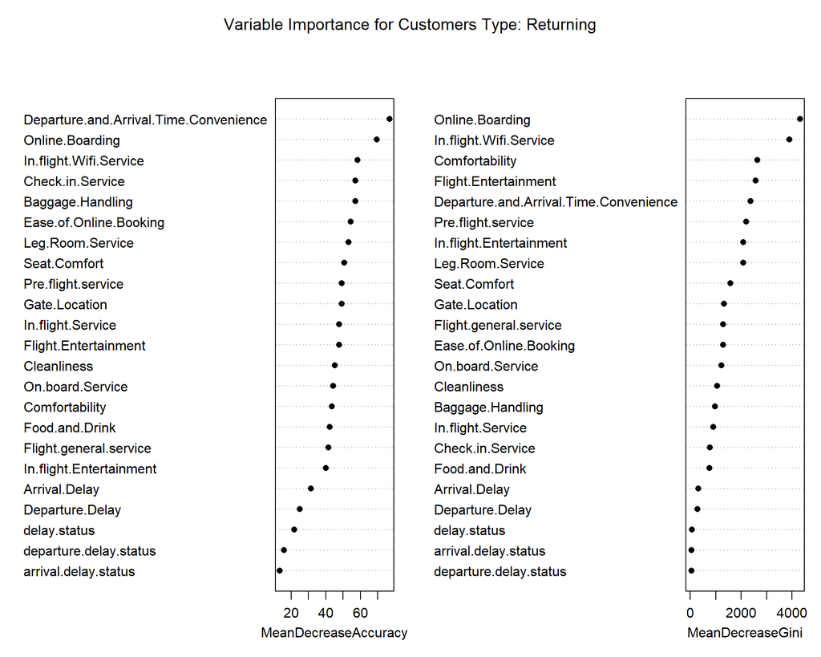

```r
varImpPlot(
  model.forest,
  main = "Variable Importance for Customers Type: Returning",
   pch = 16 # Use filled circles for data points
  )
```

**Step 2: Low satisfaction variable importance evaluation**  
Low satisfaction category based on data:

1. Type of travel : Personal
2. Class : Economy and Economy Plus
3. Customer Type : First Time

**Type of Travel: Personal**

```r
# Subset the data on passenger with Business Class flight
data_randfor <- data_clsf_ori[ which(data_clsf_ori$Type.of.Travel == "Personal"), ]
data_randfor <- data_randfor %>% select(-c(Type.of.Travel, Gender, Customer.Type, Age_Range, Distance_Group, Arrival.Delay.Duration, Departure.Delay.Duration, Flight.Distance, Age, Class))

# Split the data into 70% training and 30% testing
proportion <-  0.7
split <- initial_split(data_randfor, prop = proportion)
training <- training(split)
testing <- testing(split)

# Train the random forest model
model.forest <- randomForest::randomForest(Satisfaction ~.,
                                           data = training,
                                           ntree = 500, # how many trees should be grown?
                                           mtry = 2, # how many variables to sample at each split?
                                           replace = TRUE,
                                           importance = TRUE) # sampling of cases with or without replacement?

# Predicting on the testing data
pred.test <- predict(model.forest, testing)

# Print the confusion matrix
print("Confusion matrix for Random Forest Type of Travel Personal")
```

```
## [1] "Confusion matrix for Random Forest Type of Travel Personal"
```

```r
CrossTable(testing$Satisfaction, pred.test,
           prop.chisq = FALSE,
           prop.c = FALSE,
           prop.r = FALSE,
           prop.t = FALSE,
           dnn = c("Actual Satisfaction", "Predicted Satisfaction"))
```

```
##
##
##    Cell Contents
## |-------------------------|
## |                       N |
## |-------------------------|
##
##
## Total Observations in Table:  12057
##
##
##                     | Predicted Satisfaction
## Actual Satisfaction |         0 |         1 | Row Total |
## --------------------|-----------|-----------|-----------|
##                   0 |     10802 |         4 |     10806 |
## --------------------|-----------|-----------|-----------|
##                   1 |       485 |       766 |      1251 |
## --------------------|-----------|-----------|-----------|
##        Column Total |     11287 |       770 |     12057 |
## --------------------|-----------|-----------|-----------|
##
##
```

```r
# --- Calculate Metrics ---

# Create the confusion matrix table
conf_matrix <- table(Actual = testing$Satisfaction, Predicted = pred.test)

# Extract True Positives, True Negatives, False Positives, and False Negatives. 0 representing dissatisfaction, 1 represent satisfaction.
tp <- conf_matrix["0", "0"]
tn <- conf_matrix["1", "1"]
fp <- conf_matrix["1", "0"]
fn <- conf_matrix["0", "1"]

# Calculate metrics
accuracy <- (tp + tn) / sum(conf_matrix)
precision <- tp / (tp + fp)
recall <- tp / (tp + fn)
f1_score <- 2 * (precision * recall) / (precision + recall)

# Print metrics
cat("\nMetrics of Model:\n")
```

```
##
## Metrics of Model:
```

```r
cat("Accuracy: ", round(accuracy, 2), "\n")
```

```
## Accuracy:  0.96
```

```r
cat("Precision: ", round(precision, 2), "\n")
```

```
## Precision:  0.96
```

```r
cat("Recall: ", round(recall, 2), "\n")
```

```
## Recall:  1
```

```r
cat("F1-Score: ", round(f1_score, 2), "\n")
```

```
## F1-Score:  0.98
```

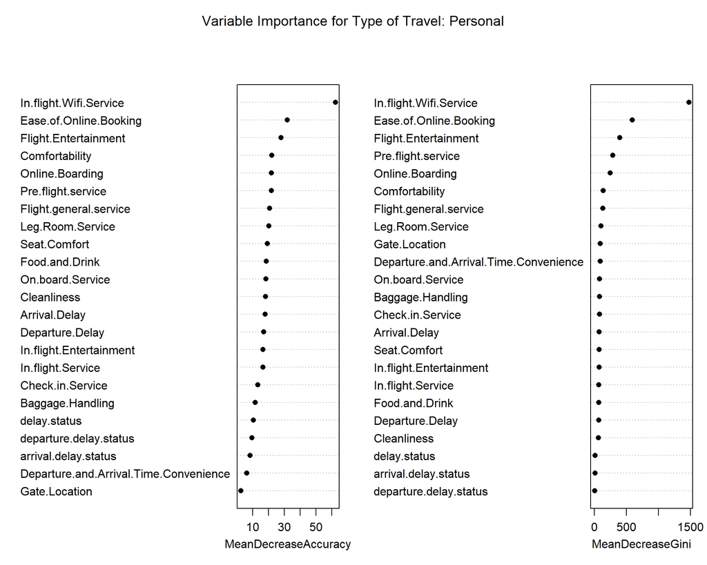

```r
# Plot the variable importance
varImpPlot(
  model.forest,
  main = "Variable Importance for Type of Travel: Personal",
   pch = 16 # Use filled circles for data points
  )
```

**Class: Economy and Economy Plus**

```r
# Subset the data on passenger with Economy and Economy Plus Class flight
data_randfor <- data_clsf_ori[ which(data_clsf_ori$Class %in% c("Economy", "Economy Plus")), ]
data_randfor <- data_randfor %>% select(-c(Type.of.Travel, Gender, Customer.Type, Age_Range, Distance_Group, Arrival.Delay.Duration, Departure.Delay.Duration, Flight.Distance, Age, Class))

# Split the data into 70% training and 30% testing
proportion <-  0.7
split <- initial_split(data_randfor, prop = proportion)
training <- training(split)
testing <- testing(split)

# Train the random forest model
model.forest <- randomForest::randomForest(Satisfaction ~.,
                                           data = training,
                                           ntree = 500, # how many trees should be grown?
                                           mtry = 2, # how many variables to sample at each split?
                                           replace = TRUE,
                                           importance = TRUE) # sampling of cases with or without replacement?

# Predicting on the testing data
pred.test <- predict(model.forest, testing)

# Print the confusion matrix
print("Confusion matrix for Random Forest Type of Class Economy and Economy Plus")
```

```
## [1] "Confusion matrix for Random Forest Type of Class Economy and Economy Plus"
```

```r
CrossTable(testing$Satisfaction, pred.test,
           prop.chisq = FALSE,
           prop.c = FALSE,
           prop.r = FALSE,
           prop.t = FALSE,
           dnn = c("Actual Satisfaction", "Predicted Satisfaction"))
```

```
##
##
##    Cell Contents
## |-------------------------|
## |                       N |
## |-------------------------|
##
##
## Total Observations in Table:  20316
##
##
##                     | Predicted Satisfaction
## Actual Satisfaction |         0 |         1 | Row Total |
## --------------------|-----------|-----------|-----------|
##                   0 |     16062 |       279 |     16341 |
## --------------------|-----------|-----------|-----------|
##                   1 |      1049 |      2926 |      3975 |
## --------------------|-----------|-----------|-----------|
##        Column Total |     17111 |      3205 |     20316 |
## --------------------|-----------|-----------|-----------|
##
##
```

```r
# --- Calculate Metrics ---

# Create the confusion matrix table
conf_matrix <- table(Actual = testing$Satisfaction, Predicted = pred.test)

# Extract True Positives, True Negatives, False Positives, and False Negatives. 0 representing dissatisfaction, 1 represent satisfaction.
tp <- conf_matrix["0", "0"]
tn <- conf_matrix["1", "1"]
fp <- conf_matrix["1", "0"]
fn <- conf_matrix["0", "1"]

# Calculate metrics
accuracy <- (tp + tn) / sum(conf_matrix)
precision <- tp / (tp + fp)
recall <- tp / (tp + fn)
f1_score <- 2 * (precision * recall) / (precision + recall)

# Print metrics
cat("\nMetrics of Model:\n")
```

```
##
## Metrics of Model:
```

```r
cat("Accuracy: ", round(accuracy, 2), "\n")
```

```
## Accuracy:  0.93
```

```r
cat("Precision: ", round(precision, 2), "\n")
```

```
## Precision:  0.94
```

```r
cat("Recall: ", round(recall, 2), "\n")
```

```
## Recall:  0.98
```

```r
cat("F1-Score: ", round(f1_score, 2), "\n")
```

```
## F1-Score:  0.96
```

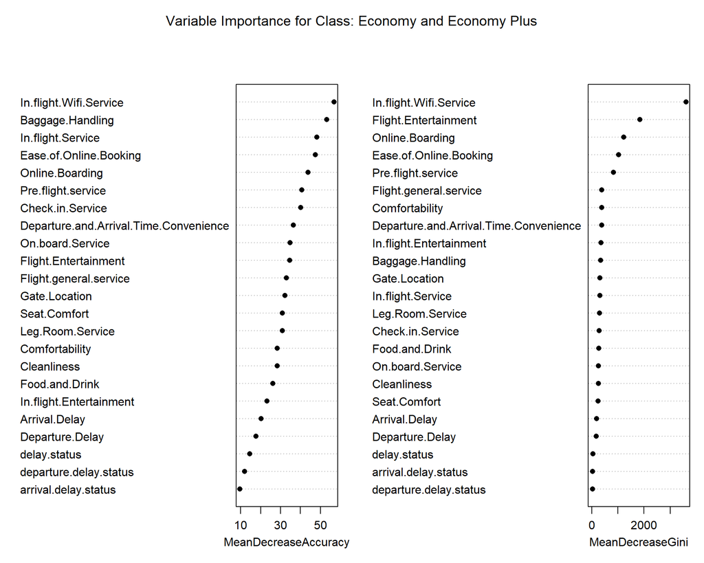

```r
# Plot the variable importance

model.forest.economy <- model.forest

varImpPlot(
  model.forest.economy,
  main = "Variable Importance for Class: Economy and Economy Plus",
   pch = 16 # Use filled circles for data points
  )
```

**Customers Type : First time**

```r
# Subset the data on passenger with Business Class flight
data_randfor <- data_clsf_ori[ which(data_clsf_ori$Customer.Type %in% "First-time"), ]
data_randfor <- data_randfor %>% select(-c(Type.of.Travel, Gender, Customer.Type, Age_Range, Distance_Group, Arrival.Delay.Duration, Departure.Delay.Duration, Flight.Distance, Age, Class))

# Split the data into 70% training and 30% testing
proportion <-  0.7
split <- initial_split(data_randfor, prop = proportion)
training <- training(split)
testing <- testing(split)

# Train the random forest model
model.forest <- randomForest::randomForest(Satisfaction ~.,
                                           data = training,
                                           ntree = 500, # how many trees should be grown?
                                           mtry = 2, # how many variables to sample at each split?
                                           replace = TRUE,
                                           importance = TRUE) # sampling of cases with or without replacement?

# Predicting on the testing data
pred.test <- predict(model.forest, testing)

# Print the confusion matrix
print("Confusion matrix for Random Forest Type of Customer Type First Time")
```

```
## [1] "Confusion matrix for Random Forest Type of Customer Type First Time"
```

```r
CrossTable(testing$Satisfaction, pred.test,
           prop.chisq = FALSE,
           prop.c = FALSE,
           prop.r = FALSE,
           prop.t = FALSE,
           dnn = c("Actual Satisfaction", "Predicted Satisfaction"))
```

```
##
##
##    Cell Contents
## |-------------------------|
## |                       N |
## |-------------------------|
##
##
## Total Observations in Table:  7134
##
##
##                     | Predicted Satisfaction
## Actual Satisfaction |         0 |         1 | Row Total |
## --------------------|-----------|-----------|-----------|
##                   0 |      5105 |       315 |      5420 |
## --------------------|-----------|-----------|-----------|
##                   1 |       225 |      1489 |      1714 |
## --------------------|-----------|-----------|-----------|
##        Column Total |      5330 |      1804 |      7134 |
## --------------------|-----------|-----------|-----------|
##
##
```

```r
# --- Calculate Metrics ---

# Create the confusion matrix table
conf_matrix <- table(Actual = testing$Satisfaction, Predicted = pred.test)

# Extract True Positives, True Negatives, False Positives, and False Negatives. 0 representing dissatisfaction, 1 represent satisfaction.
tp <- conf_matrix["0", "0"]
tn <- conf_matrix["1", "1"]
fp <- conf_matrix["1", "0"]
fn <- conf_matrix["0", "1"]

# Calculate metrics
accuracy <- (tp + tn) / sum(conf_matrix)
precision <- tp / (tp + fp)
recall <- tp / (tp + fn)
f1_score <- 2 * (precision * recall) / (precision + recall)

# Print metrics
cat("\nMetrics of Model:\n")
```

```
##
## Metrics of Model:
```

```r
cat("Accuracy: ", round(accuracy, 2), "\n")
```

```
## Accuracy:  0.92
```

```r
cat("Precision: ", round(precision, 2), "\n")
```

```
## Precision:  0.96
```

```r
cat("Recall: ", round(recall, 2), "\n")
```

```
## Recall:  0.94
```

```r
cat("F1-Score: ", round(f1_score, 2), "\n")
```

```
## F1-Score:  0.95
```

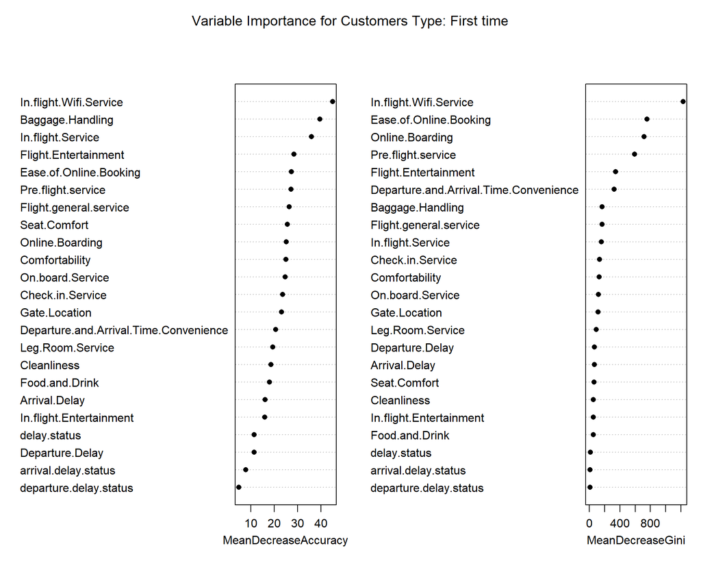

```r
# Plot the variable importance
varImpPlot(
  model.forest,
  main = "Variable Importance for Customers Type: First time",
   pch = 16 # Use filled circles for data points
  )
```

Let’s evaluate the variable importance result. The comparison between Top MDA on high satisfaction and low satisfaction customers will help to understand what parameters matter to define their satisfaction level. Below is the comparison between high satisfaction and low satisfaction customers based on the top MDA value. The table below shows the top 3 parameters that matter to high satisfaction and low satisfaction customers. The table is divided into 3 categories, which are: Type of Travel, Class, and Customers Type.

[output not shown]

The table above shows that the top 3 parameters that matter to high satisfaction customers are different from the low satisfaction customers.  
**Overall Insight** For high satisfaction, the recurring themes are efficiency, convenience, and timeliness. Business travel and returning customers emphasize this the most. For low satisfaction, comfort, accessibility, and entertainment take precedence, especially for personal travel and first-time customers.

**Let’s take a look on each group** For **Type of Travel**, high satisfaction is driven by business travelers who value efficiency and convenience, particularly through services like online boarding, check-in service, and baggage handling. In contrast, low satisfaction among personal travelers stems from a focus on comfort and accessibility, with preferences for in-flight WiFi service, ease of online booking, and flight entertainment.

For **Customer Type**, returning customers experience high satisfaction when services like departure and arrival time convenience, online boarding, and in-flight WiFi service cater to their need for smooth and timely travel. Meanwhile, low satisfaction among first-time customers arises from their focus on pleasant first-time experiences, valuing in-flight WiFi service, baggage handling, and in-flight service.

However, we can see the convergence of the results between high satisfaction and low satisfaction customers.

For business-class passengers, the key contributors to high satisfaction—such as Online Boarding, Check-in Service, and Departure and Arrival Time Convenience—show consistency across categories (e.g., travel type and class). This indicates that factors driving satisfaction are aligned, supporting the idea that a single model for the **Business segment** is sufficient.

For economy-class passengers (including Economy Plus), dissatisfaction revolves around similar factors like In-flight WiFi Service, Ease of Online Booking, and Baggage Handling across different categories. This suggests shared pain points that can be effectively captured in a unified model for the **Economy segment.**

This convergence implies that a single model for each segment (Business and Economy) can effectively address the unique needs of passengers, enhancing satisfaction and reducing dissatisfaction.

Reducing the models from six to two avoids over-complication and overfitting while ensuring that the key insights remain actionable. As per data, it is shown that the segmentation between Business and Economy is quite competitive, around 52% of economy combined (including economy plus) and 48% of business segment. **Next we will perform logistic regression with the two main classification of Business segment and Economy segment**.

Logistic regression works well when models are representative and not overly complex. Consolidating into two models ensures each has enough data points and avoids redundancy, improving the reliability of conclusions (Landwehr, 2003).

## 3.3 Classification Method : Logistic Regression

Since this project aims to predict between binary class values (satisfied and dissatisfied), logistic regression will be used for this classification task (Hosmer, 2013). This method also allows us to identify the impact of each variable to the likelihood of passenger satisfaction, as well as see the probability values associated. In this subchapter, we will discuss step-by-step our process of preparing the regression model as well as interpret our findings.

### 3.3.1 Model Preparation

Firstly, we will prepare the dataset by applying a train-test split of 70:30. We will use seed value to get replicable results.

```r
set.seed(46748756)

# Treat ordinal variables as numeric and exclude specified variables
data_numeric <- data %>%
  mutate(across(where(is.numeric), ~ scale(.) %>% as.numeric())) %>% # Normalize all numeric columns
  mutate(across(c(Ease.of.Online.Booking, Check.in.Service, Online.Boarding,
                  Gate.Location, On.board.Service, Seat.Comfort, Leg.Room.Service,
                  Cleanliness, Food.and.Drink, In.flight.Service, In.flight.Wifi.Service,
                  In.flight.Entertainment, Departure.and.Arrival.Time.Convenience),
                as.numeric)) %>% # Treat ordinal variables as numeric
  subset(select = -c(ID, Gender, Age, Customer.Type, Type.of.Travel, Flight.Distance,
                     Age_Range, Distance_Group, Age.log, Flight.Distance.log.z, Age.log.z,
                     Departure.Delay.Duration, Arrival.Delay.Duration,
                     Arrival.Delay.Duration.log, Arrival.Delay.Duration.log.z,
                     Departure.Delay.Duration.log, Departure.Delay.Duration.log.z,
                     Flight.Distance.log, Flight.general.service, Flight.Entertainment,
                     Pre.flight.service, Comfortability)) # Exclude unnecessary columns

# Cleaning columns with zero scores that exist in small quantities
cols_to_clean <- c("On.board.Service", "Check.in.Service", "Seat.Comfort",
                   "In.flight.Service", "Gate.Location", "Cleanliness",
                   "In.flight.Entertainment", "Flight.general.service",
                   "Flight.Entertainment", "Pre.flight.service", "Comfortability")

for (col in colnames(data_numeric)) {
  if (is.factor(data_numeric[[col]])) {
    data_numeric[[col]] <- droplevels(data_numeric[[col]])
  }
}

# Split the dataset into training and testing sets
proportion <- 0.7
split <- initial_split(data_numeric, prop = proportion)
training <- training(split)
testing <- testing(split)

# Encode Satisfaction as binary (0 = Neutral or Dissatisfied, 1 = Satisfied)
training$Satisfaction <- ifelse(training$Satisfaction == "Satisfied", 1, 0)
training$Satisfaction <- factor(training$Satisfaction, levels = c(0, 1))
testing$Satisfaction <- ifelse(testing$Satisfaction == "Satisfied", 1, 0)
testing$Satisfaction <- factor(testing$Satisfaction, levels = c(0, 1))

# Split the dataset by class
business_class_data <- training %>% filter(Class == "Business") %>% select(-Class)
economy_class_data <- training %>% filter(Class %in% c("Economy", "Economy Plus")) %>% select(-Class)
```

### 3.3.2 Training Logistic Regression Model

Once we have determined the training and testing set, we will train the model in the code chunk below.

- **`glm()`**: Fits a generalized linear model.
- **`Satisfaction ~ .`**: Specifies the formula, where `Satisfaction` is the dependent variable, and all other variables in the `training` dataset are independent variables.
- **`data = training`**: Uses the `training` dataset to train the model.
- **`family = "binomial"`**: Specifies that the model is a logistic regression, as the dependent variable (`Satisfaction`) is binary.

Three models will be trained, the first one including all the data which we will use to compare with the classification model and as a baseline, the second and third models are used to identify differing characteristics between passengers of business class and economy class.

```r
# Using all data
model_log <- glm(Satisfaction ~.,
               data = training, family = "binomial")
summary(model_log)
```

```
##
## Call:
## glm(formula = Satisfaction ~ ., family = "binomial", data = training)
##
## Coefficients:
##                                         Estimate Std. Error z value Pr(>|z|)
## (Intercept)                             0.693852   0.087553   7.925 2.28e-15
## ClassEconomy                           -1.974505   0.020946 -94.267  < 2e-16
## ClassEconomy Plus                      -1.637136   0.038009 -43.073  < 2e-16
## Departure.Delay                        -0.021395   0.019005  -1.126 0.260263
## Arrival.Delay                          -0.212458   0.020424 -10.402  < 2e-16
## Departure.and.Arrival.Time.Convenience -0.311226   0.011580 -26.876  < 2e-16
## Ease.of.Online.Booking                 -0.313674   0.015839 -19.803  < 2e-16
## Check.in.Service                        0.254215   0.010419  24.400  < 2e-16
## Online.Boarding                         0.900171   0.013130  68.559  < 2e-16
## Gate.Location                           0.072149   0.011428   6.313 2.73e-10
## On.board.Service                        0.291264   0.012733  22.874  < 2e-16
## Seat.Comfort                            0.074421   0.014254   5.221 1.78e-07
## Leg.Room.Service                        0.362498   0.010884  33.307  < 2e-16
## Cleanliness                             0.137373   0.015231   9.019  < 2e-16
## Food.and.Drink                         -0.076609   0.013663  -5.607 2.06e-08
## In.flight.Service                      -0.010724   0.013366  -0.802 0.422388
## In.flight.Wifi.Service                  0.659874   0.015054  43.832  < 2e-16
## In.flight.Entertainment                 0.430326   0.017741  24.256  < 2e-16
## Baggage.Handling                       -0.008109   0.012712  -0.638 0.523528
## departure.delay.statusOn Time          -0.013733   0.088283  -0.156 0.876381
## arrival.delay.statusOn Time            -0.283374   0.082711  -3.426 0.000612
## delay.statusOn-time                     0.086109   0.082161   1.048 0.294615
##
## (Intercept)                            ***
## ClassEconomy                           ***
## ClassEconomy Plus                      ***
## Departure.Delay
## Arrival.Delay                          ***
## Departure.and.Arrival.Time.Convenience ***
## Ease.of.Online.Booking                 ***
## Check.in.Service                       ***
## Online.Boarding                        ***
## Gate.Location                          ***
## On.board.Service                       ***
## Seat.Comfort                           ***
## Leg.Room.Service                       ***
## Cleanliness                            ***
## Food.and.Drink                         ***
## In.flight.Service
## In.flight.Wifi.Service                 ***
## In.flight.Entertainment                ***
## Baggage.Handling
## departure.delay.statusOn Time
## arrival.delay.statusOn Time            ***
## delay.statusOn-time
## ---
## Signif. codes:  0 '***' 0.001 '**' 0.01 '*' 0.05 '.' 0.1 ' ' 1
##
## (Dispersion parameter for binomial family taken to be 1)
##
##     Null deviance: 124480  on 90915  degrees of freedom
## Residual deviance:  70471  on 90894  degrees of freedom
## AIC: 70515
##
## Number of Fisher Scoring iterations: 5
```

```r
# Using business class data
model_log_business <- glm(Satisfaction ~.,
               data = business_class_data, family = "binomial")
summary(model_log_business)
```

```
##
## Call:
## glm(formula = Satisfaction ~ ., family = "binomial", data = business_class_data)
##
## Coefficients:
##                                        Estimate Std. Error z value Pr(>|z|)
## (Intercept)                             0.49174    0.12867   3.822 0.000133 ***
## Departure.Delay                        -0.01919    0.02848  -0.674 0.500501
## Arrival.Delay                          -0.12311    0.03038  -4.052 5.07e-05 ***
## Departure.and.Arrival.Time.Convenience -0.22248    0.02136 -10.417  < 2e-16 ***
## Ease.of.Online.Booking                 -0.05109    0.02399  -2.130 0.033187 *
## Check.in.Service                        0.39452    0.01645  23.979  < 2e-16 ***
## Online.Boarding                         1.17422    0.02000  58.719  < 2e-16 ***
## Gate.Location                           0.16810    0.01906   8.819  < 2e-16 ***
## On.board.Service                        0.49964    0.02352  21.247  < 2e-16 ***
## Seat.Comfort                            0.23169    0.02138  10.837  < 2e-16 ***
## Leg.Room.Service                        0.60883    0.01929  31.565  < 2e-16 ***
## Cleanliness                             0.31658    0.02054  15.410  < 2e-16 ***
## Food.and.Drink                         -0.07270    0.01874  -3.880 0.000104 ***
## In.flight.Service                       0.03287    0.02537   1.296 0.195121
## In.flight.Wifi.Service                 -0.03804    0.02291  -1.660 0.096872 .
## In.flight.Entertainment                 0.32550    0.02711  12.006  < 2e-16 ***
## Baggage.Handling                        0.07772    0.02378   3.268 0.001084 **
## departure.delay.statusOn Time          -0.05704    0.13039  -0.437 0.661804
## arrival.delay.statusOn Time            -0.01409    0.12160  -0.116 0.907781
## delay.statusOn-time                     0.02335    0.12018   0.194 0.845913
## ---
## Signif. codes:  0 '***' 0.001 '**' 0.01 '*' 0.05 '.' 0.1 ' ' 1
##
## (Dispersion parameter for binomial family taken to be 1)
##
##     Null deviance: 53635  on 43550  degrees of freedom
## Residual deviance: 30662  on 43531  degrees of freedom
## AIC: 30702
##
## Number of Fisher Scoring iterations: 5
```

```r
# Using economy class data
model_log_economy <- glm(Satisfaction ~.,
               data = economy_class_data, family = "binomial")
summary(model_log_economy)
```

```
##
## Call:
## glm(formula = Satisfaction ~ ., family = "binomial", data = economy_class_data)
##
## Coefficients:
##                                        Estimate Std. Error z value Pr(>|z|)
## (Intercept)                            -1.62069    0.13850 -11.702  < 2e-16 ***
## Departure.Delay                        -0.03094    0.02881  -1.074 0.282804
## Arrival.Delay                          -0.29904    0.03187  -9.384  < 2e-16 ***
## Departure.and.Arrival.Time.Convenience -0.10305    0.01533  -6.722 1.79e-11 ***
## Ease.of.Online.Booking                 -0.43259    0.02308 -18.746  < 2e-16 ***
## Check.in.Service                        0.13489    0.01426   9.457  < 2e-16 ***
## Online.Boarding                         0.09172    0.02296   3.995 6.48e-05 ***
## Gate.Location                           0.12542    0.01610   7.788 6.80e-15 ***
## On.board.Service                        0.11871    0.01548   7.670 1.72e-14 ***
## Seat.Comfort                            0.00305    0.02069   0.147 0.882793
## Leg.Room.Service                        0.01037    0.01437   0.722 0.470349
## Cleanliness                            -0.05648    0.02745  -2.058 0.039630 *
## Food.and.Drink                         -0.05046    0.02587  -1.950 0.051126 .
## In.flight.Service                      -0.10488    0.01606  -6.532 6.49e-11 ***
## In.flight.Wifi.Service                  1.78531    0.02680  66.605  < 2e-16 ***
## In.flight.Entertainment                 0.36072    0.02777  12.991  < 2e-16 ***
## Baggage.Handling                       -0.09477    0.01565  -6.056 1.39e-09 ***
## departure.delay.statusOn Time           0.10458    0.14000   0.747 0.455078
## arrival.delay.statusOn Time            -0.45919    0.13425  -3.420 0.000625 ***
## delay.statusOn-time                     0.04723    0.13308   0.355 0.722644
## ---
## Signif. codes:  0 '***' 0.001 '**' 0.01 '*' 0.05 '.' 0.1 ' ' 1
##
## (Dispersion parameter for binomial family taken to be 1)
##
##     Null deviance: 46888  on 47364  degrees of freedom
## Residual deviance: 33704  on 47345  degrees of freedom
## AIC: 33744
##
## Number of Fisher Scoring iterations: 5
```

The results above show the relationship between the predictor variables and the target variables. We are interested in determining the significant predictors of the model. In the next subchapter, we will delve deeper into the interpretation of these results.

### 3.3.3 Interpretation of the Model

**Interpret the coefficient**

The code chunk below is used to calculate the exponentiated coefficients (also known as odds ratios) from the logistic regression model `model_log`.

```r
exp(coef(model_log))
```

```
##                            (Intercept)                           ClassEconomy
##                              2.0014093                              0.1388300
##                      ClassEconomy Plus                        Departure.Delay
##                              0.1945364                              0.9788323
##                          Arrival.Delay Departure.and.Arrival.Time.Convenience
##                              0.8085939                              0.7325483
##                 Ease.of.Online.Booking                       Check.in.Service
##                              0.7307571                              1.2894493
##                        Online.Boarding                          Gate.Location
##                              2.4600244                              1.0748155
##                       On.board.Service                           Seat.Comfort
##                              1.3381181                              1.0772601
##                       Leg.Room.Service                            Cleanliness
##                              1.4369144                              1.1472565
##                         Food.and.Drink                      In.flight.Service
##                              0.9262521                              0.9893337
##                 In.flight.Wifi.Service                In.flight.Entertainment
##                              1.9345480                              1.5377594
##                       Baggage.Handling          departure.delay.statusOn Time
##                              0.9919234                              0.9863608
##            arrival.delay.statusOn Time                    delay.statusOn-time
##                              0.7532378                              1.0899248
```

```r
exp(coef(model_log_business))
```

```
##                            (Intercept)                        Departure.Delay
##                              1.6351615                              0.9809942
##                          Arrival.Delay Departure.and.Arrival.Time.Convenience
##                              0.8841658                              0.8005311
##                 Ease.of.Online.Booking                       Check.in.Service
##                              0.9501978                              1.4836760
##                        Online.Boarding                          Gate.Location
##                              3.2356212                              1.1830514
##                       On.board.Service                           Seat.Comfort
##                              1.6481293                              1.2607240
##                       Leg.Room.Service                            Cleanliness
##                              1.8382818                              1.3724229
##                         Food.and.Drink                      In.flight.Service
##                              0.9298816                              1.0334137
##                 In.flight.Wifi.Service                In.flight.Entertainment
##                              0.9626737                              1.3847219
##                       Baggage.Handling          departure.delay.statusOn Time
##                              1.0808190                              0.9445597
##            arrival.delay.statusOn Time                    delay.statusOn-time
##                              0.9860133                              1.0236298
```

```r
exp(coef(model_log_economy))
```

```
##                            (Intercept)                        Departure.Delay
##                              0.1977616                              0.9695323
##                          Arrival.Delay Departure.and.Arrival.Time.Convenience
##                              0.7415275                              0.9020802
##                 Ease.of.Online.Booking                       Check.in.Service
##                              0.6488246                              1.1444064
##                        Online.Boarding                          Gate.Location
##                              1.0960570                              1.1336255
##                       On.board.Service                           Seat.Comfort
##                              1.1260374                              1.0030543
##                       Leg.Room.Service                            Cleanliness
##                              1.0104277                              0.9450813
##                         Food.and.Drink                      In.flight.Service
##                              0.9507933                              0.9004355
##                 In.flight.Wifi.Service                In.flight.Entertainment
##                              5.9614579                              1.4343658
##                       Baggage.Handling          departure.delay.statusOn Time
##                              0.9095844                              1.1102404
##            arrival.delay.statusOn Time                    delay.statusOn-time
##                              0.6317942                              1.0483665
```

The odds ratio indicates how the odds of the target variable (e.g., `Satisfaction` being “Satisfied”) change with a one-unit increase in the predictor variable, holding all other variables constant.

- **Odds Ratio > 1**: The predictor increases the odds of satisfaction.
- **Odds Ratio < 1**: The predictor decreases the odds of satisfaction.
- **Odds Ratio = 1**: The predictor has no effect on satisfaction.

**Visualizing the coefficients**

Below we will visualize the magnitude of each predictor’s effect on the target variable, along with their 95% confidence intervals. The X axis represents the coefficient estimates in log-odds, horizontal lines around each point represent the confidence intervals (at 95% level).

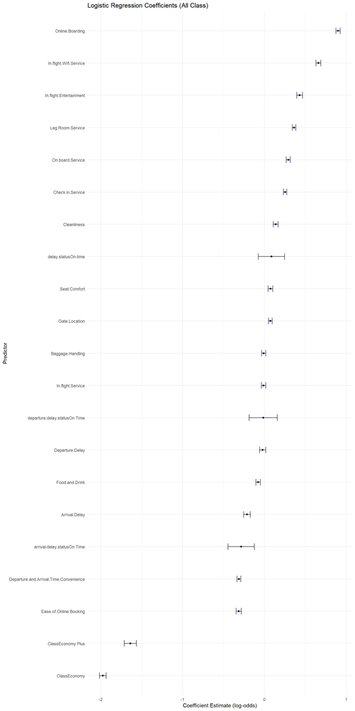

```r
coefs <- summary(model_log)$coefficients

coef_df <- data.frame(
  Variable = rownames(coefs),
  Estimate = coefs[, "Estimate"],
  StdError = coefs[, "Std. Error"],
  p_value = coefs[, "Pr(>|z|)"]
)

# Remove intercept for clarity
coef_df <- coef_df[coef_df$Variable != "(Intercept)", ]

# Plot using ggplot2
ggplot(coef_df, aes(x = reorder(Variable, Estimate), y = Estimate)) +
  geom_point(color = "darkblue") +
  geom_errorbar(aes(ymin = Estimate - 1.96 * StdError,
                    ymax = Estimate + 1.96 * StdError), width = 0.2) +
  coord_flip() +
  labs(title = "Logistic Regression Coefficients (All Class)",
       x = "Predictor",
       y = "Coefficient Estimate (log-odds)") +
  theme_minimal()
```

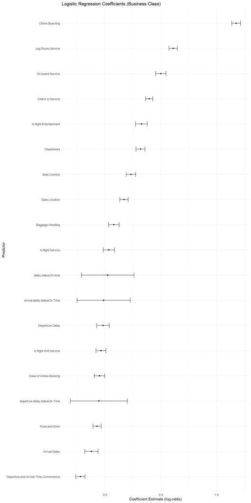

```r
coefs <- summary(model_log_business)$coefficients

coef_df <- data.frame(
  Variable = rownames(coefs),
  Estimate = coefs[, "Estimate"],
  StdError = coefs[, "Std. Error"],
  p_value = coefs[, "Pr(>|z|)"]
)

# Remove intercept for clarity
coef_df <- coef_df[coef_df$Variable != "(Intercept)", ]

# Plot using ggplot2

ggplot(coef_df, aes(x = reorder(Variable, Estimate), y = Estimate)) +
  geom_point(color = "darkblue") +
  geom_errorbar(aes(ymin = Estimate - 1.96 * StdError,
                    ymax = Estimate + 1.96 * StdError), width = 0.2) +
  coord_flip() +
  labs(title = "Logistic Regression Coefficients (Business Class)",
       x = "Predictor",
       y = "Coefficient Estimate (log-odds)") +
  theme_minimal()
```

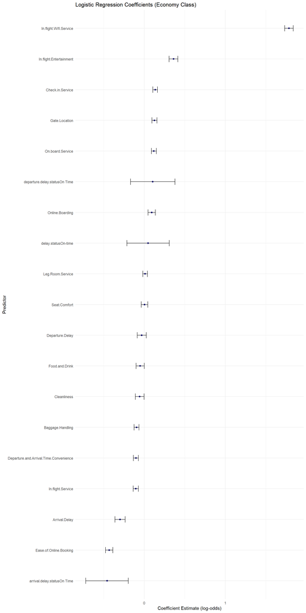

```r
coefs <- summary(model_log_economy)$coefficients
coef_df <- data.frame(
  Variable = rownames(coefs),
  Estimate = coefs[, "Estimate"],
  StdError = coefs[, "Std. Error"],
  p_value = coefs[, "Pr(>|z|)"]
)
# Remove intercept for clarity
coef_df <- coef_df[coef_df$Variable != "(Intercept)", ]

# Plot using ggplot2
ggplot(coef_df, aes(x = reorder(Variable, Estimate), y = Estimate)) +
  geom_point(color = "darkblue") +
  geom_errorbar(aes(ymin = Estimate - 1.96 * StdError,
                    ymax = Estimate + 1.96 * StdError), width = 0.2) +
  coord_flip() +
  labs(title = "Logistic Regression Coefficients (Economy Class)",
       x = "Predictor",
       y = "Coefficient Estimate (log-odds)") +
  theme_minimal()
```

In the general model, we can see that economy class has the largest negative coefficient. While this may be good for enhancing overall accuracy, it may lead to non-operationalizable results in the business context as Economy and Business class passengers have different pain points. In the models for economy and business class, we see that passengers for each class have different value preferences. Next, we will take a look at the Z-values to see the significant predictors.

**Interpreting Z Value**

```r
model_summary_business <- summary(model_log_business)
model_summary_economy <- summary(model_log_economy)

# Extract z-values and convert to data frame
z_df_business <- data.frame(
  Variable_business = rownames(model_summary_business$coefficients),
  Z_value_business = model_summary_business$coefficients[, "z value"]
)

# Remove intercept
z_df_economy <- data.frame(
  Variable_economy = rownames(model_summary_economy$coefficients),
  Z_value_economy = model_summary_economy$coefficients[, "z value"]
)

# Remove intercept
z_df_business <- subset(z_df_business, Variable_business != "(Intercept)")
z_df_economy <- subset(z_df_economy, Variable_economy != "(Intercept)")
```

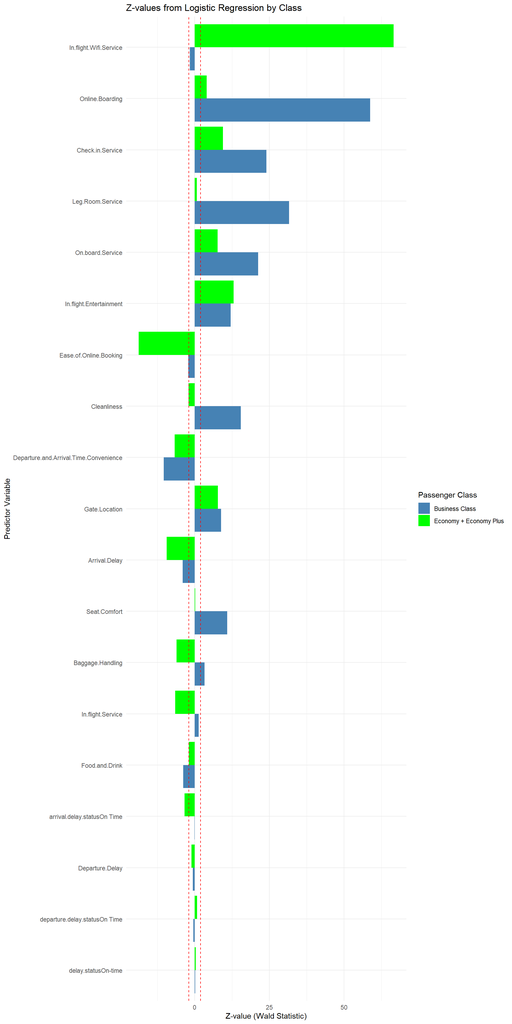

```r
# Combine the two dataframes into one for plotting
z_df_business$Group <- "Business Class"
z_df_economy$Group <- "Economy + Economy Plus"

# Rename columns for consistency
z_df_business <- z_df_business %>% rename(Variable = Variable_business, Z_value = Z_value_business)
z_df_economy <- z_df_economy %>% rename(Variable = Variable_economy, Z_value = Z_value_economy)

# Combine the dataframes
z_df_combined <- rbind(z_df_business, z_df_economy)


# Plot using ggplot2

ggplot(z_df_combined, aes(x = reorder(Variable, abs(Z_value)), y = Z_value, fill = Group)) +
  geom_col(position = "dodge") + # Side-by-side bars for each group
  geom_hline(yintercept = c(-1.96, 1.96), linetype = "dashed", color = "red") + # 95% significance threshold
  coord_flip() +
  labs(title = "Z-values from Logistic Regression by Class",
       x = "Predictor Variable",
       y = "Z-value (Wald Statistic)",
       fill = "Passenger Class") + # Add legend for the groups
  theme_minimal() +
  scale_fill_manual(values = c("Business Class" = "steelblue", "Economy + Economy Plus" = "green"))
```

The Z**-**values represent the Wald statistics for each predictor in the logistic regression model. These values are used to test the null hypothesis that the coefficient for a predictor is equal to zero (Agresti, 2018).

- Positive Z-values indicate a **positive** relationship to the likelihood of satisfaction.
- Negative Z-values indicate a **negative** relationship to the likelihood of satisfaction.

For a 95% confidence level, the threshold of a statistically significant Z-value is **|Z| > 1.96** which is indicated by the dotted red line in the plot. We can see from the visualization above that the strongest negative predictor for business class is departure time and arrival convenience, while for economy class is ease of online booking. The strongest positive predictor for business class is online boarding, and for economy class it is in-flight WiFi. Next, we will evaluate the model.

### 3.3.4 Model Evaluation

The first calculation method that we will use to evaluate the logistic regression model is the confusion matrix. It is is a table that describes the performance of a classification model by comparing the predicted values with the actual values. It provides insight into how well the model is performing and helps identify any misclassifications. The result will display how many variables are correctly predicted as true positive and true negative as well as wrongly classified as false positive and false negative. The confusion matrix also calculate the accuracy, sensitivity, and specificity of the model. The accuracy is the proportion of true results (both true positives and true negatives) among the total number of cases examined. Sensitivity is the proportion of true positives that are correctly identified, while specificity is the proportion of true negatives that are correctly classified.

We will use the confusion matrix to evaluate the logistic regression model that includes all the data (business and economy class passengers), dubbed All Class. The logistic regression model for each economy class and business class is only used as a separator to provide the significant variables that affect the satisfaction level of each class.

```r
all_testing <- testing
pred.test <- predict(model_log, newdata = all_testing, type = "response")

# Convert to class labels
pred.test.result <- ifelse(pred.test > 0.5, "Satisfied", "Neutral or Dissatisfied")
all_testing$Satisfaction <- ifelse(testing$Satisfaction == 1, "Satisfied", "Neutral or Dissatisfied")
all_testing$Satisfaction <- factor(all_testing$Satisfaction, levels = c("Satisfied", "Neutral or Dissatisfied"))
pred.test.result <- factor(pred.test.result, levels = c("Satisfied", "Neutral or Dissatisfied"))

# Confusion matrix
confusionMatrix(pred.test.result, all_testing$Satisfaction)
```

```
## Confusion Matrix and Statistics
##
##                          Reference
## Prediction                Satisfied Neutral or Dissatisfied
##   Satisfied                   13652                    2715
##   Neutral or Dissatisfied      3258                   19339
##
##                Accuracy : 0.8467
##                  95% CI : (0.8431, 0.8503)
##     No Information Rate : 0.566
##     P-Value [Acc > NIR] : < 2.2e-16
##
##                   Kappa : 0.6868
##
##  Mcnemar's Test P-Value : 2.333e-12
##
##             Sensitivity : 0.8073
##             Specificity : 0.8769
##          Pos Pred Value : 0.8341
##          Neg Pred Value : 0.8558
##              Prevalence : 0.4340
##          Detection Rate : 0.3504
##    Detection Prevalence : 0.4201
##       Balanced Accuracy : 0.8421
##
##        'Positive' Class : Satisfied
##
```

**Interpret ROC and AUC**

Another quantified way to evaluate the model is to use the ROC curve and Area Under the Curve (AUC) value. The ROC curve is a graphical representation of the true positive rate (sensitivity) against the false positive rate (1 - specificity) at various threshold settings. AUC provides a single measure of overall model performance, with values ranging from 0 to 1. If the AUC value is closer to 1, the more accurate the model’s prediction is. AUC value of 0.5 indicates that the model has no identified pattern of guessing, which is essentially the same as random guessing. Meanwhile, AUC value of 0 means that the model is completely wrong in its predictions.

We will now look at the ROC curve for the combined model (economy and business class) and its AUC value.

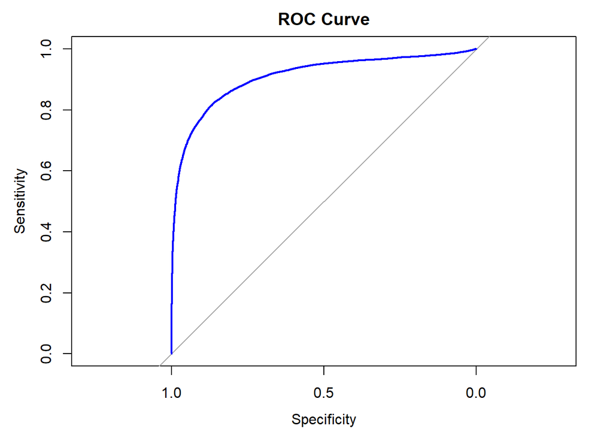

```r
# Running the model for all data
all_testing <- testing
pred.test <- predict(model_log, newdata = testing, type = "response")

# ROC curve and AUC
roc_obj <- roc(testing$Satisfaction, pred.test)
plot(roc_obj, col = "blue", main = "ROC Curve")
```

```r
auc(roc_obj)
```

```
## Area under the curve: 0.9085
```

The ROC curve of All Class aboves shows that the model quickly reaches the value close to 1 in its initial phase, which indicates that the model has a good accuracy number. This is confirmed by the AUC value of 0.91, a value that is close to 1 and considered a good model.

### 3.3.5 Improving Model Performance

**Using significant variables only**

Before we try several methods to improve the performance, we will display the summary of All Class model to see the AIC value. AIC (Akaike Information Criterion) is a measure of the relative quality of a statistical model for a given dataset. It is used to compare different models and select the best one. The lower the AIC value, the better the model fits the data. In this case, we will use AIC to compare the performance of different models.

```r
summary(model_log)
```

```
##
## Call:
## glm(formula = Satisfaction ~ ., family = "binomial", data = training)
##
## Coefficients:
##                                         Estimate Std. Error z value Pr(>|z|)
## (Intercept)                             0.693852   0.087553   7.925 2.28e-15
## ClassEconomy                           -1.974505   0.020946 -94.267  < 2e-16
## ClassEconomy Plus                      -1.637136   0.038009 -43.073  < 2e-16
## Departure.Delay                        -0.021395   0.019005  -1.126 0.260263
## Arrival.Delay                          -0.212458   0.020424 -10.402  < 2e-16
## Departure.and.Arrival.Time.Convenience -0.311226   0.011580 -26.876  < 2e-16
## Ease.of.Online.Booking                 -0.313674   0.015839 -19.803  < 2e-16
## Check.in.Service                        0.254215   0.010419  24.400  < 2e-16
## Online.Boarding                         0.900171   0.013130  68.559  < 2e-16
## Gate.Location                           0.072149   0.011428   6.313 2.73e-10
## On.board.Service                        0.291264   0.012733  22.874  < 2e-16
## Seat.Comfort                            0.074421   0.014254   5.221 1.78e-07
## Leg.Room.Service                        0.362498   0.010884  33.307  < 2e-16
## Cleanliness                             0.137373   0.015231   9.019  < 2e-16
## Food.and.Drink                         -0.076609   0.013663  -5.607 2.06e-08
## In.flight.Service                      -0.010724   0.013366  -0.802 0.422388
## In.flight.Wifi.Service                  0.659874   0.015054  43.832  < 2e-16
## In.flight.Entertainment                 0.430326   0.017741  24.256  < 2e-16
## Baggage.Handling                       -0.008109   0.012712  -0.638 0.523528
## departure.delay.statusOn Time          -0.013733   0.088283  -0.156 0.876381
## arrival.delay.statusOn Time            -0.283374   0.082711  -3.426 0.000612
## delay.statusOn-time                     0.086109   0.082161   1.048 0.294615
##
## (Intercept)                            ***
## ClassEconomy                           ***
## ClassEconomy Plus                      ***
## Departure.Delay
## Arrival.Delay                          ***
## Departure.and.Arrival.Time.Convenience ***
## Ease.of.Online.Booking                 ***
## Check.in.Service                       ***
## Online.Boarding                        ***
## Gate.Location                          ***
## On.board.Service                       ***
## Seat.Comfort                           ***
## Leg.Room.Service                       ***
## Cleanliness                            ***
## Food.and.Drink                         ***
## In.flight.Service
## In.flight.Wifi.Service                 ***
## In.flight.Entertainment                ***
## Baggage.Handling
## departure.delay.statusOn Time
## arrival.delay.statusOn Time            ***
## delay.statusOn-time
## ---
## Signif. codes:  0 '***' 0.001 '**' 0.01 '*' 0.05 '.' 0.1 ' ' 1
##
## (Dispersion parameter for binomial family taken to be 1)
##
##     Null deviance: 124480  on 90915  degrees of freedom
## Residual deviance:  70471  on 90894  degrees of freedom
## AIC: 70515
##
## Number of Fisher Scoring iterations: 5
```

Above we see that the AIC value is 70515. We will use this value as a baseline to compare base model performance to the improved model.

p-value < 0.05

```r
training_signif <- training %>% subset(select = -c(Departure.Delay, Arrival.Delay,
                                                  In.flight.Wifi.Service, Food.and.Drink,
                                                  In.flight.Entertainment))

model_log_signif <- glm(Satisfaction ~.,
               data = training_signif, family = "binomial")

summary(model_log_signif)
```

```
##
## Call:
## glm(formula = Satisfaction ~ ., family = "binomial", data = training_signif)
##
## Coefficients:
##                                         Estimate Std. Error z value Pr(>|z|)
## (Intercept)                             0.010841   0.052650   0.206  0.83686
## ClassEconomy                           -1.755103   0.019696 -89.110  < 2e-16
## ClassEconomy Plus                      -1.344139   0.035599 -37.758  < 2e-16
## Departure.and.Arrival.Time.Convenience -0.322795   0.011270 -28.642  < 2e-16
## Ease.of.Online.Booking                  0.095265   0.012690   7.507 6.06e-14
## Check.in.Service                        0.156285   0.009794  15.957  < 2e-16
## Online.Boarding                         1.018701   0.012650  80.532  < 2e-16
## Gate.Location                           0.096880   0.011142   8.695  < 2e-16
## On.board.Service                        0.381017   0.011987  31.785  < 2e-16
## Seat.Comfort                            0.153872   0.013076  11.767  < 2e-16
## Leg.Room.Service                        0.426763   0.010513  40.594  < 2e-16
## Cleanliness                             0.323758   0.012485  25.932  < 2e-16
## In.flight.Service                       0.086797   0.012565   6.908 4.92e-12
## Baggage.Handling                        0.079139   0.012223   6.474 9.52e-11
## departure.delay.statusOn Time           0.045220   0.065564   0.690  0.49038
## arrival.delay.statusOn Time             0.211742   0.067566   3.134  0.00173
## delay.statusOn-time                     0.231205   0.079101   2.923  0.00347
##
## (Intercept)
## ClassEconomy                           ***
## ClassEconomy Plus                      ***
## Departure.and.Arrival.Time.Convenience ***
## Ease.of.Online.Booking                 ***
## Check.in.Service                       ***
## Online.Boarding                        ***
## Gate.Location                          ***
## On.board.Service                       ***
## Seat.Comfort                           ***
## Leg.Room.Service                       ***
## Cleanliness                            ***
## In.flight.Service                      ***
## Baggage.Handling                       ***
## departure.delay.statusOn Time
## arrival.delay.statusOn Time            **
## delay.statusOn-time                    **
## ---
## Signif. codes:  0 '***' 0.001 '**' 0.01 '*' 0.05 '.' 0.1 ' ' 1
##
## (Dispersion parameter for binomial family taken to be 1)
##
##     Null deviance: 124480  on 90915  degrees of freedom
## Residual deviance:  73595  on 90899  degrees of freedom
## AIC: 73629
##
## Number of Fisher Scoring iterations: 5
```

We saw a slight increase in AIC value to 73629. Because the value is higher, it indicates that the model with filtered variables is actually not better than the base model for All Class model.

Next, we will evaluate the new model through the Confusion Matrix:

```r
pred.test <- predict(model_log_signif, newdata = testing, type = "response")

# Convert to class labels
pred.test.result <- ifelse(pred.test > 0.5, "Satisfied", "Neutral or Dissatisfied")
all_testing$Satisfaction <- ifelse(testing$Satisfaction == 1, "Satisfied", "Neutral or Dissatisfied")
all_testing$Satisfaction <- factor(all_testing$Satisfaction, levels = c("Satisfied", "Neutral or Dissatisfied"))
pred.test.result <- factor(pred.test.result, levels = c("Satisfied", "Neutral or Dissatisfied"))

confusionMatrix(pred.test.result, all_testing$Satisfaction)
```

```
## Confusion Matrix and Statistics
##
##                          Reference
## Prediction                Satisfied Neutral or Dissatisfied
##   Satisfied                   13048                    2750
##   Neutral or Dissatisfied      3862                   19304
##
##                Accuracy : 0.8303
##                  95% CI : (0.8265, 0.834)
##     No Information Rate : 0.566
##     P-Value [Acc > NIR] : < 2.2e-16
##
##                   Kappa : 0.6519
##
##  Mcnemar's Test P-Value : < 2.2e-16
##
##             Sensitivity : 0.7716
##             Specificity : 0.8753
##          Pos Pred Value : 0.8259
##          Neg Pred Value : 0.8333
##              Prevalence : 0.4340
##          Detection Rate : 0.3349
##    Detection Prevalence : 0.4055
##       Balanced Accuracy : 0.8235
##
##        'Positive' Class : Satisfied
##
```

From the result above, the accuracy and sensitivity of the model with filtered variables experience a noticeable drop in accuracy and sensitivity value, while the specificity value is essentially the same. Again, this shows that the new model is not better than the base model.

Another method to evaluate the improvement attempt we want to use is using the ANOVA test to compare the two models. The ANOVA test is a statistical method used to compare the means of two or more groups. In this case, we will use the ANOVA test to compare the performance of the base model and the model with filtered variables. The ANOVA test will help us determine whether there is a significant difference between the two models. This is to ensure that the base model is indeed better than the model with filtered variables as indicated from the summary function and confusion matrix.

ANOVA test :

```r
anova(model_log, model_log_signif, test="Chisq")
```

```
## Analysis of Deviance Table
##
## Model 1: Satisfaction ~ Class + Departure.Delay + Arrival.Delay + Departure.and.Arrival.Time.Convenience +
##     Ease.of.Online.Booking + Check.in.Service + Online.Boarding +
##     Gate.Location + On.board.Service + Seat.Comfort + Leg.Room.Service +
##     Cleanliness + Food.and.Drink + In.flight.Service + In.flight.Wifi.Service +
##     In.flight.Entertainment + Baggage.Handling + departure.delay.status +
##     arrival.delay.status + delay.status
## Model 2: Satisfaction ~ Class + Departure.and.Arrival.Time.Convenience +
##     Ease.of.Online.Booking + Check.in.Service + Online.Boarding +
##     Gate.Location + On.board.Service + Seat.Comfort + Leg.Room.Service +
##     Cleanliness + In.flight.Service + Baggage.Handling + departure.delay.status +
##     arrival.delay.status + delay.status
##   Resid. Df Resid. Dev Df Deviance  Pr(>Chi)
## 1     90894      70471
## 2     90899      73595 -5  -3123.9 < 2.2e-16 ***
## ---
## Signif. codes:  0 '***' 0.001 '**' 0.01 '*' 0.05 '.' 0.1 ' ' 1
```

The ANOVA test result above shows that the p-value is very close to 0, which indicates that there is a significant difference between the two models. This means that the base model is indeed better than the model with filtered variables, confirming the result from summary function and the confusion matrix.

**Using High Information Value Variables**

The second way to try improving the model is using the variables with High Information Value. Using the `Information` library, we can calculate the Information Value (IV) of each variable in the dataset. The IV is a measure of how much information a variable provides about the target variable. In other words, Information Value is a measure of the predictive capability of variables. Higher IV indicates that the variable is more predictive of the target variable. We will use this information to filter the variables and create a new model.

```r
# Drop columns that contain "Date" or have more than one class
filtered_data <- data %>%
  select(-Satisfaction) %>%
  select(where(~ all(!grepl("Date|POSIX", class(.))) & length(class(.)) == 1))

# Convert to numeric where possible
clean_data <- filtered_data %>%
  mutate(across(everything(), ~ if (all(!is.na(as.numeric(as.character(.x))))) {
    as.numeric(as.character(.x))
  } else {
    .x
  }))
# Add binary target
clean_data$Satisfaction <- ifelse(data$Satisfaction == "Satisfied", 1, 0)

# Run IV analysis
iv_results <- create_infotables(data = clean_data, y = "Satisfaction", bins = 10)

# View summary
iv_results$Summary
```

```
##                                  Variable           IV
## 21                 In.flight.Wifi.Service 2.0833389363
## 13                        Online.Boarding 1.9339052615
## 6                                   Class 1.1383984517
## 30                   Flight.Entertainment 1.1298223814
## 31                     Pre.flight.service 1.0841313806
## 5                          Type.of.Travel 1.0574626990
## 32                         Comfortability 1.0010029920
## 22                In.flight.Entertainment 0.8014862420
## 29                 Flight.general.service 0.6657437380
## 16                           Seat.Comfort 0.6618862470
## 17                       Leg.Room.Service 0.5036077388
## 15                       On.board.Service 0.4795120472
## 18                            Cleanliness 0.4461078635
## 11                 Ease.of.Online.Booking 0.4204269370
```

[output cut: 24 more lines]

We will use the IV evaluation results to filter out the variables with insignificant value, with the threshold of the IV is 0.3. Everything below that value is considered weak predictor and will be excluded in the improvement model. We will use this information to filter the variables and create a new model, then evaluates the new model using confusion matrix and ANOVA test.

```r
iv_data <- data %>%
  mutate(across(where(is.numeric), ~ scale(.) %>% as.numeric())) %>% # Normalize all numeric columns
  mutate(across(c(Ease.of.Online.Booking, Check.in.Service, Online.Boarding,
                  Gate.Location, On.board.Service, Seat.Comfort, Leg.Room.Service,
                  Cleanliness, Food.and.Drink, In.flight.Service, In.flight.Wifi.Service,
                  In.flight.Entertainment, Departure.and.Arrival.Time.Convenience),
                as.numeric)) %>% # Treat ordinal variables as numeric
  subset(select = -c(ID, Gender, Gate.Location, Arrival.Delay, Departure.and.Arrival.Time.Convenience,
                     delay.status, arrival.delay.status, Departure.Delay, departure.delay.status,
                     Age_Range, Distance_Group, Age.log, Flight.Distance.log.z, Age.log.z,
                     Departure.Delay.Duration, Arrival.Delay.Duration,
                     Arrival.Delay.Duration.log, Arrival.Delay.Duration.log.z,
                     Departure.Delay.Duration.log, Departure.Delay.Duration.log.z,
                     Comfortability, Flight.general.service, Flight.Entertainment,
                     Pre.flight.service)) # Exclude unnecessary columns

# Cleaning columns with zero scores that exist in small quantities
cols_to_clean <- c("On.board.Service", "Check.in.Service", "Seat.Comfort",
                   "In.flight.Service", "Gate.Location", "Cleanliness",
                   "In.flight.Entertainment")

for (col in colnames(iv_data)) {
  if (is.factor(iv_data[[col]])) {
    iv_data[[col]] <- droplevels(iv_data[[col]])
  }
}

# Split the dataset into training and testing sets
proportion <- 0.7
split <- initial_split(iv_data, prop = proportion)
iv_training <- training(split)
iv_testing <- testing(split)

# Encode Satisfaction as binary (0 = Neutral or Dissatisfied, 1 = Satisfied)
iv_training$Satisfaction <- ifelse(iv_training$Satisfaction == "Satisfied", 1, 0)
iv_training$Satisfaction <- factor(iv_training$Satisfaction, levels = c(0, 1))
iv_testing$Satisfaction <- ifelse(iv_testing$Satisfaction == "Satisfied", 1, 0)
iv_testing$Satisfaction <- factor(iv_testing$Satisfaction, levels = c(0, 1))

# Using all data
model_log_iv <- glm(Satisfaction ~.,
               data = iv_training, family = "binomial")
summary(model_log_iv)
```

```
##
## Call:
## glm(formula = Satisfaction ~ ., family = "binomial", data = iv_training)
##
## Coefficients:
##                         Estimate Std. Error z value Pr(>|z|)
## (Intercept)             -0.84267    0.02682 -31.418  < 2e-16 ***
## Age                     -0.14300    0.01142 -12.519  < 2e-16 ***
## Customer.TypeReturning   1.96623    0.03112  63.182  < 2e-16 ***
## Type.of.TravelPersonal  -2.83130    0.03296 -85.911  < 2e-16 ***
## ClassEconomy            -0.72308    0.02705 -26.734  < 2e-16 ***
## ClassEconomy Plus       -0.83349    0.04362 -19.106  < 2e-16 ***
## Flight.Distance          0.12881    0.02640   4.880 1.06e-06 ***
## Ease.of.Online.Booking  -0.29710    0.01449 -20.509  < 2e-16 ***
## Check.in.Service         0.39566    0.01147  34.487  < 2e-16 ***
## Online.Boarding          0.82182    0.01421  57.823  < 2e-16 ***
## On.board.Service         0.38075    0.01392  27.345  < 2e-16 ***
## Seat.Comfort             0.07716    0.01561   4.945 7.63e-07 ***
## Leg.Room.Service         0.33727    0.01190  28.338  < 2e-16 ***
## Cleanliness              0.28085    0.01679  16.731  < 2e-16 ***
## Food.and.Drink          -0.01809    0.01494  -1.211    0.226
## In.flight.Service        0.17144    0.01499  11.441  < 2e-16 ***
## In.flight.Wifi.Service   0.51777    0.01596  32.447  < 2e-16 ***
## In.flight.Entertainment  0.08013    0.02012   3.982 6.82e-05 ***
## Baggage.Handling         0.13806    0.01431   9.646  < 2e-16 ***
## Flight.Distance.log     -0.16646    0.02533  -6.571 5.01e-11 ***
## ---
## Signif. codes:  0 '***' 0.001 '**' 0.01 '*' 0.05 '.' 0.1 ' ' 1
##
## (Dispersion parameter for binomial family taken to be 1)
##
##     Null deviance: 124406  on 90915  degrees of freedom
## Residual deviance:  61552  on 90896  degrees of freedom
## AIC: 61592
##
## Number of Fisher Scoring iterations: 5
```

```r
# Modelling
pred.test <- predict(model_log_iv, newdata = iv_testing, type = "response")

# Convert to class labels
pred.test.result <- ifelse(pred.test > 0.5, "Satisfied", "Neutral or Dissatisfied")
iv_testing$Satisfaction <- ifelse(iv_testing$Satisfaction == 1, "Satisfied", "Neutral or Dissatisfied")
iv_testing$Satisfaction <- factor(iv_testing$Satisfaction, levels = c("Satisfied", "Neutral or Dissatisfied"))
pred.test.result <- factor(pred.test.result, levels = c("Satisfied", "Neutral or Dissatisfied"))

# Confusion matrix
confusionMatrix(pred.test.result, iv_testing$Satisfaction)
```

```
## Confusion Matrix and Statistics
##
##                          Reference
## Prediction                Satisfied Neutral or Dissatisfied
##   Satisfied                   14268                    2102
##   Neutral or Dissatisfied      2780                   19814
##
##                Accuracy : 0.8747
##                  95% CI : (0.8714, 0.878)
##     No Information Rate : 0.5625
##     P-Value [Acc > NIR] : < 2.2e-16
##
##                   Kappa : 0.7443
##
##  Mcnemar's Test P-Value : < 2.2e-16
##
##             Sensitivity : 0.8369
##             Specificity : 0.9041
##          Pos Pred Value : 0.8716
##          Neg Pred Value : 0.8770
##              Prevalence : 0.4375
##          Detection Rate : 0.3662
##    Detection Prevalence : 0.4201
##       Balanced Accuracy : 0.8705
##
##        'Positive' Class : Satisfied
##
```

The new model with high information value variables shows a noticeable decrease in AIC value to 61591. This indicates that the model with high information value variables is better than the base model. The accuracy, sensitivity, and specificity values are also experiencing significant increase from the base model. This shows that there is a strong evidence that the new model with high information value variables are better than the base model.

Using the ANOVA test :

```r
anova(model_log, model_log_iv, test="Chisq")
```

```
## Analysis of Deviance Table
##
## Model 1: Satisfaction ~ Class + Departure.Delay + Arrival.Delay + Departure.and.Arrival.Time.Convenience +
##     Ease.of.Online.Booking + Check.in.Service + Online.Boarding +
##     Gate.Location + On.board.Service + Seat.Comfort + Leg.Room.Service +
##     Cleanliness + Food.and.Drink + In.flight.Service + In.flight.Wifi.Service +
##     In.flight.Entertainment + Baggage.Handling + departure.delay.status +
##     arrival.delay.status + delay.status
## Model 2: Satisfaction ~ Age + Customer.Type + Type.of.Travel + Class +
##     Flight.Distance + Ease.of.Online.Booking + Check.in.Service +
##     Online.Boarding + On.board.Service + Seat.Comfort + Leg.Room.Service +
##     Cleanliness + Food.and.Drink + In.flight.Service + In.flight.Wifi.Service +
##     In.flight.Entertainment + Baggage.Handling + Flight.Distance.log
##   Resid. Df Resid. Dev Df Deviance Pr(>Chi)
## 1     90894      70471
## 2     90896      61552 -2   8919.4
```

**Adjusting Threshold**

Although the High Information Value method already shows a better result than the base model, we want to check with other methods to see whether further improvement is possible. The third method that we will use to improve the model performance is by adjusting the threshold value. The default threshold value is 0.5, which means that if the predicted probability is greater than 0.5, the model will classify it as “Satisfied”. However, we can adjust this threshold value to see if it improves the model performance. Based on the ROC curve, we can see that the optimal threshold value is actually around 0.468, not 0.5.

```r
coords(roc_obj, "best", ret = "threshold")
```

```
##   threshold
## 1 0.4684071
```

Now, we will run the confusion matrix again of the base model using the new threshold value of 0.468.

```r
all_testing <- testing
pred.test <- predict(model_log, newdata = testing, type = "response")

# Convert to class labels

pred.test.result <- ifelse(pred.test > 0.5, "Satisfied", "Neutral or Dissatisfied")
pred.test.result <- ifelse(pred.test > 0.4684071, "Satisfied", "Neutral or Dissatisfied")
all_testing$Satisfaction <- ifelse(testing$Satisfaction == 1, "Satisfied", "Neutral or Dissatisfied")
all_testing$Satisfaction <- factor(all_testing$Satisfaction, levels = c("Satisfied", "Neutral or Dissatisfied"))
pred.test.result <- factor(pred.test.result, levels = c("Satisfied", "Neutral or Dissatisfied"))

confusionMatrix(pred.test.result, all_testing$Satisfaction)
```

```
## Confusion Matrix and Statistics
##
##                          Reference
## Prediction                Satisfied Neutral or Dissatisfied
##   Satisfied                   13910                    3041
##   Neutral or Dissatisfied      3000                   19013
##
##                Accuracy : 0.845
##                  95% CI : (0.8413, 0.8485)
##     No Information Rate : 0.566
##     P-Value [Acc > NIR] : <2e-16
##
##                   Kappa : 0.6845
##
##  Mcnemar's Test P-Value : 0.6068
##
##             Sensitivity : 0.8226
##             Specificity : 0.8621
##          Pos Pred Value : 0.8206
##          Neg Pred Value : 0.8637
##              Prevalence : 0.4340
##          Detection Rate : 0.3570
##    Detection Prevalence : 0.4350
##       Balanced Accuracy : 0.8424
##
##        'Positive' Class : Satisfied
##
```

The new threshold value indicates a slight increase in sensitivity value, while the specificity value decrease for about 1% than the previous model. Meanwhile, the accuracy score is relatively unchanged. This mixed result shows that the new threshold value method is not significantly better than the previous model.

**Dimensionality Reduction**

The last method that we will use to try improving the predictor model is by using PCA (Principal Component Analysis). PCA is a statistical technique used to reduce the dimensionality of a dataset while preserving as much variance as possible. It transforms the original variables into a new set of uncorrelated variables called principal components. The first few principal components capture most of the variance in the data, allowing us to reduce the number of variables while retaining important information.

```r
training_pca <- training %>%
  select(-Satisfaction) %>%
  mutate(across(everything(), ~ if (all(!is.na(as.numeric(as.character(.x)))))
    as.numeric(as.character(.x)) else .x)) %>%
  select(where(is.numeric)) %>%
  scale(center = TRUE, scale = TRUE)
pca_results <- prcomp(training_pca)
summary(pca_results)
```

```
## Importance of components:
##                           PC1    PC2    PC3     PC4     PC5     PC6     PC7
## Standard deviation     1.9477 1.5418 1.4732 1.20525 1.03200 0.97398 0.83440
## Proportion of Variance 0.2371 0.1486 0.1356 0.09079 0.06656 0.05929 0.04351
## Cumulative Proportion  0.2371 0.3857 0.5213 0.61210 0.67867 0.73796 0.78147
##                            PC8     PC9   PC10   PC11    PC12   PC13    PC14
## Standard deviation     0.73899 0.73086 0.7178 0.6835 0.60679 0.5741 0.54143
## Proportion of Variance 0.03413 0.03338 0.0322 0.0292 0.02301 0.0206 0.01832
## Cumulative Proportion  0.81560 0.84899 0.8812 0.9104 0.93340 0.9540 0.97232
##                           PC15    PC16
## Standard deviation     0.50500 0.43345
## Proportion of Variance 0.01594 0.01174
## Cumulative Proportion  0.98826 1.00000
```

In this case, the PCA reached more than 90% of the variance with only 11 components. Now we can reduce the dimensionality of dataset and see if it improves the model performance.

```r
pca_data <- as.data.frame(pca_results$x[, 1:11])
pca_data$Satisfaction <- training$Satisfaction

model_log_pca <- glm(Satisfaction ~.,
               data = pca_data, family = "binomial")

summary(model_log_pca)
```

```
##
## Call:
## glm(formula = Satisfaction ~ ., family = "binomial", data = pca_data)
##
## Coefficients:
##              Estimate Std. Error z value Pr(>|z|)
## (Intercept) -0.468796   0.009028 -51.929  < 2e-16 ***
## PC1          0.831238   0.005850 142.098  < 2e-16 ***
## PC2          0.018038   0.005626   3.206  0.00135 **
## PC3          0.054495   0.005960   9.143  < 2e-16 ***
## PC4         -0.121774   0.007364 -16.536  < 2e-16 ***
## PC5         -0.842573   0.009278 -90.815  < 2e-16 ***
## PC6         -0.206166   0.008907 -23.146  < 2e-16 ***
## PC7         -0.121376   0.010210 -11.888  < 2e-16 ***
## PC8         -0.146755   0.012010 -12.219  < 2e-16 ***
## PC9          0.246372   0.011987  20.553  < 2e-16 ***
## PC10         0.543329   0.012231  44.421  < 2e-16 ***
## PC11        -0.058352   0.012756  -4.574 4.78e-06 ***
## ---
## Signif. codes:  0 '***' 0.001 '**' 0.01 '*' 0.05 '.' 0.1 ' ' 1
##
## (Dispersion parameter for binomial family taken to be 1)
##
##     Null deviance: 124480  on 90915  degrees of freedom
## Residual deviance:  81803  on 90904  degrees of freedom
## AIC: 81827
##
## Number of Fisher Scoring iterations: 5
```

```r
train_center <- attr(training_pca, "scaled:center")
train_scale  <- attr(training_pca, "scaled:scale")

# 1. Convert test data to numeric and scale
test_pca_scaled <- testing %>%
  mutate(across(everything(), ~ if (all(!is.na(as.numeric(as.character(.x)))))
    as.numeric(as.character(.x)) else NA_real_)) %>%  # forces fallback to numeric NA
  select(all_of(names(train_center))) %>%
  mutate(across(everything(), as.numeric)) %>%  # ensures everything is numeric
  scale(center = train_center, scale = train_scale)
# 2. Apply PCA transformation
test_pca <- as.data.frame(predict(pca_results, newdata = test_pca_scaled)[, 1:11])

# 3. Add target variable
test_pca$Satisfaction <- testing$Satisfaction

# 4. Predict using the model trained on PCA components
pred.test <- predict(model_log_pca, newdata = test_pca, type = "response")

# Convert to class labels
pred.test.result <- ifelse(pred.test > 0.5, "Satisfied", "Neutral or Dissatisfied")
test_pca$Satisfaction <- ifelse(test_pca$Satisfaction == 1, "Satisfied", "Neutral or Dissatisfied")
test_pca$Satisfaction <- factor(test_pca$Satisfaction, levels = c("Satisfied", "Neutral or Dissatisfied"))
pred.test.result <- factor(pred.test.result, levels = c("Satisfied", "Neutral or Dissatisfied"))

confusionMatrix(pred.test.result, test_pca$Satisfaction)
```

```
## Confusion Matrix and Statistics
##
##                          Reference
## Prediction                Satisfied Neutral or Dissatisfied
##   Satisfied                   12995                    3454
##   Neutral or Dissatisfied      3915                   18600
##
##                Accuracy : 0.8109
##                  95% CI : (0.807, 0.8148)
##     No Information Rate : 0.566
##     P-Value [Acc > NIR] : < 2.2e-16
##
##                   Kappa : 0.6138
##
##  Mcnemar's Test P-Value : 8.386e-08
##
##             Sensitivity : 0.7685
##             Specificity : 0.8434
##          Pos Pred Value : 0.7900
##          Neg Pred Value : 0.8261
##              Prevalence : 0.4340
##          Detection Rate : 0.3335
##    Detection Prevalence : 0.4222
##       Balanced Accuracy : 0.8059
##
##        'Positive' Class : Satisfied
##
```

# 4 Interpretation

## 4.1 Result Visualization

As a recap, we will again show the customer segmentation based on class using the chunk below. Economy and Economy Plus passengers are again grouped into Economy Combined, just as the model.

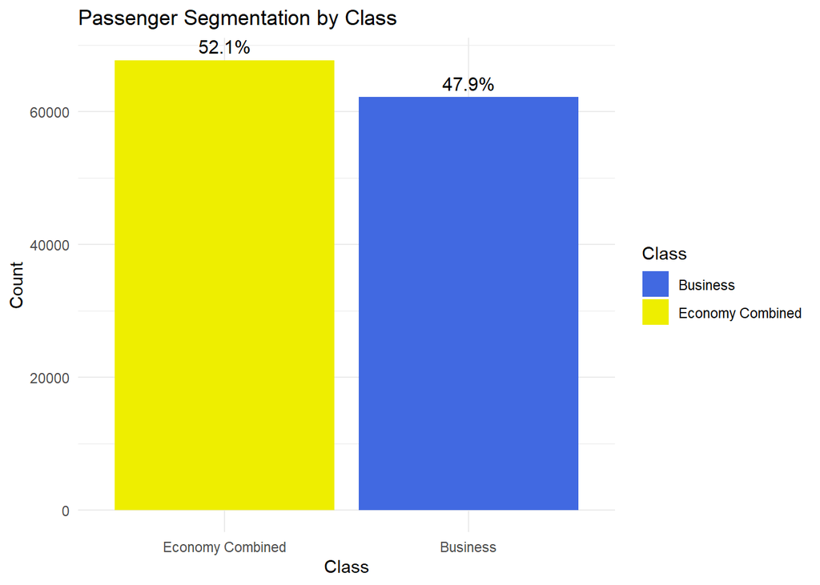

```r
# Combine Economy and Economy Plus into a single category for visualization
class_summary <- data %>%
  mutate(Class = ifelse(Class %in% c("Economy", "Economy Plus"), "Economy Combined", Class)) %>%
  group_by(Class) %>%
  summarize(Count = n()) %>%
  mutate(Percentage = round(Count / sum(Count) * 100, 1))  # Calculate percentages

# Plot the histogram for passenger segmentation with percentages
ggplot(class_summary, aes(x = reorder(Class, -Count), y = Count, fill = Class)) +
  geom_bar(stat = "identity") +
  geom_text(aes(label = paste0(Percentage, "%")), vjust = -0.5, size = 4) +  # Add percentage labels
  labs(
    title = "Passenger Segmentation by Class",
    x = "Class",
    y = "Count",
    fill = "Class"
  ) +
  theme_minimal() +
  scale_fill_manual(values = c("Business" = "royalblue", "Economy Combined" = "yellow2"))
```

```r
remove(class_summary)
```

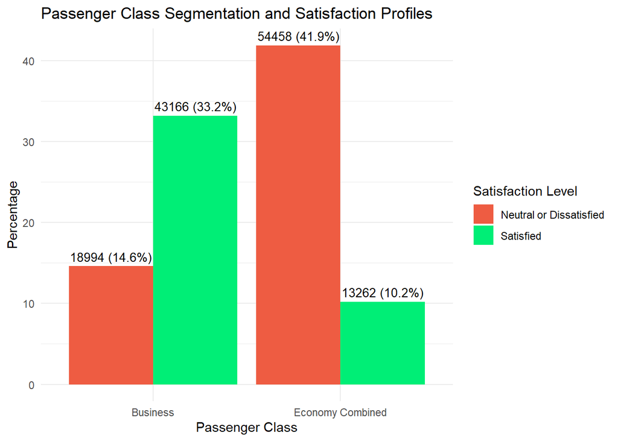

```r
# Summarize satisfaction levels for each class
class_satisfaction_summary <- data %>%
  mutate(Class = ifelse(Class %in% c("Economy", "Economy Plus"), "Economy Combined", Class)) %>%
  group_by(Class, Satisfaction) %>%
  summarize(Count = n(), .groups = "drop") %>%
  mutate(Percentage = round(Count / sum(Count) * 100, 1))

# Plot satisfaction profiles with labels showing number and percentage
ggplot(class_satisfaction_summary, aes(x = Class, y = Percentage, fill = Satisfaction)) +
  geom_bar(stat = "identity", position = "dodge") +
  geom_text(aes(label = paste0(Count, " (", Percentage, "%)")),
            position = position_dodge(width = 0.9),
            vjust = -0.5, size = 3.5) +  # Add labels above bars
  labs(
    title = "Passenger Class Segmentation and Satisfaction Profiles",
    x = "Passenger Class",
    y = "Percentage",
    fill = "Satisfaction Level"
  ) +
  theme_minimal() +
  scale_fill_manual(values = c("Neutral or Dissatisfied" = "tomato2", "Satisfied" = "springgreen2"))
```

```r
remove(class_satisfaction_summary)
```

**What are the aspects of service that are important towards customer satisfaction?**

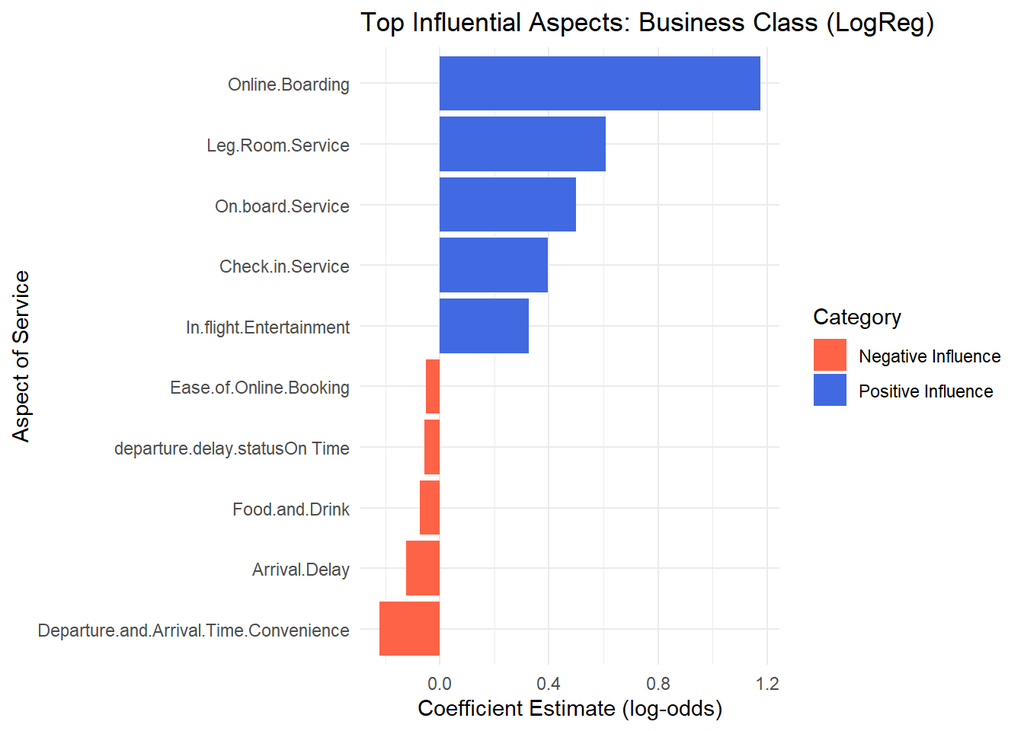

```r
# Extract coefficients from the logistic regression models
coefs_business <- summary(model_log_business)$coefficients
coefs_economy <- summary(model_log_economy)$coefficients

# Create data frames for plotting
coef_df_business <- data.frame(
  Variable = rownames(coefs_business),
  Estimate = coefs_business[, "Estimate"]
)
coef_df_economy <- data.frame(
  Variable = rownames(coefs_economy),
  Estimate = coefs_economy[, "Estimate"]
)

# Remove the intercept for clarity
coef_df_business <- coef_df_business[coef_df_business$Variable != "(Intercept)", ]
coef_df_economy <- coef_df_economy[coef_df_economy$Variable != "(Intercept)", ]

# Select the top 5 most liked and least liked predictors for each class
top_5_liked_business <- coef_df_business[order(-coef_df_business$Estimate), ][1:5, ]
top_5_disliked_business <- coef_df_business[order(coef_df_business$Estimate), ][1:5, ]
top_5_liked_economy <- coef_df_economy[order(-coef_df_economy$Estimate), ][1:5, ]
top_5_disliked_economy <- coef_df_economy[order(coef_df_economy$Estimate), ][1:5, ]

# Combine liked and disliked for plotting
top_5_business <- rbind(
  transform(top_5_liked_business, Category = "Positive Influence"),
  transform(top_5_disliked_business, Category = "Negative Influence")
)
top_5_economy <- rbind(
  transform(top_5_liked_economy, Category = "Positive Influence"),
  transform(top_5_disliked_economy, Category = "Negative Influence")
)

# Plot the top 5 most liked and least liked predictors for Business Class
ggplot(top_5_business, aes(x = reorder(Variable, Estimate), y = Estimate, fill = Category)) +
  geom_bar(stat = "identity") +
  coord_flip() +
  labs(title = "Top Influential Aspects: Business Class (LogReg)",
       x = "Aspect of Service",
       y = "Coefficient Estimate (log-odds)") +
  scale_fill_manual(values = c("Positive Influence" = "royalblue", "Negative Influence" = "tomato")) +
  theme_minimal()
```

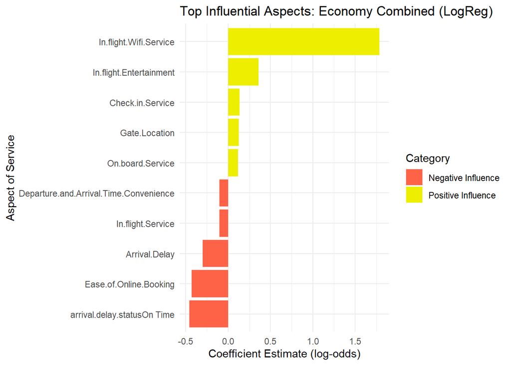

```r
# Plot the top 5 most liked and least liked predictors for Economy Combined
ggplot(top_5_economy, aes(x = reorder(Variable, Estimate), y = Estimate, fill = Category)) +
  geom_bar(stat = "identity") +
  coord_flip() +
  labs(title = "Top Influential Aspects: Economy Combined (LogReg)",
       x = "Aspect of Service",
       y = "Coefficient Estimate (log-odds)") +
  scale_fill_manual(values = c("Positive Influence" = "yellow2", "Negative Influence" = "tomato")) +
  theme_minimal()
```

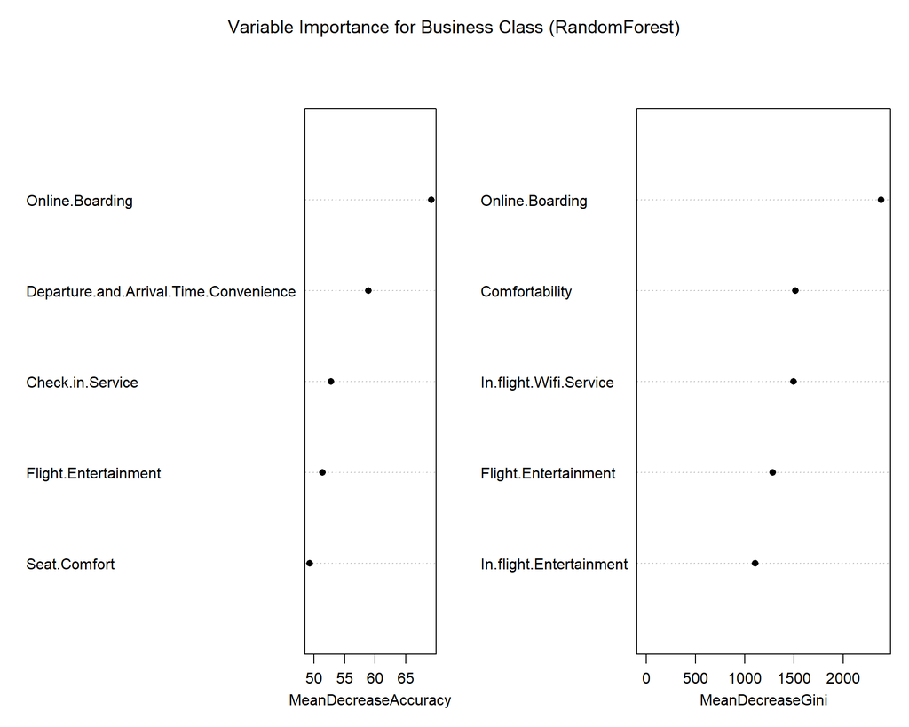

```r
# Plot the variable importance for business
varImpPlot(
  model.forest.business,
  main = "Variable Importance for Business Class (RandomForest)",
   pch = 16, # Use filled circles for data points
n.var = 5
)
```

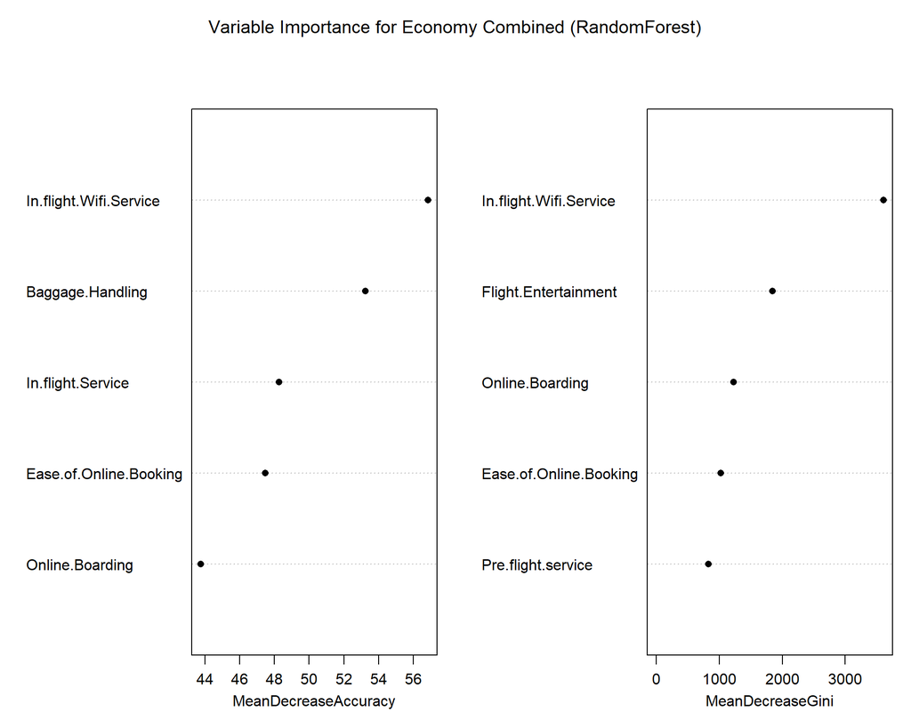

```r
varImpPlot(
  model.forest.economy,
  main = "Variable Importance for Economy Combined (RandomForest)",
   pch = 16, # Use filled circles for data points
n.var = 5
)
```

The chunks above show the important variables of satisfaction according to Logistic Regression as well as Random Forest classification. Below we will compare the results of both models, and assess the important parameters identified based on consensus.

**FINAL REMARKS: MODEL COMPARISON**  
**Model performance comparison**

| Model | Accuracy |
| --- | --- |
| Random Forest | 96% |
| Logistic Regression | 85% |

Based on the comparison, random forest model approach showing higher model accuracy. However, as explained in the model evaluation section for each model, each model showing high performance in terms of accuracy and not overfitting.  
The logistic regression model is more interpretable and easier to understand.The logistic regression model also provides a clear understanding of the relationship between the predictors and the target variable. This is important for understanding the factors that influence customer satisfaction and for making data-driven decisions to improve service quality.

Next we will evaluate the model predictor to define what top parameters that influence the customer satisfaction. From Random Forest, we will use variable importance to define variable significant level in driving satisfaction while in log regression we will use coefficient variable to define the significant level. The table below shows the top parameters that influence customer satisfaction in each class.

**Notes: RF: Random Forest, LR: Logistic Regression**

1: significant influencer, 0: not significant influencer

```r
# Create the data frame
df <- data.frame(
  Parameters = c(
    "Online Boarding", "Departure and Arrival Time Convenience", "Checkin Service",
    "Flight Entertainment", "Seat Comfort", "In Flight Wifi Service", "Cleanliness",
    "Baggage Handling", "Ease of Online Booking", "In Flight Service",
    "Leg room service", "On board service", "Gate Location"
  ),
  BUSINESS_RF = c(1,1,1,1,1,0,0,0,0,0,0,0,0),
  BUSINESS_LR = c(1,0,1,1,0,0,0,0,0,0,1,1,0),
  ECONOMY_RF = c(1,0,0,0,0,1,0,1,1,1,0,0,0),
  ECONOMY_LR = c(0,0,1,1,0,1,0,0,0,0,0,1,1)
)

# Helper function to color cells
cell_color <- function(x) {
  ifelse(x == 1,
         cell_spec(x, background = "#f4cccc"),  # Soft red
         cell_spec(x, background = "#fff2cc"))  # Soft yellow
}

# Apply coloring to each column except the Parameters
df_colored <- df
df_colored[,-1] <- lapply(df[,-1], cell_color)

# Create the styled table
kbl(df_colored, escape = FALSE,
    col.names = c("Parameters", "Business RF", " Business LR", "Economy RF", " Economy LR"),
    align = "lcccc") %>%
  kable_styling(full_width = FALSE, bootstrap_options = c("striped", "hover")) %>%
  row_spec(0, background = "#ADD8E6")  # Soft blue header
```

| Parameters | Business RF | Business LR | Economy RF | Economy LR |
| --- | --- | --- | --- | --- |
| Online Boarding | 1 | 1 | 1 | 0 |
| Departure and Arrival Time Convenience | 1 | 0 | 0 | 0 |
| Checkin Service | 1 | 1 | 0 | 1 |
| Flight Entertainment | 1 | 1 | 0 | 1 |
| Seat Comfort | 1 | 0 | 0 | 0 |
| In Flight Wifi Service | 0 | 0 | 1 | 1 |
| Cleanliness | 0 | 0 | 0 | 0 |
| Baggage Handling | 0 | 0 | 1 | 0 |
| Ease of Online Booking | 0 | 0 | 1 | 0 |
| In Flight Service | 0 | 0 | 1 | 0 |
| Leg room service | 0 | 1 | 0 | 0 |
| On board service | 0 | 1 | 0 | 1 |
| Gate Location | 0 | 0 | 0 | 1 |

TOP 5 is defined through the method as below:

1. If the parameter shows consensus from both model (Random Forest and Logistic Regression) showing significant then it is considered as top 5 parameter
2. If no significant consensus (significant on one model but not other), further analysis is performed by looking at the significant comparison compared to other parameters in the model. The higher level significant the parameter in the model, the more likely it is to be considered as top 5 parameter

Based on the result analysis, top 5 parameters that influence customer satisfaction in both classes are:

| No | Business Top Parameters | Economy Top Parameters |
| --- | --- | --- |
| 1 | Online Boarding | In Flight Wifi Service |
| 2 | Departure and Arrival Time Convenience | Flight Entertainment |
| 3 | Checkin Service | Baggage Handling |
| 4 | Flight Entertainment | Ease of Online Booking |
| 5 | Leg room service | In Flight Service |

## 4.2 Recommendation

We have developed models to predict customer satisfaction based on various service aspects. Understanding satisfaction contributors is important because customers satisfaction mediates the impact of service quality on corporate braning and perceived value on brand loyalti (Hussain, 2016). The analysis revealed that the most significant predictors of satisfaction differ between Business and Economy class passengers. As we can see, the airline industry segmentation between business and economy class is quite strong, and the two classes have different preferences. Therefore, improving the satisfaction rate in business and economy segment requires different approaches.

**ECONOMY SEGMENT**

Economy passengers shows high dissatisfaction level compared to business passengers at around 41.9% of total passengers. As we can see from the model, the most significant predictors of satisfaction for economy passengers are:

1. **In flight wifi service** : This shows the largest coefficient in the model indicating that satisfaction on this factor significantly contributes to overall customers’ satisfaction. Enhancing WiFi services should be a top priority. Invest in high-speed, reliable internet and offer free or affordable connectivity options to economy-class passengers.
2. **Flight entertainment**: Entertainment during flight matters for economy passengers. Increase option for entertainment by offering diverse movie, TV show, podcast, and music library. Therefore, ensuring personal screen for passengers and refresh the entertainment content regularly becomes important to drive the satisfaction
3. **Baggage Handling**: Minimize mishandling and delays through real-time tracking systems and better-trained staff. Provide notifications and support channels for passengers in case of issues. Economy pasengers often experience baggage handling problem thus this parameter becomes key factor to drive their satisfaction. Improvement on this, could helpt to raise the satisfaction
4. **Ease of Online Booking**: Simplify the booking interface with clear instructions, multiple payment methods, and personalized recommendations based on previous searches or preferences. Seamless experience in online booking is expected from the economy passengers, and it drives their satisfaction level
5. **In Flight service**: Deliver a better cabin experience by improving meal options, training crew for attentive service, and ensuring cleanliness. Consider complimentary beverages to add a touch of hospitality. Managing high performance in in-flight service could retain the loyalty of economy passengers

As we have identified through the model, concerning pain points are identified. Improving the top negative influence factors may not directly boost passenger satisfaction, but deeper analysis and mitigation strategies are essential. These efforts include aligning flight schedules with passenger preferences to improve time convenience, enhancing in-flight service by addressing specific dissatisfaction areas through surveys, and providing real-time updates with small compensations for delays. Additionally, understanding and refining features in online booking can address overlooked pain points, and adding acknowledgments for punctual flights (e.g., bonus miles) may balance unmet expectations. Together, these targeted efforts could address dissatisfaction effectively.

**BUSINESS SEGMENT**

Business passengers shows higher satisfaction level compared to economy passenger. More passengers in business class are satisfied compared to those who are not satisfied. However, we need to take a look on satisfaction contributors to increse the satisfaction level. As we can see from the model, the most significant predictors of satisfaction for business passengers are:

1. **Online Boarding**: For business segment, simplify the booking process by improving website navigation and offering transparent pricing. Ensure mobile compatibility for seamless access. Allow more features on online boarding for example additional service that customers expect such as pick up, business loounge information.
2. **Leg room service**: Ensure ample legroom and ergonomic seating. Highlight this feature in marketing campaigns to attract business travelers. For business segment, this is one of their intention to choose the service, spacious room for their seating.
3. **Departure and Arrival Time Convenience**: Conduct market research to identify preferred travel times and align flight schedules accordingly. Provide flexible options for rescheduling flights to accommodate traveler needs. This parameter becomes important for business passengers since they expect high comfortability come to and go from airport, arrival and departure time becomes matter
4. **Check in service**: Streamline check-in processes with dedicated counters or priority lanes for business-class passengers. Offer concierge services for added convenience. This is also the reason people choosing business service, putting attention to ensure seamless experience in check in service becomes matters.
5. **In flight entertainment**: Provide high-quality entertainment options, including noise-canceling headphones and curated content for business travelers. Airline could include games, various option of entertainment on screen, and make sure it is up to date.

As we have identified through the model, concerning pain points are identified. Negative influence factors, while correlating with reduced satisfaction, require in-depth analysis to address underlying issues. Enhancing usability in online booking platforms and ensuring transparency in pricing could alleviate dissatisfaction. Operational improvements to reduce delays, coupled with compensatory perks, may soften the impact of unavoidable disruptions. Customizing food and drink options to cater to diverse needs and optimizing flight schedules for convenience and punctuality are further steps that could help mitigate negative perceptions effectively. These strategies aim to refine passenger experiences and address dissatisfaction at its roots.

Addressing potential aspects that contribute to negative correlation from those factors could help to transform this to positive correlation.

**SUMMARY**

Airline prioritize top contributor to satisfaction level of passengers.Improvement on this areas will bring positive impact on satisfaction level. In addition to this, airline should address challenges on top negative influence on satisfaction level. Identifying potential aspects that bring the negative impact on those factors. It help to increase the satisfaction level

- For **Economy Segment**, Put in flight wifi service as top priority in business improvement, while progressing improvement on other four top factors such as flight entertainment, baggage handling, ease of online booking, and in flight service. Focus to address potential aspect that could reduce satisfaction in pain points
- For **Business Segment**, Put online boarding as top priority in business improvement, while managing improvement on other top factors such as leg room service, Departure and Arrival Time Convenience, check in service, and flight entertainment.Focus to address potential aspect that could reduce satisfaction in pain points.

## 4.3 Further Improvement for Better Recommendation

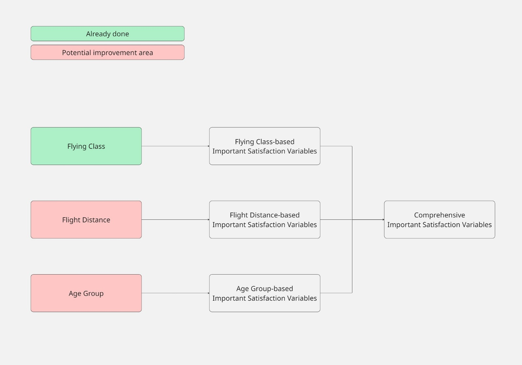

```r
file_path <- "Further_Recommendation.jpg"
knitr::include_graphics(file_path)
```

Although the current prediction model and approach has shown a robust result that can be used by airlines to improve their service, the predictor model can still be improved further. The current model is based on the separation between Economy and Business class passengers, which means that the model is only considering one dimension when predicting the most important variables that affect the passengers’ satisfaction level. However, based on the survey data, there are still other dimensions that can be used to predict the customer satisfaction based on the survey variables.

Among possible improvement area can be done by creating predictor model based on the combination of several dimensions that are easier to identify by the airlines, such as flight distance, which can be classified as short-haul, medium-haul, and long-haul flights, and age groups (children, youth, adult, and senior). Unlike variables like type of travel or customer type, flight distance and age groups can be quickly identified or classified by airlines without further questioning each passengers. Also, these two variables can be considered important for business decision making, such as in determining the flight route and the target market for each flight.

1. **Flight Distance**:
   - Passengers flying in long-haul flights may have different expectations and experiences compared to those on short-haul flights, even though both type of flights can be served in both economy and business class. By segmenting the data based on flight distance, we can identify specific service aspects that are crucial for each group. Using this approach, airlines with long haul flights, such as Amsterdam to Jakarta, can capture a more detailed insights regarding the passengers’ satisfaction point preference, which can be different from a shorter duration flight such as Amsterdam to London.
2. **Age Group**:
   - Different age groups may have varying preferences and expectations when it comes to airline services. By segmenting the data based on age, we can identify specific service aspects that are crucial for each group. For example, younger passengers may prioritize in-flight entertainment and WiFi connectivity, while older passengers may value comfort and service quality more. By understanding these differences, airlines can tailor their services to meet the needs of each age group. This is especially important for routes with popular tourist destination like the flight to Barcelona where the portion of younger passengers is likely to be higher (due to family holiday) than the flight without top tourist destinations. The airlines also can adjust the service priority during the holiday seasons to cover the increase in holiday-oriented passengers.

The result of different set of most important variables based on flying class, flight distance, and age group can be used to create a more comprehensive recommendation for the airlines. This will help the airlines to improve their service quality and increase customer satisfaction by providing more data to support the decision-making process of airlines.

## 4.4 Conclusion & Limitations

**Conclusion**

In part 1, Project Background part, we highlights the business problem of identifying how airlines can improve their strategy of services and activities to increase customer satisfaction, especially between segments and main service areas, to achieve stronger competitive advantages. To address this issue, we analyze data from over 129,880 airline passengers’ responses that evaluate the airline-related service they received. Given that the dataset does not provide information on the specific airline or ticket pricing, we will analyze the service-related factors that universally impact passenger satisfaction.

In Part 2, Data Exploration and Preparation part, we involved analyzing findings and insight to understand the data better. The process included exploratory data analysis (EDA), data cleaning, data transformation, and feature engineering. Crucial processes have already been done in this part, ranging from handling outlier and missing values, conducting univariate data analysis and the association between numerical and categorical variable analysis, transforming skew variables, and creating meaningful feature groups. Through this process, we ensure our dataset already has the proper treatment to proceed to the modeling part.

In part 4, Interpretation part, we summarize the insight into the result visualization part to later become the basis of our actionable recommendation based on the top 5 most important factors that influence the satisfaction level. The analysis revealed that the most significant predictors of satisfaction differ between Business and Economy class passengers. The most important factors for business passengers are Online Boarding, Leg Room Service, Departure and Arrival Time Convenience, Check-in Service, and In-flight Entertainment. For Economy passengers, the most important factors are In-flight WiFi Service, Flight Entertainment, Baggage Handling, Ease of Online Booking, and In-flight Service. Furthermore, we also identify several areas for improvement based on our current prediction model.

In conclusion, this analysis provides valuable insights for airline service providers seeking to improve their strategy in order to increase overall customer satisfaction, especially in the business and economy class segments. The actionable recommendation can be executed by focusing on parallel improvement in both classes. By prioritizing core service components and operational reliability, airlines can improve satisfaction levels and build stronger customer loyalty in a highly competitive market.

**Limitation**

## 4.5 References

Agresti, A. (2018). Statistical thinking: Improving business performance (2nd ed.). Boca Raton, FL: CRC Press.

Biau, G. (2010). Analysis of a Random Forests Model. J. Mach. Learn. Res., 13, 1063-1095. https://doi.org/10.5555/2503308.2343682

Federal Aviation Administration. (n.d.). Types of Delay. Retrieved April 15, 2025, from https://aspm.faa.gov/aspmhelp/index/Types_of_Delay.html

Hosmer, D. W., Lemeshow, S., & Sturdivant, R. X. (2013). Applied logistic regression (3rd ed.). Wiley.

Hussain, R. (2016). The mediating role of customer satisfaction: evidence from the airline industry. Asia Pacific Journal of Marketing and Logistics, 28, 234-255. https://doi.org/10.1108/APJML-01-2015-0001.

International Air Transport Association. (2024, December). Global outlook for air transport: December 2024. IATA. Retrieved April 3, 2025, from https://www.iata.org/en/iata-repository/publications/economic-reports/global-outlook-for-air-transport-december-2024/

Landwehr, N., Hall, M., & Frank, E. (2003). Logistic Model Trees. Machine Learning, 59, 161-205. https://doi.org/10.1007/s10994-005-0466-3.

Schwenk, H., & Bengio, Y. (2000). Boosting Neural Networks. Neural Computation, 12, 1869-1887. https://doi.org/10.1162/089976600300015178.

Statista. (n.d.). Flights - Shared Mobility. Retrieved April 3, 2025, from https://www.statista.com/outlook/mmo/shared-mobility/flights/worldwide.

Wragg, David W. (1973). A Dictionary of Aviation. Reading, UK: Osprey Publishing.

Wright, M., & Ziegler, A. (2015). ranger: A Fast Implementation of Random Forests for High Dimensional Data in C++ and R. Journal of Statistical Software, 077, 1-17. https://doi.org/10.18637/jss.v077.i01.

Yan, K., & Hong, J. (2022). Adaptive cost-sensitive learning: Improving the convergence of intelligent diagnosis models under imbalanced data. Knowl. Based Syst., 241, 108296. https://doi.org/10.1016/j.knosys.2022.108296.